# DADA2: Illumina Full Run

Eva Kim

9/19/2023

# Project Abstract

Obesity increases asthma severity and diminishes responsiveness to asthma medications. Patients with obesity exhibit increased leptin and decreased glucagon-like peptide 1 (GLP-1) secretion. Bariatric surgery is an effective therapy for obesity that induces elevated circulating GLP-1 levels and improves asthma symptoms. Both gut and lung microbiomes exhibit dysbiosis in patients with asthma and obesity compared to lean, healthy patients. GLP-1 receptor (GLP1R) activation alters the gut microbiota of mice. Our data suggest that Glpr1 deficiency impacts airway resistance in a mouse model of allergic airways disease. **Our hypothesis is that increased GLP-1 secretion following bariatric surgery alters the gut and airway/lung microbiomes and that these alterations reduce airway inflammation and improve asthma control and lung function in patients with obesity.** We propose two Aims. In Aim 1, we will analyze microbial communities in bronchoalveolar lavage (BAL) fluid prior to and 12 months following bariatric surgery in patients with asthma and obesity. We will correlate these findings with leptin and GLP-1 levels in blood and BAL fluid and to clinical measures of lung function and asthma control. In Aim 2, diet-induced obese Glp1r-/- and Glp1r+/+ mice will be intranasally challenged with house dust mite allergen and undergo vertical sleeve gastrectomy. We will assess microbiota species in lung tissue and feces and relate these findings to GLP-1 and leptin levels in plasma and BAL fluid, lung mechanics and tissue pathology. In both aims, we will relate microbiome changes to lung function and inflammatory responses to predict asthma outcomes in patients with obesity.

This data pertains to Aim 2 of the project. As the lung tissue samples had low bacterial biomass and high host DNA contamination, 9 lung tissue samples were submitted first to test the applicability of the protocol (6 samples and 3 blanks; sequencing run 1). The rest of the lung tissue samples were sequenced on a different run along with all fecal samples (sequencing run 2). This R markdown file is for sequencing run #2 containing both fecal and lung tissue samples. Throughout code and comments, I use LT for lung tissue.

Please note that to use `ancom` function for identifying differentially abundamnt taxa, the package `ANCOMBC` has to be updated with the latest version of R.

## Methods for Data Generation

### Lung Tissue

DNA from whole lung tissue was extracted using with Qiagen Blood & Tissue kit as described in [*Baker et al., 2021*](https://microbiomejournal.biomedcentral.com/articles/10.1186/s40168-021-01055-4). DNA was quantified using Qubit 2.0 floufluorometer (ThermoFisher) and submitted to Duke Microbiome Center for library preparation using standard [Earth Microbiome Protocol](http://www.earthmicrobiome.org/) for 16S rRNA v4 region. For each sample, triplicate PCR reactions were performed, which were then merged for magnetic bead clean-up of prepared libraries. Equal mass of 16S rRNA PCR products was pooled from all samples for sequencing. The final pool was submitted to Duke Sequencing and Genomic Technology (SGT) core for sequencing.

### Fecal Samples

Fecal samples were extracted with DNeasy PowerSoil Pro kits (QIAGEN). The extracted DNA was prepared for sequencing with v4 region primers (515F, 5’-GTGYCAGCMGCCGCGGTAA-3’ and 806rB, 5’-GGACTACNVGGGTWTCTAAT-3’; same as above) with dual-indexed barcodes following Illumina’s [16S metagenomic sequencing guidelines](https://support.illumina.com/documents/documentation/chemistry_documentation/16s/16s-metagenomic-library-prep-guide-15044223-b.pdf).The PCR used KAPA HiFi PCR kit (Roche). The concentrations following PCR were determined using a Qubit fluorometer (ThermoFisher), and equal mass if PCR products was pooled from all samples. The final fecal pool was submitted to the Duke SGT for sequencing.

### Info for data analysis

For the lung tissue samples, the barcode and primer sequences have been removed. However, for fecal samples both will have to be removed. For both, the region between 515F and 806R primers is about 254 bp.

### Database

I’m using Silva version 138 with training data formatted for DADA2 from https://zenodo.org/record/3731176#.ZElLBnbMKUl.

### Codes

Please note that many of the coding lines below are from Dr. Callahan’s [DADA2 tutorial](https://benjjneb.github.io/dada2/tutorial.html).

# Load libraries

```r
library(dada2)
library(readr)
library(stringr)
library(dplyr)
library(tibble)
library(magrittr)
library(phyloseq)
library(ggplot2)
library(fs)
library(tidyr)
library(ShortRead)
library(Biostrings)
library(tidyverse)
library(vegan)
library(decontam)
library(pals)
library(tools)
library(seqTools)
library(DT)
```

# Directories

Note that the two different samples have different barcode schemes, and as such they were provided in two different folders. As the md5sum files are contained within each file, let’s leave them separately for now.

```r
rm(list=ls()) # clear environment

sto.dir = file.path("~/storage/data/") # Path to storage directory
data.dir.LT = path.expand(file.path("~/storage/GLP_KO_Mice/Hu_8493_23072803")) #CHANGE ME to where files are stored
data.dir.fecal = path.expand(file.path("~/storage/GLP_KO_Mice/Hu2_8493_23072803")) #CHANGE ME to where files are stored
scratch.dir = path.expand(file.path(sto.dir, paste0("scratch")))
output.dir = path.expand(file.path(sto.dir, paste0("output")))
git.dir = file.path("~/GLP_KO_Microbiome/")
if (dir_exists(scratch.dir)) {
  dir_delete(scratch.dir)
}
dir_create(scratch.dir)
if (dir_exists(output.dir)) {
  dir_delete(output.dir)
}
dir_create(output.dir)
filt.dir = path.expand(file.path(scratch.dir,paste0("filt")))
cut.dir = path.expand(file.path(scratch.dir,paste0("cut"))) # Fecal files need cutadapt
filtN.dir = path.expand(file.path(scratch.dir,paste0("filtN"))) # For removing N's before cutadapt

md5sum.LT = file.path(data.dir.LT, paste0("Hu_8493_23072803.checksum"))
md5sum.fecal = file.path(data.dir.fecal, paste0("Hu2_8493_23072803.checksum"))


map.file = file.path(git.dir, "GLP_KO_LT_MasterSheet_Import.csv")
LT.df = read_csv(map.file)
map2.file = file.path(git.dir, "GLO_KO_Microbiome_Fecal_ext.csv")
Fecal.df = read_csv(map2.file)
map3.file = file.path(git.dir, "GLO_KO_Microbiome_Metadata_overall.csv")
meta.df = read_csv(map3.file)

Sys.setenv(OUT_DIR = output.dir)
Sys.setenv(STO_DIR = sto.dir)
Sys.setenv(SCRATCH_DIR = scratch.dir)
Sys.setenv(DATA_DIR_LT = data.dir.LT)
Sys.setenv(DATA_DIR_fecal = data.dir.fecal)
Sys.setenv(MAP_FILE = map.file)
Sys.setenv(FILT_DIR = filt.dir)
Sys.setenv(CUT_DIR = cut.dir)
Sys.setenv(FILTN_DIR = filtN.dir)

# Ref database

silva_v138.ref = "/hpc/home/yk132/storage/silva_ref/silva_v138/silva_nr99_v138.1_train_set.fa.gz"
silva_v138.species.ref = "/hpc/home/yk132/storage/silva_ref/silva_v138/silva_species_assignment_v138.1.fa.gz"
```

# Data Provenance

First, it is important to check the md5sums to ensure that the data was downloaded and stored correctly.

```r
md5sum.LT %>%
   read_delim(delim="   ", col_names = c("filename", "true_md5sum"), show_col_types = FALSE) -> true_md5sums

data.dir.LT %>%
  list.files(full.names = TRUE ) %>%
  md5sum() %>%
  enframe(name="filepath", value="observed_md5sum")   %>%
  mutate(filename=basename(filepath)) ->observed_md5sums

true_md5sums %>% filter(filename %in% observed_md5sums$filename) %>%    # Since my reads are only a subset of full run, need to subset md5sums
  full_join(observed_md5sums, by = "filename") %>%
  mutate(md5sum_match = observed_md5sum == true_md5sum) %>%
  filter(!str_detect(filename, "checksum|README")) -> compare_md5sums  # Path also contains README and checksum filesl; remove these

all(compare_md5sums$md5sum_match)
```

```
## [1] TRUE
```

```r
md5sum.fecal %>%
   read_delim(delim="   ", col_names = c("filename", "true_md5sum"), show_col_types = FALSE) -> true_md5sums

data.dir.fecal %>%
  list.files(full.names = TRUE ) %>%
  md5sum() %>%
  enframe(name="filepath", value="observed_md5sum")   %>%
  mutate(filename=basename(filepath)) ->observed_md5sums

true_md5sums %>% filter(filename %in% observed_md5sums$filename) %>%    # Since my reads are only a subset of full run, need to subset md5sums
  full_join(observed_md5sums, by = "filename") %>%
  mutate(md5sum_match = observed_md5sum == true_md5sum) %>%
  filter(!str_detect(filename, "checksum|README")) -> compare_md5sums  # Path also contains README and checksum files; remove these

all(compare_md5sums$md5sum_match)
```

```
## [1] TRUE
```

All files have the correct md5sums.

# Metadata

Each metadata file contains slightly different, and possibly redundant, information, so let’s clean them up.

```r
LT.df  %>% dplyr::rename(Intrasal_Treatment = Intranasal) -> LT.df

Fecal.df %>%
  mutate(Type = str_replace(Sample_or_Control, "True Sample", "True Sample"),
                    Type = str_replace(Sample_or_Control, "Control Sample", "Neg Control"),) %>%
  dplyr::rename(Feces_weight = Weight_mg) %>%
  select(-c("quant_reading", "Sample_or_Control")) -> Fecal.df
Fecal.df$Sequencing_Run <- 2

meta.df %>% mutate(Sex = str_replace(Sex, "M", "Male"), Sex = str_replace(Sex, "F", "Female")) %>% select(Label:Cage) %>% right_join(LT.df, by = c("Label", "Genotype", "Sex", "Diet", "Intrasal_Treatment", "Surgery")) -> LT_Full.df

LT_Full.df$Sample_type <- "Lung Tissue"

meta.df %>% mutate(Sex = str_replace(Sex, "M", "Male"), Sex = str_replace(Sex, "F", "Female")) %>% select(Label:Cage) %>% dplyr::rename(Mouse = Label) %>% right_join(Fecal.df, by = "Mouse") %>% dplyr::rename(Sample_Label = Label, Label = Fecal_index) -> Fecal_Full.df
Fecal_Full.df$Sample_type <- "Fecal"

Fecal_Full.df$Label <- as.character(Fecal_Full.df$Label)

bind_rows(LT_Full.df, Fecal_Full.df) -> FullMeta.df
```

```r
FullMeta.df %>% head()
```

```
## # A tibble: 6 × 23
##   Label  `Cage-Mouse`      Genotype Sex    Diet       Intrasal_Treatment Surgery
##   <chr>  <chr>             <chr>    <chr>  <chr>      <chr>              <chr>
## 1 JI-661 1477831/1420961-2 WT       Female High_Fat_… PBS                VSG
## 2 JI-662 1420955-1         WT       Male   High_Fat_… PBS                Sham
## 3 JI-665 1477806/1420956-3 WT       Female High_Fat_… HDM                Sham
## 4 JI-668 1477834/1420957-1 KO       Male   High_Fat_… HDM                Sham
## 5 JI-669 1477824/1420956-4 WT       Female High_Fat_… PBS                Sham
## 6 JI-670 1477830/1420961-3 WT       Female High_Fat_… HDM                Sham
## # ℹ 16 more variables: Intrasal_Dose <chr>, Cohort <dbl>, Cage <dbl>,
## #   Week <dbl>, Lung_index <dbl>, Kit <chr>, Mouse <chr>, DNA_ng_ul_raw <dbl>,
## #   Sequencing_Run <dbl>, Type <chr>, Sample_type <chr>, Sample_Label <chr>,
## #   Cage_Notation <chr>, Feces_weight <dbl>, Orig_label <chr>, Notes <chr>
```

```r
dim(LT_Full.df)
```

```
## [1] 65 18
```

```r
dim(Fecal_Full.df)
```

```
## [1] 200  22
```

```r
dim(FullMeta.df)
```

```
## [1] 265  23
```

Note that the “Label” column matches the .fastq sample names. Let’s save the final metadata as a .csv file:

```r
# write_csv(FullMeta.df, file.path(git.dir, "GLP_KO_Metadata_Full.csv")) # Commented out after first run
```

We only need the metadata for the samples in Sequencing Run #2.

```r
FullMeta.df %>% filter(Sequencing_Run == "2") -> FullMeta.df
```

# Remove Primers for the Fecal Samples

Since I did not use heterogeneous spacers, I will use the `FilterAndTrim` function in DADA2 to remove primers. Please note that lung tissue samples do not require primer / barcode removal.

```r
fnFs_F_Fecal <- sort(list.files(data.dir.fecal, pattern="_R1_001.fastq.gz", full.names = TRUE)) # fecal samples only!
fnRs_R_Fecal <- sort(list.files(data.dir.fecal, pattern="_R2_001.fastq.gz", full.names = TRUE))

suffix2 = "/hpc/home/yk132/storage/GLP_KO_Mice/Hu2_8493_23072803/"
end = "_S.*_L001_R1_001.fastq.gz"
end2 = "_R1_001.fastq.gz"
fnFs_F_Fecal %>%
  basename %>%
  str_replace(suffix2, "") %>%
  str_replace(end, "")%>%
  str_replace(end2, "") -> sample.names.fecal
print(sample.names.fecal)
```

```
##   [1] "1"              "10"             "11"             "12"
##   [5] "13"             "14"             "15"             "16"
##   [9] "17"             "18"             "19"             "2"
##  [13] "20"             "201"            "202"            "203"
##  [17] "204"            "205"            "206"            "207"
##  [21] "208"            "209"            "21"             "210"
##  [25] "211"            "212"            "213"            "214"
##  [29] "215"            "216"            "217"            "218"
##  [33] "219"            "22"             "220"            "221"
##  [37] "222"            "223"            "224"            "225"
##  [41] "226"            "227"            "228"            "229"
##  [45] "23"             "230"            "231"            "232"
##  [49] "233"            "234"            "235"            "236"
##  [53] "237"            "238"            "239"            "24"
##  [57] "240"            "241"            "242"            "244"
```

[output cut: 43 more lines]

## Data Quality: Fecal Samples

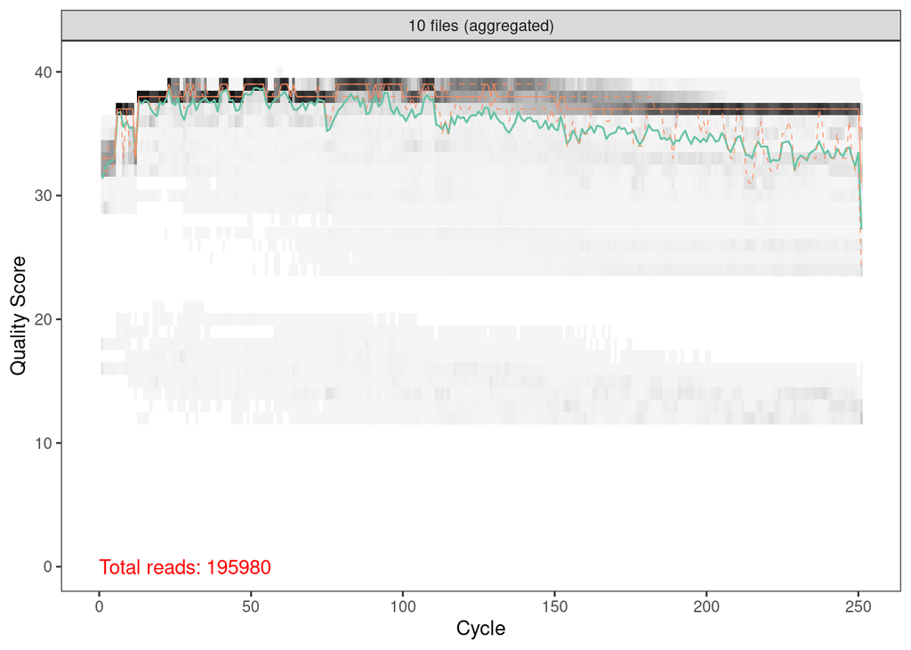

```r
plotQualityProfile(fnFs_F_Fecal[c(1:10)], aggregate = T) # 10 fecal samples
```

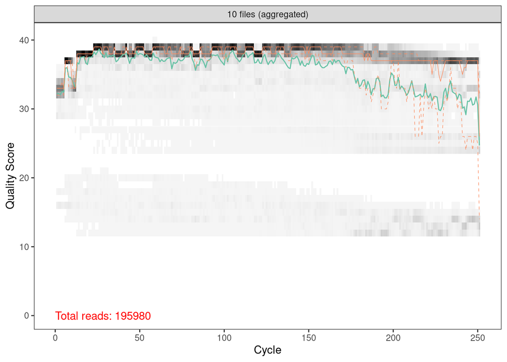

```r
plotQualityProfile(fnRs_R_Fecal[c(1:10)], aggregate = T)
```

Checking to see presence of primers:

```r
FWD <- "GTGYCAGCMGCCGCGGTAA"   # full primer seq TCGTCGGCAGCGTCAGATGTGTATAAGAGACAGGTGYCAGCMGCCGCGGTAA  515F
REV <- "GGACTACNVGGGTWTCTAAT"  # full primre seq GTCTCGTGGGCTCGGAGATGTGTATAAGAGACAGGGACTACNVGGGTWTCTAAT 806rB

allOrients <- function(primer) {
    # Create all orientations of the input sequence
    require(Biostrings)
    dna <- DNAString(primer)  # The Biostrings works w/ DNAString objects rather than character vectors
    orients <- c(Forward = dna, Complement = complement(dna), Reverse = reverse(dna),
        RevComp = reverseComplement(dna))
    return(sapply(orients, toString))  # Convert back to character vector
}
FWD.orients <- allOrients(FWD)
REV.orients <- allOrients(REV)
FWD.orients
```

```
##               Forward            Complement               Reverse
## "GTGYCAGCMGCCGCGGTAA" "CACRGTCGKCGGCGCCATT" "AATGGCGCCGMCGACYGTG"
##               RevComp
## "TTACCGCGGCKGCTGRCAC"
```

```r
primerHits <- function(primer, fn) {
    # Counts number of reads in which the primer is found
    nhits <- vcountPattern(primer, sread(readFastq(fn)), fixed = FALSE)
    return(sum(nhits > 0))
}

rbind(FWD.ForwardReads = sapply(FWD.orients, primerHits, fn = fnFs_F_Fecal[[1]]),
    FWD.ReverseReads = sapply(FWD.orients, primerHits, fn = fnRs_R_Fecal[[1]]),
    REV.ForwardReads = sapply(REV.orients, primerHits, fn = fnFs_F_Fecal[[1]]),
    REV.ReverseReads = sapply(REV.orients, primerHits, fn = fnRs_R_Fecal[[1]]))
```

```
##                  Forward Complement Reverse RevComp
## FWD.ForwardReads   11536          0       0       0
## FWD.ReverseReads       0          0       0       0
## REV.ForwardReads       0          0       0       0
## REV.ReverseReads   11876          0       0       0
```

The forward primer sequence is 19 bp long, and the reverse primer sequence is 20 bp long.

```r
filtFs_Fecal <- file.path(filt.dir, "filtered", paste0(sample.names.fecal, "_F_filt.fastq.gz"))
filtRs_Fecal <- file.path(filt.dir, "filtered", paste0(sample.names.fecal, "_R_filt.fastq.gz"))
names(filtFs_Fecal) <- sample.names.fecal
names(filtRs_Fecal) <- sample.names.fecal
```

```r
filt.out_Fecal <- filterAndTrim(fnFs_F_Fecal, filtFs_Fecal, fnRs_R_Fecal, filtRs_Fecal,
                          trimLeft = 19, trimRight = 20, # remove primers
                          maxN=0, maxEE=c(2,2), truncQ=2, rm.phix=TRUE,
                          compress=TRUE, multithread=TRUE)
```

```
## Creating output directory: /hpc/home/yk132/storage/data//scratch/filt/filtered
```

```
## Some input samples had no reads pass the filter.
```

```r
filtFs.survived_Fecal <- sort(list.files(path.expand(file.path(filt.dir,paste0("filtered"))), pattern="_F_filt.fastq.gz", full.names = TRUE))
filtRs.survived_Fecal <- sort(list.files(path.expand(file.path(filt.dir,paste0("filtered"))), pattern="_R_filt.fastq.gz", full.names = TRUE))

suffix = "/hpc/home/yk132/storage/GLP_KO_Microbiome/scratch/filt/filtered"
end = "_F_filt.fastq.gz"
end2 = "_R_filt.fastq.gz"
filtFs.survived_Fecal %>%
  basename %>%
  str_replace(suffix, "") %>%
  str_replace(end, "")%>%
  str_replace(end2, "") -> sample.names.filter.fecal

sample.names.fecal[which(!sample.names.fecal %in% sample.names.filter.fecal)] # See which reads did not survive filter
```

```
## [1] "DW5-3"   "PCR-Bl3"
```

Only blanks did not survive the filter and trimming step.

Check that primers are removed:

```r
rbind(FWD.ForwardReads = sapply(FWD.orients, primerHits, fn = filtFs_Fecal[[1]]),
    FWD.ReverseReads = sapply(FWD.orients, primerHits, fn = filtRs_Fecal[[1]]),
    REV.ForwardReads = sapply(REV.orients, primerHits, fn = filtFs_Fecal[[1]]),
    REV.ReverseReads = sapply(REV.orients, primerHits, fn = filtRs_Fecal[[1]]))
```

```
##                  Forward Complement Reverse RevComp
## FWD.ForwardReads       0          0       0       0
## FWD.ReverseReads       0          0       0       0
## REV.ForwardReads       0          0       0       0
## REV.ReverseReads       0          0       0       0
```

And here is the data quality after trimming:

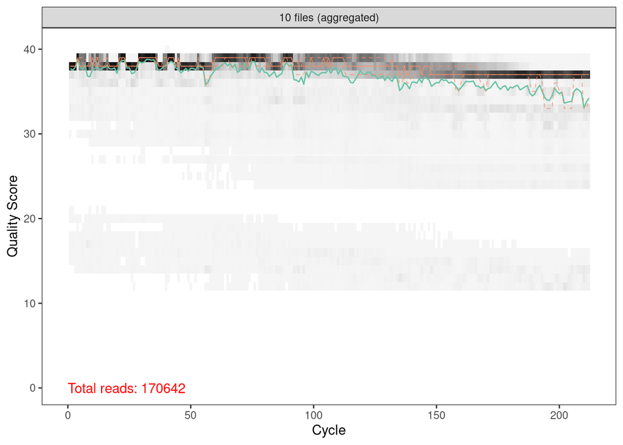

```r
plotQualityProfile(filtFs_Fecal[c(1:10)], aggregate = T) # 10 fecal samples
```

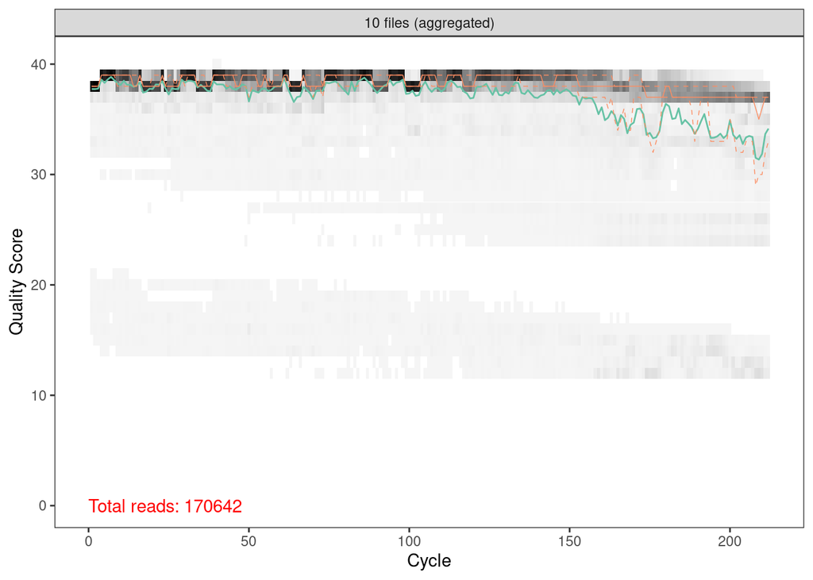

```r
plotQualityProfile(filtRs_Fecal[c(1:10)], aggregate = T)
```

# DADA2

The primers are already removed for the lung tissue samples, but it should still undergo the same filtering step (minus the trimming)

```r
fnFs <- sort(list.files(data.dir.LT, pattern="_R1_001.fastq.gz", full.names = TRUE)) # Lung Tissue only
fnRs <- sort(list.files(data.dir.LT, pattern="_R2_001.fastq.gz", full.names = TRUE))
```

## Data Quality: Lung Tissue Samples

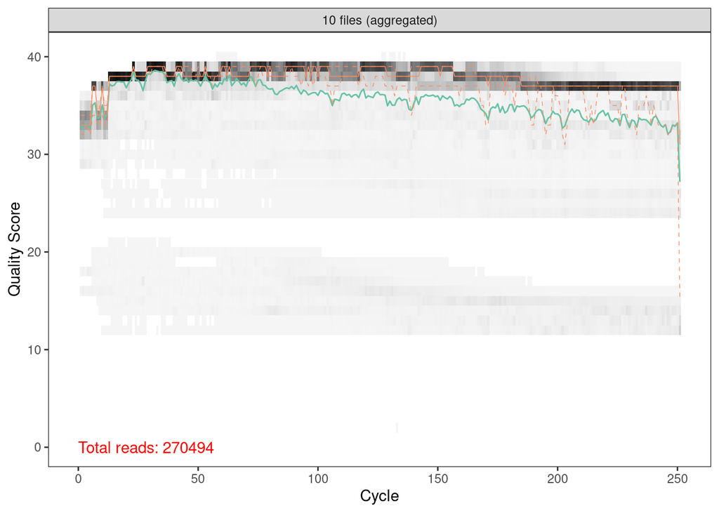

```r
plotQualityProfile(fnFs[c(1:10)], aggregate = T) # 10 LT samples
```

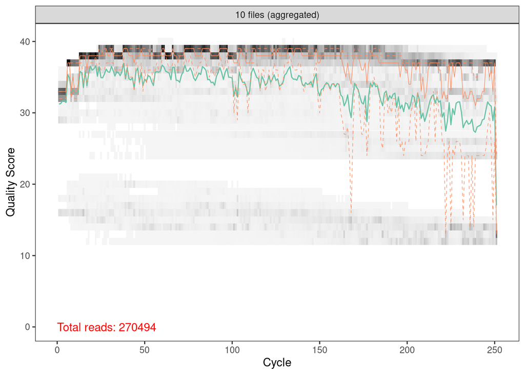

```r
plotQualityProfile(fnRs[c(1:10)], aggregate = T)
```

## Filter and Trim

```r
suffix2 = "/hpc/home/yk132/storage/GLP_KO_Mice/Hu_8493_23072803/" # CHANGE ME to directory
end = "_S.*_L001_R1_001.fastq.gz"
end2 = "_R1_001.fastq.gz"
fnFs %>%
  basename %>%
  str_replace(suffix2, "") %>%
  str_replace(end, "")%>%
  str_replace(end2, "") -> sample.names # This is for lung tissue samples only
print(sample.names)
```

```
##  [1] "Elution-blank-1" "Elution-blank-2" "Elution-blank-3" "JI-646"
##  [5] "JI-647"          "JI-648"          "JI-649"          "JI-651"
##  [9] "JI-652"          "JI-653"          "JI-654"          "JI-655"
## [13] "JI-656"          "JI-657"          "JI-658"          "JI-659"
## [17] "JI-660"          "JI-661"          "JI-662"          "JI-664"
## [21] "JI-665"          "JI-666"          "JI-667"          "JI-669"
## [25] "JI-671"          "JI-672"          "JI-674"          "JI-675"
## [29] "JI-677"          "JI-679"          "JI-680"          "JI-681"
## [33] "JI-682"          "JI-683"          "JI-684"          "JI-685"
## [37] "JI-686"          "JI-687"          "JI-688-Redo"     "JI-689"
## [41] "JI-690"          "JI-691"          "JI-692"          "JI-693"
## [45] "Kit-blank-1"     "Kit-blank-3"     "Kit-blank-4"     "pcr-neg"
## [49] "Saline-blank-1"  "Saline-blank-2"  "Saline-blank-4"  "zymo"
```

```r
filtFs <- file.path(filt.dir, "filtered", paste0(sample.names, "_F_filt.fastq.gz"))
filtRs <- file.path(filt.dir, "filtered", paste0(sample.names, "_R_filt.fastq.gz"))
names(filtFs) <- sample.names
names(filtRs) <- sample.names
```

```r
length(fnFs)
```

```
## [1] 52
```

```r
length(filtFs) # make sure the lengths match
```

```
## [1] 52
```

```r
filt.out <- filterAndTrim(fnFs, filtFs, fnRs, filtRs,maxN=0, maxEE=c(2, 2), truncQ=2, rm.phix=TRUE,
                          compress=TRUE, multithread=TRUE)  # Primer/barcode already removed so not setting truncation based on length
                                                            # Otherwise same with fecal samples
```

Let’s see if all reads survived the filtering and trimming step:

```r
filtFs.survived <- sort(list.files(path.expand(file.path(filt.dir,paste0("filtered"))), pattern="_F_filt.fastq.gz", full.names = TRUE))
filtRs.survived <- sort(list.files(path.expand(file.path(filt.dir,paste0("filtered"))), pattern="_R_filt.fastq.gz", full.names = TRUE))

suffix = "/hpc/home/yk132/storage/GLP_KO_Microbiome/scratch/filt/filtered"
end = "_F_filt.fastq.gz"
end2 = "_R_filt.fastq.gz"
filtFs.survived %>%
  basename %>%
  str_replace(suffix, "") %>%
  str_replace(end, "")%>%
  str_replace(end2, "") -> sample.names.filter

sample.names[which(!sample.names %in% sample.names.filter)] # See which reads did not survive filter
```

```
## character(0)
```

All lung tissue samples survived the filtering step.

## Error Correction

Let’s check that the list of files include both lung and fecal samples:

```r
filtFs.survived
```

```
##   [1] "/hpc/home/yk132/storage/data//scratch/filt/filtered/1_F_filt.fastq.gz"
##   [2] "/hpc/home/yk132/storage/data//scratch/filt/filtered/10_F_filt.fastq.gz"
##   [3] "/hpc/home/yk132/storage/data//scratch/filt/filtered/11_F_filt.fastq.gz"
##   [4] "/hpc/home/yk132/storage/data//scratch/filt/filtered/12_F_filt.fastq.gz"
##   [5] "/hpc/home/yk132/storage/data//scratch/filt/filtered/13_F_filt.fastq.gz"
##   [6] "/hpc/home/yk132/storage/data//scratch/filt/filtered/14_F_filt.fastq.gz"
##   [7] "/hpc/home/yk132/storage/data//scratch/filt/filtered/15_F_filt.fastq.gz"
##   [8] "/hpc/home/yk132/storage/data//scratch/filt/filtered/16_F_filt.fastq.gz"
##   [9] "/hpc/home/yk132/storage/data//scratch/filt/filtered/17_F_filt.fastq.gz"
##  [10] "/hpc/home/yk132/storage/data//scratch/filt/filtered/18_F_filt.fastq.gz"
##  [11] "/hpc/home/yk132/storage/data//scratch/filt/filtered/19_F_filt.fastq.gz"
##  [12] "/hpc/home/yk132/storage/data//scratch/filt/filtered/2_F_filt.fastq.gz"
##  [13] "/hpc/home/yk132/storage/data//scratch/filt/filtered/20_F_filt.fastq.gz"
##  [14] "/hpc/home/yk132/storage/data//scratch/filt/filtered/201_F_filt.fastq.gz"
##  [15] "/hpc/home/yk132/storage/data//scratch/filt/filtered/202_F_filt.fastq.gz"
```

[output cut: 266 more lines]

```r
errF <- learnErrors(filtFs.survived, multithread=TRUE)
```

```
## 100316492 total bases in 473191 reads from 28 samples will be used for learning the error rates.
```

```r
errR <- learnErrors(filtRs.survived, multithread=TRUE)
```

```
## 100316492 total bases in 473191 reads from 28 samples will be used for learning the error rates.
```

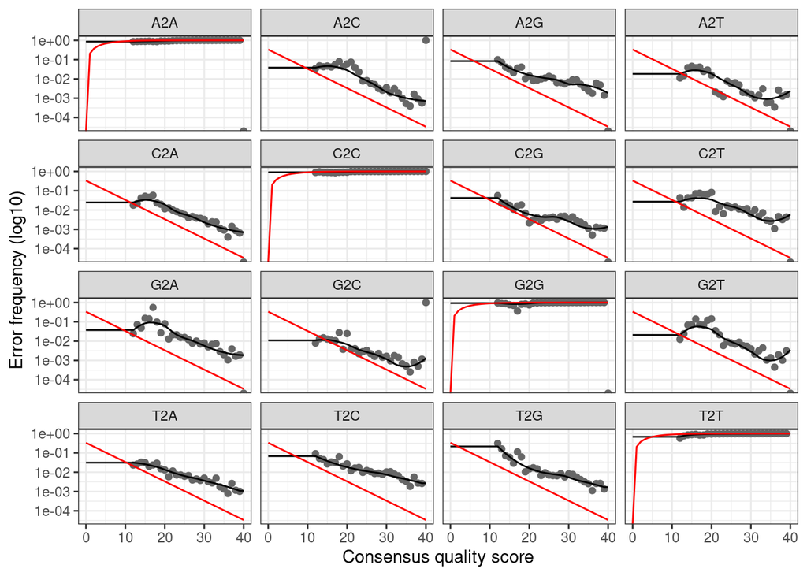

```r
plotErrors(errF, nominalQ=TRUE)
```

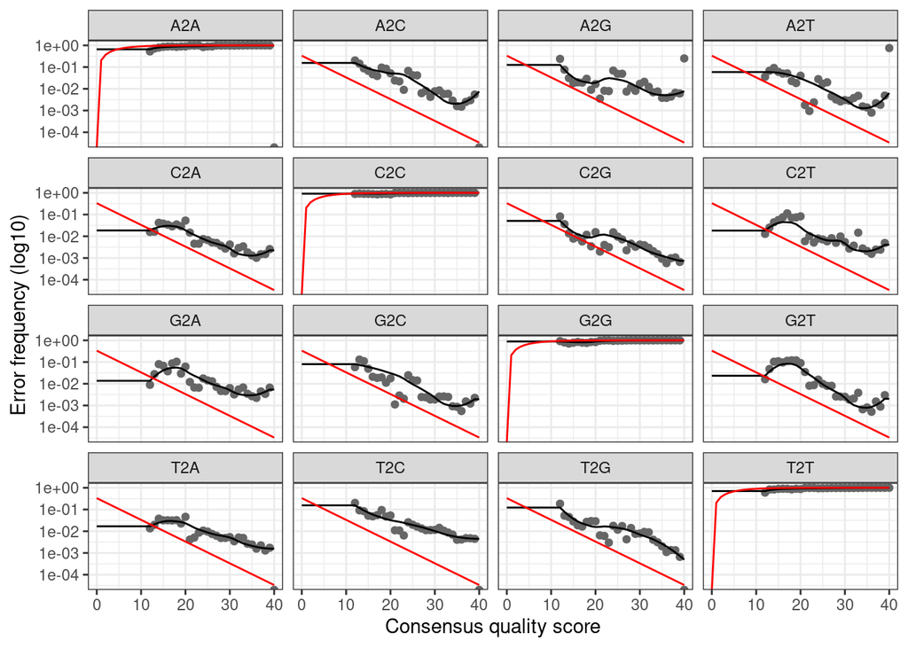

```r
plotErrors(errR, nominalQ=TRUE)
```

## Dereplication

```r
derepFs <- derepFastq(filtFs.survived, verbose=TRUE)
```

```
## Dereplicating sequence entries in Fastq file: /hpc/home/yk132/storage/data//scratch/filt/filtered/1_F_filt.fastq.gz
```

```
## Encountered 4129 unique sequences from 10544 total sequences read.
```

```
## Dereplicating sequence entries in Fastq file: /hpc/home/yk132/storage/data//scratch/filt/filtered/10_F_filt.fastq.gz
```

```
## Encountered 7678 unique sequences from 26450 total sequences read.
```

```
## Dereplicating sequence entries in Fastq file: /hpc/home/yk132/storage/data//scratch/filt/filtered/11_F_filt.fastq.gz
```

```
## Encountered 8142 unique sequences from 27851 total sequences read.
```

```
## Dereplicating sequence entries in Fastq file: /hpc/home/yk132/storage/data//scratch/filt/filtered/12_F_filt.fastq.gz
```

```
## Encountered 7462 unique sequences from 25638 total sequences read.
```

```
## Dereplicating sequence entries in Fastq file: /hpc/home/yk132/storage/data//scratch/filt/filtered/13_F_filt.fastq.gz
```

```
## Encountered 5529 unique sequences from 18087 total sequences read.
```

```
## Dereplicating sequence entries in Fastq file: /hpc/home/yk132/storage/data//scratch/filt/filtered/14_F_filt.fastq.gz
```

```
## Encountered 5742 unique sequences from 19091 total sequences read.
```

```
## Dereplicating sequence entries in Fastq file: /hpc/home/yk132/storage/data//scratch/filt/filtered/15_F_filt.fastq.gz
```

```
## Encountered 3768 unique sequences from 9323 total sequences read.
```

```
## Dereplicating sequence entries in Fastq file: /hpc/home/yk132/storage/data//scratch/filt/filtered/16_F_filt.fastq.gz
```

```
## Encountered 5615 unique sequences from 16785 total sequences read.
```

```
## Dereplicating sequence entries in Fastq file: /hpc/home/yk132/storage/data//scratch/filt/filtered/17_F_filt.fastq.gz
```

```
## Encountered 4459 unique sequences from 12359 total sequences read.
```

```
## Dereplicating sequence entries in Fastq file: /hpc/home/yk132/storage/data//scratch/filt/filtered/18_F_filt.fastq.gz
```

```
## Encountered 1672 unique sequences from 4514 total sequences read.
```

```
## Dereplicating sequence entries in Fastq file: /hpc/home/yk132/storage/data//scratch/filt/filtered/19_F_filt.fastq.gz
```

```
## Encountered 5056 unique sequences from 19325 total sequences read.
```

```
## Dereplicating sequence entries in Fastq file: /hpc/home/yk132/storage/data//scratch/filt/filtered/2_F_filt.fastq.gz
```

```
## Encountered 13036 unique sequences from 53873 total sequences read.
```

```
## Dereplicating sequence entries in Fastq file: /hpc/home/yk132/storage/data//scratch/filt/filtered/20_F_filt.fastq.gz
```

```
## Encountered 35 unique sequences from 67 total sequences read.
```

```
## Dereplicating sequence entries in Fastq file: /hpc/home/yk132/storage/data//scratch/filt/filtered/201_F_filt.fastq.gz
```

```
## Encountered 2686 unique sequences from 7179 total sequences read.
```

```
## Dereplicating sequence entries in Fastq file: /hpc/home/yk132/storage/data//scratch/filt/filtered/202_F_filt.fastq.gz
```

```
## Encountered 3843 unique sequences from 10078 total sequences read.
```

```
## Dereplicating sequence entries in Fastq file: /hpc/home/yk132/storage/data//scratch/filt/filtered/203_F_filt.fastq.gz
```

```
## Encountered 21700 unique sequences from 81857 total sequences read.
```

```
## Dereplicating sequence entries in Fastq file: /hpc/home/yk132/storage/data//scratch/filt/filtered/204_F_filt.fastq.gz
```

```
## Encountered 4470 unique sequences from 9916 total sequences read.
```

```
## Dereplicating sequence entries in Fastq file: /hpc/home/yk132/storage/data//scratch/filt/filtered/205_F_filt.fastq.gz
```

```
## Encountered 3785 unique sequences from 11307 total sequences read.
```

```
## Dereplicating sequence entries in Fastq file: /hpc/home/yk132/storage/data//scratch/filt/filtered/206_F_filt.fastq.gz
```

```
## Encountered 2963 unique sequences from 8011 total sequences read.
```

```
## Dereplicating sequence entries in Fastq file: /hpc/home/yk132/storage/data//scratch/filt/filtered/207_F_filt.fastq.gz
```

```
## Encountered 2808 unique sequences from 6674 total sequences read.
```

```
## Dereplicating sequence entries in Fastq file: /hpc/home/yk132/storage/data//scratch/filt/filtered/208_F_filt.fastq.gz
```

```
## Encountered 2917 unique sequences from 7178 total sequences read.
```

```
## Dereplicating sequence entries in Fastq file: /hpc/home/yk132/storage/data//scratch/filt/filtered/209_F_filt.fastq.gz
```

```
## Encountered 5037 unique sequences from 19207 total sequences read.
```

```
## Dereplicating sequence entries in Fastq file: /hpc/home/yk132/storage/data//scratch/filt/filtered/21_F_filt.fastq.gz
```

```
## Encountered 8434 unique sequences from 24700 total sequences read.
```

```
## Dereplicating sequence entries in Fastq file: /hpc/home/yk132/storage/data//scratch/filt/filtered/210_F_filt.fastq.gz
```

```
## Encountered 1752 unique sequences from 3389 total sequences read.
```

```
## Dereplicating sequence entries in Fastq file: /hpc/home/yk132/storage/data//scratch/filt/filtered/211_F_filt.fastq.gz
```

```
## Encountered 1735 unique sequences from 4327 total sequences read.
```

```
## Dereplicating sequence entries in Fastq file: /hpc/home/yk132/storage/data//scratch/filt/filtered/212_F_filt.fastq.gz
```

```
## Encountered 3737 unique sequences from 10270 total sequences read.
```

```
## Dereplicating sequence entries in Fastq file: /hpc/home/yk132/storage/data//scratch/filt/filtered/213_F_filt.fastq.gz
```

```
## Encountered 4095 unique sequences from 10664 total sequences read.
```

```
## Dereplicating sequence entries in Fastq file: /hpc/home/yk132/storage/data//scratch/filt/filtered/214_F_filt.fastq.gz
```

```
## Encountered 4665 unique sequences from 14527 total sequences read.
```

```
## Dereplicating sequence entries in Fastq file: /hpc/home/yk132/storage/data//scratch/filt/filtered/215_F_filt.fastq.gz
```

```
## Encountered 3597 unique sequences from 10416 total sequences read.
```

```
## Dereplicating sequence entries in Fastq file: /hpc/home/yk132/storage/data//scratch/filt/filtered/216_F_filt.fastq.gz
```

```
## Encountered 2950 unique sequences from 7255 total sequences read.
```

```
## Dereplicating sequence entries in Fastq file: /hpc/home/yk132/storage/data//scratch/filt/filtered/217_F_filt.fastq.gz
```

```
## Encountered 2869 unique sequences from 7542 total sequences read.
```

```
## Dereplicating sequence entries in Fastq file: /hpc/home/yk132/storage/data//scratch/filt/filtered/218_F_filt.fastq.gz
```

```
## Encountered 3057 unique sequences from 8196 total sequences read.
```

```
## Dereplicating sequence entries in Fastq file: /hpc/home/yk132/storage/data//scratch/filt/filtered/219_F_filt.fastq.gz
```

```
## Encountered 4961 unique sequences from 17076 total sequences read.
```

```
## Dereplicating sequence entries in Fastq file: /hpc/home/yk132/storage/data//scratch/filt/filtered/22_F_filt.fastq.gz
```

```
## Encountered 6195 unique sequences from 18384 total sequences read.
```

```
## Dereplicating sequence entries in Fastq file: /hpc/home/yk132/storage/data//scratch/filt/filtered/220_F_filt.fastq.gz
```

```
## Encountered 64 unique sequences from 114 total sequences read.
```

```
## Dereplicating sequence entries in Fastq file: /hpc/home/yk132/storage/data//scratch/filt/filtered/221_F_filt.fastq.gz
```

```
## Encountered 4102 unique sequences from 12902 total sequences read.
```

```
## Dereplicating sequence entries in Fastq file: /hpc/home/yk132/storage/data//scratch/filt/filtered/222_F_filt.fastq.gz
```

```
## Encountered 6629 unique sequences from 18159 total sequences read.
```

```
## Dereplicating sequence entries in Fastq file: /hpc/home/yk132/storage/data//scratch/filt/filtered/223_F_filt.fastq.gz
```

```
## Encountered 7301 unique sequences from 19231 total sequences read.
```

```
## Dereplicating sequence entries in Fastq file: /hpc/home/yk132/storage/data//scratch/filt/filtered/224_F_filt.fastq.gz
```

```
## Encountered 7043 unique sequences from 21678 total sequences read.
```

```
## Dereplicating sequence entries in Fastq file: /hpc/home/yk132/storage/data//scratch/filt/filtered/225_F_filt.fastq.gz
```

```
## Encountered 4341 unique sequences from 12680 total sequences read.
```

```
## Dereplicating sequence entries in Fastq file: /hpc/home/yk132/storage/data//scratch/filt/filtered/226_F_filt.fastq.gz
```

```
## Encountered 5391 unique sequences from 13949 total sequences read.
```

```
## Dereplicating sequence entries in Fastq file: /hpc/home/yk132/storage/data//scratch/filt/filtered/227_F_filt.fastq.gz
```

```
## Encountered 7371 unique sequences from 20015 total sequences read.
```

```
## Dereplicating sequence entries in Fastq file: /hpc/home/yk132/storage/data//scratch/filt/filtered/228_F_filt.fastq.gz
```

```
## Encountered 7001 unique sequences from 18592 total sequences read.
```

```
## Dereplicating sequence entries in Fastq file: /hpc/home/yk132/storage/data//scratch/filt/filtered/229_F_filt.fastq.gz
```

```
## Encountered 8387 unique sequences from 29241 total sequences read.
```

```
## Dereplicating sequence entries in Fastq file: /hpc/home/yk132/storage/data//scratch/filt/filtered/23_F_filt.fastq.gz
```

```
## Encountered 7173 unique sequences from 22422 total sequences read.
```

```
## Dereplicating sequence entries in Fastq file: /hpc/home/yk132/storage/data//scratch/filt/filtered/230_F_filt.fastq.gz
```

```
## Encountered 7028 unique sequences from 24412 total sequences read.
```

```
## Dereplicating sequence entries in Fastq file: /hpc/home/yk132/storage/data//scratch/filt/filtered/231_F_filt.fastq.gz
```

```
## Encountered 7885 unique sequences from 20782 total sequences read.
```

```
## Dereplicating sequence entries in Fastq file: /hpc/home/yk132/storage/data//scratch/filt/filtered/232_F_filt.fastq.gz
```

```
## Encountered 5569 unique sequences from 16754 total sequences read.
```

```
## Dereplicating sequence entries in Fastq file: /hpc/home/yk132/storage/data//scratch/filt/filtered/233_F_filt.fastq.gz
```

```
## Encountered 6127 unique sequences from 17421 total sequences read.
```

```
## Dereplicating sequence entries in Fastq file: /hpc/home/yk132/storage/data//scratch/filt/filtered/234_F_filt.fastq.gz
```

```
## Encountered 7200 unique sequences from 21559 total sequences read.
```

```
## Dereplicating sequence entries in Fastq file: /hpc/home/yk132/storage/data//scratch/filt/filtered/235_F_filt.fastq.gz
```

```
## Encountered 5469 unique sequences from 16850 total sequences read.
```

```
## Dereplicating sequence entries in Fastq file: /hpc/home/yk132/storage/data//scratch/filt/filtered/236_F_filt.fastq.gz
```

```
## Encountered 19 unique sequences from 26 total sequences read.
```

```
## Dereplicating sequence entries in Fastq file: /hpc/home/yk132/storage/data//scratch/filt/filtered/237_F_filt.fastq.gz
```

```
## Encountered 7 unique sequences from 7 total sequences read.
```

```
## Dereplicating sequence entries in Fastq file: /hpc/home/yk132/storage/data//scratch/filt/filtered/238_F_filt.fastq.gz
```

```
## Encountered 4 unique sequences from 4 total sequences read.
```

```
## Dereplicating sequence entries in Fastq file: /hpc/home/yk132/storage/data//scratch/filt/filtered/239_F_filt.fastq.gz
```

```
## Encountered 3313 unique sequences from 7011 total sequences read.
```

```
## Dereplicating sequence entries in Fastq file: /hpc/home/yk132/storage/data//scratch/filt/filtered/24_F_filt.fastq.gz
```

```
## Encountered 8207 unique sequences from 26092 total sequences read.
```

```
## Dereplicating sequence entries in Fastq file: /hpc/home/yk132/storage/data//scratch/filt/filtered/240_F_filt.fastq.gz
```

```
## Encountered 7599 unique sequences from 20407 total sequences read.
```

```
## Dereplicating sequence entries in Fastq file: /hpc/home/yk132/storage/data//scratch/filt/filtered/241_F_filt.fastq.gz
```

```
## Encountered 3640 unique sequences from 12956 total sequences read.
```

```
## Dereplicating sequence entries in Fastq file: /hpc/home/yk132/storage/data//scratch/filt/filtered/242_F_filt.fastq.gz
```

```
## Encountered 6920 unique sequences from 22577 total sequences read.
```

```
## Dereplicating sequence entries in Fastq file: /hpc/home/yk132/storage/data//scratch/filt/filtered/244_F_filt.fastq.gz
```

```
## Encountered 7308 unique sequences from 26084 total sequences read.
```

```
## Dereplicating sequence entries in Fastq file: /hpc/home/yk132/storage/data//scratch/filt/filtered/245_F_filt.fastq.gz
```

```
## Encountered 4238 unique sequences from 13253 total sequences read.
```

```
## Dereplicating sequence entries in Fastq file: /hpc/home/yk132/storage/data//scratch/filt/filtered/246_F_filt.fastq.gz
```

```
## Encountered 4837 unique sequences from 15101 total sequences read.
```

```
## Dereplicating sequence entries in Fastq file: /hpc/home/yk132/storage/data//scratch/filt/filtered/247_F_filt.fastq.gz
```

```
## Encountered 4709 unique sequences from 17808 total sequences read.
```

```
## Dereplicating sequence entries in Fastq file: /hpc/home/yk132/storage/data//scratch/filt/filtered/248_F_filt.fastq.gz
```

```
## Encountered 3931 unique sequences from 16907 total sequences read.
```

```
## Dereplicating sequence entries in Fastq file: /hpc/home/yk132/storage/data//scratch/filt/filtered/249_F_filt.fastq.gz
```

```
## Encountered 3330 unique sequences from 7905 total sequences read.
```

```
## Dereplicating sequence entries in Fastq file: /hpc/home/yk132/storage/data//scratch/filt/filtered/25_F_filt.fastq.gz
```

```
## Encountered 6851 unique sequences from 22004 total sequences read.
```

```
## Dereplicating sequence entries in Fastq file: /hpc/home/yk132/storage/data//scratch/filt/filtered/251_F_filt.fastq.gz
```

```
## Encountered 7888 unique sequences from 23654 total sequences read.
```

```
## Dereplicating sequence entries in Fastq file: /hpc/home/yk132/storage/data//scratch/filt/filtered/252_F_filt.fastq.gz
```

```
## Encountered 7823 unique sequences from 25066 total sequences read.
```

```
## Dereplicating sequence entries in Fastq file: /hpc/home/yk132/storage/data//scratch/filt/filtered/253_F_filt.fastq.gz
```

```
## Encountered 4550 unique sequences from 17631 total sequences read.
```

```
## Dereplicating sequence entries in Fastq file: /hpc/home/yk132/storage/data//scratch/filt/filtered/255_F_filt.fastq.gz
```

```
## Encountered 5630 unique sequences from 19233 total sequences read.
```

```
## Dereplicating sequence entries in Fastq file: /hpc/home/yk132/storage/data//scratch/filt/filtered/257_F_filt.fastq.gz
```

```
## Encountered 6214 unique sequences from 19656 total sequences read.
```

```
## Dereplicating sequence entries in Fastq file: /hpc/home/yk132/storage/data//scratch/filt/filtered/258_F_filt.fastq.gz
```

```
## Encountered 4118 unique sequences from 13926 total sequences read.
```

```
## Dereplicating sequence entries in Fastq file: /hpc/home/yk132/storage/data//scratch/filt/filtered/259_F_filt.fastq.gz
```

```
## Encountered 5634 unique sequences from 18676 total sequences read.
```

```
## Dereplicating sequence entries in Fastq file: /hpc/home/yk132/storage/data//scratch/filt/filtered/26_F_filt.fastq.gz
```

```
## Encountered 6252 unique sequences from 19183 total sequences read.
```

```
## Dereplicating sequence entries in Fastq file: /hpc/home/yk132/storage/data//scratch/filt/filtered/260_F_filt.fastq.gz
```

```
## Encountered 4711 unique sequences from 17598 total sequences read.
```

```
## Dereplicating sequence entries in Fastq file: /hpc/home/yk132/storage/data//scratch/filt/filtered/262_F_filt.fastq.gz
```

```
## Encountered 1760 unique sequences from 4814 total sequences read.
```

```
## Dereplicating sequence entries in Fastq file: /hpc/home/yk132/storage/data//scratch/filt/filtered/263_F_filt.fastq.gz
```

```
## Encountered 3927 unique sequences from 12764 total sequences read.
```

```
## Dereplicating sequence entries in Fastq file: /hpc/home/yk132/storage/data//scratch/filt/filtered/265_F_filt.fastq.gz
```

```
## Encountered 6151 unique sequences from 23014 total sequences read.
```

```
## Dereplicating sequence entries in Fastq file: /hpc/home/yk132/storage/data//scratch/filt/filtered/266_F_filt.fastq.gz
```

```
## Encountered 5923 unique sequences from 16863 total sequences read.
```

```
## Dereplicating sequence entries in Fastq file: /hpc/home/yk132/storage/data//scratch/filt/filtered/267_F_filt.fastq.gz
```

```
## Encountered 3462 unique sequences from 7295 total sequences read.
```

```
## Dereplicating sequence entries in Fastq file: /hpc/home/yk132/storage/data//scratch/filt/filtered/268_F_filt.fastq.gz
```

```
## Encountered 6107 unique sequences from 19975 total sequences read.
```

```
## Dereplicating sequence entries in Fastq file: /hpc/home/yk132/storage/data//scratch/filt/filtered/269_F_filt.fastq.gz
```

```
## Encountered 4073 unique sequences from 14461 total sequences read.
```

```
## Dereplicating sequence entries in Fastq file: /hpc/home/yk132/storage/data//scratch/filt/filtered/27_F_filt.fastq.gz
```

```
## Encountered 10357 unique sequences from 25787 total sequences read.
```

```
## Dereplicating sequence entries in Fastq file: /hpc/home/yk132/storage/data//scratch/filt/filtered/270_F_filt.fastq.gz
```

```
## Encountered 4446 unique sequences from 14715 total sequences read.
```

```
## Dereplicating sequence entries in Fastq file: /hpc/home/yk132/storage/data//scratch/filt/filtered/271_F_filt.fastq.gz
```

```
## Encountered 4420 unique sequences from 13144 total sequences read.
```

```
## Dereplicating sequence entries in Fastq file: /hpc/home/yk132/storage/data//scratch/filt/filtered/272_F_filt.fastq.gz
```

```
## Encountered 3830 unique sequences from 11891 total sequences read.
```

```
## Dereplicating sequence entries in Fastq file: /hpc/home/yk132/storage/data//scratch/filt/filtered/273_F_filt.fastq.gz
```

```
## Encountered 4452 unique sequences from 15015 total sequences read.
```

```
## Dereplicating sequence entries in Fastq file: /hpc/home/yk132/storage/data//scratch/filt/filtered/274_F_filt.fastq.gz
```

```
## Encountered 17 unique sequences from 26 total sequences read.
```

```
## Dereplicating sequence entries in Fastq file: /hpc/home/yk132/storage/data//scratch/filt/filtered/275_F_filt.fastq.gz
```

```
## Encountered 14 unique sequences from 24 total sequences read.
```

```
## Dereplicating sequence entries in Fastq file: /hpc/home/yk132/storage/data//scratch/filt/filtered/276_F_filt.fastq.gz
```

```
## Encountered 2 unique sequences from 2 total sequences read.
```

```
## Dereplicating sequence entries in Fastq file: /hpc/home/yk132/storage/data//scratch/filt/filtered/277_F_filt.fastq.gz
```

```
## Encountered 2 unique sequences from 4 total sequences read.
```

```
## Dereplicating sequence entries in Fastq file: /hpc/home/yk132/storage/data//scratch/filt/filtered/278_F_filt.fastq.gz
```

```
## Encountered 2522 unique sequences from 7250 total sequences read.
```

```
## Dereplicating sequence entries in Fastq file: /hpc/home/yk132/storage/data//scratch/filt/filtered/279_F_filt.fastq.gz
```

```
## Encountered 7176 unique sequences from 23549 total sequences read.
```

```
## Dereplicating sequence entries in Fastq file: /hpc/home/yk132/storage/data//scratch/filt/filtered/28_F_filt.fastq.gz
```

```
## Encountered 14628 unique sequences from 55255 total sequences read.
```

```
## Dereplicating sequence entries in Fastq file: /hpc/home/yk132/storage/data//scratch/filt/filtered/280_F_filt.fastq.gz
```

```
## Encountered 7464 unique sequences from 25034 total sequences read.
```

```
## Dereplicating sequence entries in Fastq file: /hpc/home/yk132/storage/data//scratch/filt/filtered/281_F_filt.fastq.gz
```

```
## Encountered 6019 unique sequences from 18514 total sequences read.
```

```
## Dereplicating sequence entries in Fastq file: /hpc/home/yk132/storage/data//scratch/filt/filtered/282_F_filt.fastq.gz
```

```
## Encountered 5995 unique sequences from 22135 total sequences read.
```

```
## Dereplicating sequence entries in Fastq file: /hpc/home/yk132/storage/data//scratch/filt/filtered/284_F_filt.fastq.gz
```

```
## Encountered 5565 unique sequences from 18964 total sequences read.
```

```
## Dereplicating sequence entries in Fastq file: /hpc/home/yk132/storage/data//scratch/filt/filtered/286_F_filt.fastq.gz
```

```
## Encountered 7917 unique sequences from 25420 total sequences read.
```

```
## Dereplicating sequence entries in Fastq file: /hpc/home/yk132/storage/data//scratch/filt/filtered/287_F_filt.fastq.gz
```

```
## Encountered 5694 unique sequences from 16264 total sequences read.
```

```
## Dereplicating sequence entries in Fastq file: /hpc/home/yk132/storage/data//scratch/filt/filtered/288_F_filt.fastq.gz
```

```
## Encountered 4956 unique sequences from 17146 total sequences read.
```

```
## Dereplicating sequence entries in Fastq file: /hpc/home/yk132/storage/data//scratch/filt/filtered/289_F_filt.fastq.gz
```

```
## Encountered 6911 unique sequences from 21348 total sequences read.
```

```
## Dereplicating sequence entries in Fastq file: /hpc/home/yk132/storage/data//scratch/filt/filtered/29_F_filt.fastq.gz
```

```
## Encountered 5769 unique sequences from 26428 total sequences read.
```

```
## Dereplicating sequence entries in Fastq file: /hpc/home/yk132/storage/data//scratch/filt/filtered/290_F_filt.fastq.gz
```

```
## Encountered 4748 unique sequences from 15189 total sequences read.
```

```
## Dereplicating sequence entries in Fastq file: /hpc/home/yk132/storage/data//scratch/filt/filtered/291_F_filt.fastq.gz
```

```
## Encountered 3173 unique sequences from 7955 total sequences read.
```

```
## Dereplicating sequence entries in Fastq file: /hpc/home/yk132/storage/data//scratch/filt/filtered/292_F_filt.fastq.gz
```

```
## Encountered 4769 unique sequences from 16139 total sequences read.
```

```
## Dereplicating sequence entries in Fastq file: /hpc/home/yk132/storage/data//scratch/filt/filtered/293_F_filt.fastq.gz
```

```
## Encountered 6156 unique sequences from 19515 total sequences read.
```

```
## Dereplicating sequence entries in Fastq file: /hpc/home/yk132/storage/data//scratch/filt/filtered/294_F_filt.fastq.gz
```

```
## Encountered 3869 unique sequences from 12256 total sequences read.
```

```
## Dereplicating sequence entries in Fastq file: /hpc/home/yk132/storage/data//scratch/filt/filtered/295_F_filt.fastq.gz
```

```
## Encountered 10572 unique sequences from 32679 total sequences read.
```

```
## Dereplicating sequence entries in Fastq file: /hpc/home/yk132/storage/data//scratch/filt/filtered/296_F_filt.fastq.gz
```

```
## Encountered 4678 unique sequences from 22670 total sequences read.
```

```
## Dereplicating sequence entries in Fastq file: /hpc/home/yk132/storage/data//scratch/filt/filtered/297_F_filt.fastq.gz
```

```
## Encountered 5365 unique sequences from 20302 total sequences read.
```

```
## Dereplicating sequence entries in Fastq file: /hpc/home/yk132/storage/data//scratch/filt/filtered/298_F_filt.fastq.gz
```

```
## Encountered 6858 unique sequences from 17683 total sequences read.
```

```
## Dereplicating sequence entries in Fastq file: /hpc/home/yk132/storage/data//scratch/filt/filtered/299_F_filt.fastq.gz
```

```
## Encountered 1 unique sequences from 1 total sequences read.
```

```
## Dereplicating sequence entries in Fastq file: /hpc/home/yk132/storage/data//scratch/filt/filtered/3_F_filt.fastq.gz
```

```
## Encountered 14078 unique sequences from 58294 total sequences read.
```

```
## Dereplicating sequence entries in Fastq file: /hpc/home/yk132/storage/data//scratch/filt/filtered/30_F_filt.fastq.gz
```

```
## Encountered 9053 unique sequences from 32596 total sequences read.
```

```
## Dereplicating sequence entries in Fastq file: /hpc/home/yk132/storage/data//scratch/filt/filtered/300_F_filt.fastq.gz
```

```
## Encountered 6 unique sequences from 7 total sequences read.
```

```
## Dereplicating sequence entries in Fastq file: /hpc/home/yk132/storage/data//scratch/filt/filtered/301_F_filt.fastq.gz
```

```
## Encountered 2812 unique sequences from 7440 total sequences read.
```

```
## Dereplicating sequence entries in Fastq file: /hpc/home/yk132/storage/data//scratch/filt/filtered/302_F_filt.fastq.gz
```

```
## Encountered 5339 unique sequences from 17456 total sequences read.
```

```
## Dereplicating sequence entries in Fastq file: /hpc/home/yk132/storage/data//scratch/filt/filtered/303_F_filt.fastq.gz
```

```
## Encountered 5711 unique sequences from 16935 total sequences read.
```

```
## Dereplicating sequence entries in Fastq file: /hpc/home/yk132/storage/data//scratch/filt/filtered/304_F_filt.fastq.gz
```

```
## Encountered 7901 unique sequences from 20932 total sequences read.
```

```
## Dereplicating sequence entries in Fastq file: /hpc/home/yk132/storage/data//scratch/filt/filtered/305_F_filt.fastq.gz
```

```
## Encountered 4871 unique sequences from 14757 total sequences read.
```

```
## Dereplicating sequence entries in Fastq file: /hpc/home/yk132/storage/data//scratch/filt/filtered/306_F_filt.fastq.gz
```

```
## Encountered 6161 unique sequences from 18314 total sequences read.
```

```
## Dereplicating sequence entries in Fastq file: /hpc/home/yk132/storage/data//scratch/filt/filtered/307_F_filt.fastq.gz
```

```
## Encountered 5314 unique sequences from 17525 total sequences read.
```

```
## Dereplicating sequence entries in Fastq file: /hpc/home/yk132/storage/data//scratch/filt/filtered/308_F_filt.fastq.gz
```

```
## Encountered 4901 unique sequences from 16476 total sequences read.
```

```
## Dereplicating sequence entries in Fastq file: /hpc/home/yk132/storage/data//scratch/filt/filtered/309_F_filt.fastq.gz
```

```
## Encountered 6374 unique sequences from 20935 total sequences read.
```

```
## Dereplicating sequence entries in Fastq file: /hpc/home/yk132/storage/data//scratch/filt/filtered/31_F_filt.fastq.gz
```

```
## Encountered 15 unique sequences from 16 total sequences read.
```

```
## Dereplicating sequence entries in Fastq file: /hpc/home/yk132/storage/data//scratch/filt/filtered/310_F_filt.fastq.gz
```

```
## Encountered 7094 unique sequences from 20374 total sequences read.
```

```
## Dereplicating sequence entries in Fastq file: /hpc/home/yk132/storage/data//scratch/filt/filtered/311_F_filt.fastq.gz
```

```
## Encountered 5761 unique sequences from 15568 total sequences read.
```

```
## Dereplicating sequence entries in Fastq file: /hpc/home/yk132/storage/data//scratch/filt/filtered/312_F_filt.fastq.gz
```

```
## Encountered 5198 unique sequences from 14432 total sequences read.
```

```
## Dereplicating sequence entries in Fastq file: /hpc/home/yk132/storage/data//scratch/filt/filtered/313_F_filt.fastq.gz
```

```
## Encountered 3200 unique sequences from 7781 total sequences read.
```

```
## Dereplicating sequence entries in Fastq file: /hpc/home/yk132/storage/data//scratch/filt/filtered/314_F_filt.fastq.gz
```

```
## Encountered 3287 unique sequences from 10855 total sequences read.
```

```
## Dereplicating sequence entries in Fastq file: /hpc/home/yk132/storage/data//scratch/filt/filtered/315_F_filt.fastq.gz
```

```
## Encountered 7412 unique sequences from 22738 total sequences read.
```

```
## Dereplicating sequence entries in Fastq file: /hpc/home/yk132/storage/data//scratch/filt/filtered/316_F_filt.fastq.gz
```

```
## Encountered 3476 unique sequences from 9207 total sequences read.
```

```
## Dereplicating sequence entries in Fastq file: /hpc/home/yk132/storage/data//scratch/filt/filtered/317_F_filt.fastq.gz
```

```
## Encountered 5594 unique sequences from 14112 total sequences read.
```

```
## Dereplicating sequence entries in Fastq file: /hpc/home/yk132/storage/data//scratch/filt/filtered/318_F_filt.fastq.gz
```

```
## Encountered 3 unique sequences from 3 total sequences read.
```

```
## Dereplicating sequence entries in Fastq file: /hpc/home/yk132/storage/data//scratch/filt/filtered/319_F_filt.fastq.gz
```

```
## Encountered 1 unique sequences from 1 total sequences read.
```

```
## Dereplicating sequence entries in Fastq file: /hpc/home/yk132/storage/data//scratch/filt/filtered/32_F_filt.fastq.gz
```

```
## Encountered 7571 unique sequences from 27936 total sequences read.
```

```
## Dereplicating sequence entries in Fastq file: /hpc/home/yk132/storage/data//scratch/filt/filtered/320_F_filt.fastq.gz
```

```
## Encountered 6620 unique sequences from 20417 total sequences read.
```

```
## Dereplicating sequence entries in Fastq file: /hpc/home/yk132/storage/data//scratch/filt/filtered/321_F_filt.fastq.gz
```

```
## Encountered 4686 unique sequences from 16585 total sequences read.
```

```
## Dereplicating sequence entries in Fastq file: /hpc/home/yk132/storage/data//scratch/filt/filtered/322_F_filt.fastq.gz
```

```
## Encountered 2455 unique sequences from 6065 total sequences read.
```

```
## Dereplicating sequence entries in Fastq file: /hpc/home/yk132/storage/data//scratch/filt/filtered/324_F_filt.fastq.gz
```

```
## Encountered 3517 unique sequences from 9476 total sequences read.
```

```
## Dereplicating sequence entries in Fastq file: /hpc/home/yk132/storage/data//scratch/filt/filtered/325_F_filt.fastq.gz
```

```
## Encountered 5683 unique sequences from 22046 total sequences read.
```

```
## Dereplicating sequence entries in Fastq file: /hpc/home/yk132/storage/data//scratch/filt/filtered/326_F_filt.fastq.gz
```

```
## Encountered 7876 unique sequences from 29981 total sequences read.
```

```
## Dereplicating sequence entries in Fastq file: /hpc/home/yk132/storage/data//scratch/filt/filtered/327_F_filt.fastq.gz
```

```
## Encountered 4521 unique sequences from 14052 total sequences read.
```

```
## Dereplicating sequence entries in Fastq file: /hpc/home/yk132/storage/data//scratch/filt/filtered/328_F_filt.fastq.gz
```

```
## Encountered 482 unique sequences from 1237 total sequences read.
```

```
## Dereplicating sequence entries in Fastq file: /hpc/home/yk132/storage/data//scratch/filt/filtered/33_F_filt.fastq.gz
```

```
## Encountered 7948 unique sequences from 26507 total sequences read.
```

```
## Dereplicating sequence entries in Fastq file: /hpc/home/yk132/storage/data//scratch/filt/filtered/330_F_filt.fastq.gz
```

```
## Encountered 7169 unique sequences from 19972 total sequences read.
```

```
## Dereplicating sequence entries in Fastq file: /hpc/home/yk132/storage/data//scratch/filt/filtered/331_F_filt.fastq.gz
```

```
## Encountered 7387 unique sequences from 23731 total sequences read.
```

```
## Dereplicating sequence entries in Fastq file: /hpc/home/yk132/storage/data//scratch/filt/filtered/333_F_filt.fastq.gz
```

```
## Encountered 4719 unique sequences from 11914 total sequences read.
```

```
## Dereplicating sequence entries in Fastq file: /hpc/home/yk132/storage/data//scratch/filt/filtered/334_F_filt.fastq.gz
```

```
## Encountered 3392 unique sequences from 8719 total sequences read.
```

```
## Dereplicating sequence entries in Fastq file: /hpc/home/yk132/storage/data//scratch/filt/filtered/335_F_filt.fastq.gz
```

```
## Encountered 4462 unique sequences from 11100 total sequences read.
```

```
## Dereplicating sequence entries in Fastq file: /hpc/home/yk132/storage/data//scratch/filt/filtered/336_F_filt.fastq.gz
```

```
## Encountered 3912 unique sequences from 11828 total sequences read.
```

```
## Dereplicating sequence entries in Fastq file: /hpc/home/yk132/storage/data//scratch/filt/filtered/337_F_filt.fastq.gz
```

```
## Encountered 46 unique sequences from 61 total sequences read.
```

```
## Dereplicating sequence entries in Fastq file: /hpc/home/yk132/storage/data//scratch/filt/filtered/338_F_filt.fastq.gz
```

```
## Encountered 5 unique sequences from 6 total sequences read.
```

```
## Dereplicating sequence entries in Fastq file: /hpc/home/yk132/storage/data//scratch/filt/filtered/34_F_filt.fastq.gz
```

```
## Encountered 5738 unique sequences from 18370 total sequences read.
```

```
## Dereplicating sequence entries in Fastq file: /hpc/home/yk132/storage/data//scratch/filt/filtered/35_F_filt.fastq.gz
```

```
## Encountered 4561 unique sequences from 14780 total sequences read.
```

```
## Dereplicating sequence entries in Fastq file: /hpc/home/yk132/storage/data//scratch/filt/filtered/36_F_filt.fastq.gz
```

```
## Encountered 932 unique sequences from 4027 total sequences read.
```

```
## Dereplicating sequence entries in Fastq file: /hpc/home/yk132/storage/data//scratch/filt/filtered/37_F_filt.fastq.gz
```

```
## Encountered 12585 unique sequences from 43740 total sequences read.
```

```
## Dereplicating sequence entries in Fastq file: /hpc/home/yk132/storage/data//scratch/filt/filtered/38_F_filt.fastq.gz
```

```
## Encountered 8502 unique sequences from 29881 total sequences read.
```

```
## Dereplicating sequence entries in Fastq file: /hpc/home/yk132/storage/data//scratch/filt/filtered/39_F_filt.fastq.gz
```

```
## Encountered 6417 unique sequences from 21429 total sequences read.
```

```
## Dereplicating sequence entries in Fastq file: /hpc/home/yk132/storage/data//scratch/filt/filtered/4_F_filt.fastq.gz
```

```
## Encountered 8947 unique sequences from 32380 total sequences read.
```

```
## Dereplicating sequence entries in Fastq file: /hpc/home/yk132/storage/data//scratch/filt/filtered/40_F_filt.fastq.gz
```

```
## Encountered 7215 unique sequences from 22759 total sequences read.
```

```
## Dereplicating sequence entries in Fastq file: /hpc/home/yk132/storage/data//scratch/filt/filtered/41_F_filt.fastq.gz
```

```
## Encountered 5891 unique sequences from 20455 total sequences read.
```

```
## Dereplicating sequence entries in Fastq file: /hpc/home/yk132/storage/data//scratch/filt/filtered/42_F_filt.fastq.gz
```

```
## Encountered 6488 unique sequences from 23068 total sequences read.
```

```
## Dereplicating sequence entries in Fastq file: /hpc/home/yk132/storage/data//scratch/filt/filtered/43_F_filt.fastq.gz
```

```
## Encountered 5878 unique sequences from 14570 total sequences read.
```

```
## Dereplicating sequence entries in Fastq file: /hpc/home/yk132/storage/data//scratch/filt/filtered/44_F_filt.fastq.gz
```

```
## Encountered 4751 unique sequences from 10599 total sequences read.
```

```
## Dereplicating sequence entries in Fastq file: /hpc/home/yk132/storage/data//scratch/filt/filtered/45_F_filt.fastq.gz
```

```
## Encountered 8240 unique sequences from 23817 total sequences read.
```

```
## Dereplicating sequence entries in Fastq file: /hpc/home/yk132/storage/data//scratch/filt/filtered/46_F_filt.fastq.gz
```

```
## Encountered 8088 unique sequences from 29905 total sequences read.
```

```
## Dereplicating sequence entries in Fastq file: /hpc/home/yk132/storage/data//scratch/filt/filtered/47_F_filt.fastq.gz
```

```
## Encountered 6532 unique sequences from 26365 total sequences read.
```

```
## Dereplicating sequence entries in Fastq file: /hpc/home/yk132/storage/data//scratch/filt/filtered/48_F_filt.fastq.gz
```

```
## Encountered 7823 unique sequences from 27364 total sequences read.
```

```
## Dereplicating sequence entries in Fastq file: /hpc/home/yk132/storage/data//scratch/filt/filtered/49_F_filt.fastq.gz
```

```
## Encountered 5 unique sequences from 5 total sequences read.
```

```
## Dereplicating sequence entries in Fastq file: /hpc/home/yk132/storage/data//scratch/filt/filtered/5_F_filt.fastq.gz
```

```
## Encountered 8557 unique sequences from 25274 total sequences read.
```

```
## Dereplicating sequence entries in Fastq file: /hpc/home/yk132/storage/data//scratch/filt/filtered/50_F_filt.fastq.gz
```

```
## Encountered 6747 unique sequences from 22981 total sequences read.
```

```
## Dereplicating sequence entries in Fastq file: /hpc/home/yk132/storage/data//scratch/filt/filtered/51_F_filt.fastq.gz
```

```
## Encountered 5307 unique sequences from 17696 total sequences read.
```

```
## Dereplicating sequence entries in Fastq file: /hpc/home/yk132/storage/data//scratch/filt/filtered/52_F_filt.fastq.gz
```

```
## Encountered 7534 unique sequences from 28423 total sequences read.
```

```
## Dereplicating sequence entries in Fastq file: /hpc/home/yk132/storage/data//scratch/filt/filtered/53_F_filt.fastq.gz
```

```
## Encountered 25063 unique sequences from 95725 total sequences read.
```

```
## Dereplicating sequence entries in Fastq file: /hpc/home/yk132/storage/data//scratch/filt/filtered/54_F_filt.fastq.gz
```

```
## Encountered 5340 unique sequences from 13457 total sequences read.
```

```
## Dereplicating sequence entries in Fastq file: /hpc/home/yk132/storage/data//scratch/filt/filtered/55_F_filt.fastq.gz
```

```
## Encountered 5056 unique sequences from 13849 total sequences read.
```

```
## Dereplicating sequence entries in Fastq file: /hpc/home/yk132/storage/data//scratch/filt/filtered/56_F_filt.fastq.gz
```

```
## Encountered 4769 unique sequences from 13547 total sequences read.
```

```
## Dereplicating sequence entries in Fastq file: /hpc/home/yk132/storage/data//scratch/filt/filtered/57_F_filt.fastq.gz
```

```
## Encountered 5012 unique sequences from 21677 total sequences read.
```

```
## Dereplicating sequence entries in Fastq file: /hpc/home/yk132/storage/data//scratch/filt/filtered/58_F_filt.fastq.gz
```

```
## Encountered 5555 unique sequences from 19091 total sequences read.
```

```
## Dereplicating sequence entries in Fastq file: /hpc/home/yk132/storage/data//scratch/filt/filtered/59_F_filt.fastq.gz
```

```
## Encountered 4918 unique sequences from 14288 total sequences read.
```

```
## Dereplicating sequence entries in Fastq file: /hpc/home/yk132/storage/data//scratch/filt/filtered/6_F_filt.fastq.gz
```

```
## Encountered 6177 unique sequences from 26344 total sequences read.
```

```
## Dereplicating sequence entries in Fastq file: /hpc/home/yk132/storage/data//scratch/filt/filtered/60_F_filt.fastq.gz
```

```
## Encountered 1556 unique sequences from 3964 total sequences read.
```

```
## Dereplicating sequence entries in Fastq file: /hpc/home/yk132/storage/data//scratch/filt/filtered/61_F_filt.fastq.gz
```

```
## Encountered 3292 unique sequences from 11158 total sequences read.
```

```
## Dereplicating sequence entries in Fastq file: /hpc/home/yk132/storage/data//scratch/filt/filtered/62_F_filt.fastq.gz
```

```
## Encountered 3 unique sequences from 18 total sequences read.
```

```
## Dereplicating sequence entries in Fastq file: /hpc/home/yk132/storage/data//scratch/filt/filtered/63_F_filt.fastq.gz
```

```
## Encountered 3885 unique sequences from 11188 total sequences read.
```

```
## Dereplicating sequence entries in Fastq file: /hpc/home/yk132/storage/data//scratch/filt/filtered/64_F_filt.fastq.gz
```

```
## Encountered 6633 unique sequences from 18729 total sequences read.
```

```
## Dereplicating sequence entries in Fastq file: /hpc/home/yk132/storage/data//scratch/filt/filtered/65_F_filt.fastq.gz
```

```
## Encountered 3852 unique sequences from 18823 total sequences read.
```

```
## Dereplicating sequence entries in Fastq file: /hpc/home/yk132/storage/data//scratch/filt/filtered/66_F_filt.fastq.gz
```

```
## Encountered 4213 unique sequences from 14329 total sequences read.
```

```
## Dereplicating sequence entries in Fastq file: /hpc/home/yk132/storage/data//scratch/filt/filtered/67_F_filt.fastq.gz
```

```
## Encountered 4037 unique sequences from 10120 total sequences read.
```

```
## Dereplicating sequence entries in Fastq file: /hpc/home/yk132/storage/data//scratch/filt/filtered/68_F_filt.fastq.gz
```

```
## Encountered 5539 unique sequences from 15456 total sequences read.
```

```
## Dereplicating sequence entries in Fastq file: /hpc/home/yk132/storage/data//scratch/filt/filtered/69_F_filt.fastq.gz
```

```
## Encountered 5925 unique sequences from 18205 total sequences read.
```

```
## Dereplicating sequence entries in Fastq file: /hpc/home/yk132/storage/data//scratch/filt/filtered/7_F_filt.fastq.gz
```

```
## Encountered 5198 unique sequences from 15282 total sequences read.
```

```
## Dereplicating sequence entries in Fastq file: /hpc/home/yk132/storage/data//scratch/filt/filtered/70_F_filt.fastq.gz
```

```
## Encountered 4400 unique sequences from 13950 total sequences read.
```

```
## Dereplicating sequence entries in Fastq file: /hpc/home/yk132/storage/data//scratch/filt/filtered/71_F_filt.fastq.gz
```

```
## Encountered 8 unique sequences from 8 total sequences read.
```

```
## Dereplicating sequence entries in Fastq file: /hpc/home/yk132/storage/data//scratch/filt/filtered/72_F_filt.fastq.gz
```

```
## Encountered 4001 unique sequences from 10251 total sequences read.
```

```
## Dereplicating sequence entries in Fastq file: /hpc/home/yk132/storage/data//scratch/filt/filtered/73_F_filt.fastq.gz
```

```
## Encountered 5859 unique sequences from 23414 total sequences read.
```

```
## Dereplicating sequence entries in Fastq file: /hpc/home/yk132/storage/data//scratch/filt/filtered/74_F_filt.fastq.gz
```

```
## Encountered 133 unique sequences from 342 total sequences read.
```

```
## Dereplicating sequence entries in Fastq file: /hpc/home/yk132/storage/data//scratch/filt/filtered/8_F_filt.fastq.gz
```

```
## Encountered 3029 unique sequences from 8335 total sequences read.
```

```
## Dereplicating sequence entries in Fastq file: /hpc/home/yk132/storage/data//scratch/filt/filtered/9_F_filt.fastq.gz
```

```
## Encountered 4956 unique sequences from 12272 total sequences read.
```

```
## Dereplicating sequence entries in Fastq file: /hpc/home/yk132/storage/data//scratch/filt/filtered/DW3-1_F_filt.fastq.gz
```

```
## Encountered 159 unique sequences from 563 total sequences read.
```

```
## Dereplicating sequence entries in Fastq file: /hpc/home/yk132/storage/data//scratch/filt/filtered/DW3-2_F_filt.fastq.gz
```

```
## Encountered 496 unique sequences from 1858 total sequences read.
```

```
## Dereplicating sequence entries in Fastq file: /hpc/home/yk132/storage/data//scratch/filt/filtered/DW3-3_F_filt.fastq.gz
```

```
## Encountered 14 unique sequences from 66 total sequences read.
```

```
## Dereplicating sequence entries in Fastq file: /hpc/home/yk132/storage/data//scratch/filt/filtered/DW4-1_F_filt.fastq.gz
```

```
## Encountered 1 unique sequences from 1 total sequences read.
```

```
## Dereplicating sequence entries in Fastq file: /hpc/home/yk132/storage/data//scratch/filt/filtered/DW4-2_F_filt.fastq.gz
```

```
## Encountered 2 unique sequences from 3 total sequences read.
```

```
## Dereplicating sequence entries in Fastq file: /hpc/home/yk132/storage/data//scratch/filt/filtered/DW4-3_F_filt.fastq.gz
```

```
## Encountered 1 unique sequences from 1 total sequences read.
```

```
## Dereplicating sequence entries in Fastq file: /hpc/home/yk132/storage/data//scratch/filt/filtered/DW5-1_F_filt.fastq.gz
```

```
## Encountered 25 unique sequences from 63 total sequences read.
```

```
## Dereplicating sequence entries in Fastq file: /hpc/home/yk132/storage/data//scratch/filt/filtered/DW5-2_F_filt.fastq.gz
```

```
## Encountered 25 unique sequences from 44 total sequences read.
```

```
## Dereplicating sequence entries in Fastq file: /hpc/home/yk132/storage/data//scratch/filt/filtered/DW6-1_F_filt.fastq.gz
```

```
## Encountered 17 unique sequences from 20 total sequences read.
```

```
## Dereplicating sequence entries in Fastq file: /hpc/home/yk132/storage/data//scratch/filt/filtered/DW6-2_F_filt.fastq.gz
```

```
## Encountered 13 unique sequences from 13 total sequences read.
```

```
## Dereplicating sequence entries in Fastq file: /hpc/home/yk132/storage/data//scratch/filt/filtered/DW6-3_F_filt.fastq.gz
```

```
## Encountered 19 unique sequences from 19 total sequences read.
```

```
## Dereplicating sequence entries in Fastq file: /hpc/home/yk132/storage/data//scratch/filt/filtered/DW7-1_F_filt.fastq.gz
```

```
## Encountered 61 unique sequences from 80 total sequences read.
```

```
## Dereplicating sequence entries in Fastq file: /hpc/home/yk132/storage/data//scratch/filt/filtered/DW7-2_F_filt.fastq.gz
```

```
## Encountered 3 unique sequences from 3 total sequences read.
```

```
## Dereplicating sequence entries in Fastq file: /hpc/home/yk132/storage/data//scratch/filt/filtered/DW7-3_F_filt.fastq.gz
```

```
## Encountered 6 unique sequences from 6 total sequences read.
```

```
## Dereplicating sequence entries in Fastq file: /hpc/home/yk132/storage/data//scratch/filt/filtered/Elution-blank-1_F_filt.fastq.gz
```

```
## Encountered 857 unique sequences from 15692 total sequences read.
```

```
## Dereplicating sequence entries in Fastq file: /hpc/home/yk132/storage/data//scratch/filt/filtered/Elution-blank-2_F_filt.fastq.gz
```

```
## Encountered 776 unique sequences from 14902 total sequences read.
```

```
## Dereplicating sequence entries in Fastq file: /hpc/home/yk132/storage/data//scratch/filt/filtered/Elution-blank-3_F_filt.fastq.gz
```

```
## Encountered 1743 unique sequences from 24838 total sequences read.
```

```
## Dereplicating sequence entries in Fastq file: /hpc/home/yk132/storage/data//scratch/filt/filtered/F-Redo-PCR-Bl1_F_filt.fastq.gz
```

```
## Encountered 21 unique sequences from 29 total sequences read.
```

```
## Dereplicating sequence entries in Fastq file: /hpc/home/yk132/storage/data//scratch/filt/filtered/F-Redo-PCR-Bl3_F_filt.fastq.gz
```

```
## Encountered 412 unique sequences from 1263 total sequences read.
```

```
## Dereplicating sequence entries in Fastq file: /hpc/home/yk132/storage/data//scratch/filt/filtered/JI-646_F_filt.fastq.gz
```

```
## Encountered 2674 unique sequences from 28929 total sequences read.
```

```
## Dereplicating sequence entries in Fastq file: /hpc/home/yk132/storage/data//scratch/filt/filtered/JI-647_F_filt.fastq.gz
```

```
## Encountered 1293 unique sequences from 19449 total sequences read.
```

```
## Dereplicating sequence entries in Fastq file: /hpc/home/yk132/storage/data//scratch/filt/filtered/JI-648_F_filt.fastq.gz
```

```
## Encountered 3048 unique sequences from 27783 total sequences read.
```

```
## Dereplicating sequence entries in Fastq file: /hpc/home/yk132/storage/data//scratch/filt/filtered/JI-649_F_filt.fastq.gz
```

```
## Encountered 1335 unique sequences from 14322 total sequences read.
```

```
## Dereplicating sequence entries in Fastq file: /hpc/home/yk132/storage/data//scratch/filt/filtered/JI-651_F_filt.fastq.gz
```

```
## Encountered 1504 unique sequences from 15311 total sequences read.
```

```
## Dereplicating sequence entries in Fastq file: /hpc/home/yk132/storage/data//scratch/filt/filtered/JI-652_F_filt.fastq.gz
```

```
## Encountered 2615 unique sequences from 35315 total sequences read.
```

```
## Dereplicating sequence entries in Fastq file: /hpc/home/yk132/storage/data//scratch/filt/filtered/JI-653_F_filt.fastq.gz
```

```
## Encountered 298 unique sequences from 1266 total sequences read.
```

```
## Dereplicating sequence entries in Fastq file: /hpc/home/yk132/storage/data//scratch/filt/filtered/JI-654_F_filt.fastq.gz
```

```
## Encountered 2191 unique sequences from 32326 total sequences read.
```

```
## Dereplicating sequence entries in Fastq file: /hpc/home/yk132/storage/data//scratch/filt/filtered/JI-655_F_filt.fastq.gz
```

```
## Encountered 3311 unique sequences from 36366 total sequences read.
```

```
## Dereplicating sequence entries in Fastq file: /hpc/home/yk132/storage/data//scratch/filt/filtered/JI-656_F_filt.fastq.gz
```

```
## Encountered 10227 unique sequences from 93483 total sequences read.
```

```
## Dereplicating sequence entries in Fastq file: /hpc/home/yk132/storage/data//scratch/filt/filtered/JI-657_F_filt.fastq.gz
```

```
## Encountered 1524 unique sequences from 17502 total sequences read.
```

```
## Dereplicating sequence entries in Fastq file: /hpc/home/yk132/storage/data//scratch/filt/filtered/JI-658_F_filt.fastq.gz
```

```
## Encountered 834 unique sequences from 5389 total sequences read.
```

```
## Dereplicating sequence entries in Fastq file: /hpc/home/yk132/storage/data//scratch/filt/filtered/JI-659_F_filt.fastq.gz
```

```
## Encountered 8668 unique sequences from 81063 total sequences read.
```

```
## Dereplicating sequence entries in Fastq file: /hpc/home/yk132/storage/data//scratch/filt/filtered/JI-660_F_filt.fastq.gz
```

```
## Encountered 4812 unique sequences from 55967 total sequences read.
```

```
## Dereplicating sequence entries in Fastq file: /hpc/home/yk132/storage/data//scratch/filt/filtered/JI-661_F_filt.fastq.gz
```

```
## Encountered 2 unique sequences from 2 total sequences read.
```

```
## Dereplicating sequence entries in Fastq file: /hpc/home/yk132/storage/data//scratch/filt/filtered/JI-662_F_filt.fastq.gz
```

```
## Encountered 331 unique sequences from 2231 total sequences read.
```

```
## Dereplicating sequence entries in Fastq file: /hpc/home/yk132/storage/data//scratch/filt/filtered/JI-664_F_filt.fastq.gz
```

```
## Encountered 881 unique sequences from 6924 total sequences read.
```

```
## Dereplicating sequence entries in Fastq file: /hpc/home/yk132/storage/data//scratch/filt/filtered/JI-665_F_filt.fastq.gz
```

```
## Encountered 2871 unique sequences from 35694 total sequences read.
```

```
## Dereplicating sequence entries in Fastq file: /hpc/home/yk132/storage/data//scratch/filt/filtered/JI-666_F_filt.fastq.gz
```

```
## Encountered 2883 unique sequences from 34064 total sequences read.
```

```
## Dereplicating sequence entries in Fastq file: /hpc/home/yk132/storage/data//scratch/filt/filtered/JI-667_F_filt.fastq.gz
```

```
## Encountered 937 unique sequences from 6759 total sequences read.
```

```
## Dereplicating sequence entries in Fastq file: /hpc/home/yk132/storage/data//scratch/filt/filtered/JI-669_F_filt.fastq.gz
```

```
## Encountered 2584 unique sequences from 21606 total sequences read.
```

```
## Dereplicating sequence entries in Fastq file: /hpc/home/yk132/storage/data//scratch/filt/filtered/JI-671_F_filt.fastq.gz
```

```
## Encountered 889 unique sequences from 14024 total sequences read.
```

```
## Dereplicating sequence entries in Fastq file: /hpc/home/yk132/storage/data//scratch/filt/filtered/JI-672_F_filt.fastq.gz
```

```
## Encountered 2025 unique sequences from 34144 total sequences read.
```

```
## Dereplicating sequence entries in Fastq file: /hpc/home/yk132/storage/data//scratch/filt/filtered/JI-674_F_filt.fastq.gz
```

```
## Encountered 729 unique sequences from 9007 total sequences read.
```

```
## Dereplicating sequence entries in Fastq file: /hpc/home/yk132/storage/data//scratch/filt/filtered/JI-675_F_filt.fastq.gz
```

```
## Encountered 1616 unique sequences from 14916 total sequences read.
```

```
## Dereplicating sequence entries in Fastq file: /hpc/home/yk132/storage/data//scratch/filt/filtered/JI-677_F_filt.fastq.gz
```

```
## Encountered 2225 unique sequences from 33418 total sequences read.
```

```
## Dereplicating sequence entries in Fastq file: /hpc/home/yk132/storage/data//scratch/filt/filtered/JI-679_F_filt.fastq.gz
```

```
## Encountered 2856 unique sequences from 28915 total sequences read.
```

```
## Dereplicating sequence entries in Fastq file: /hpc/home/yk132/storage/data//scratch/filt/filtered/JI-680_F_filt.fastq.gz
```

```
## Encountered 5258 unique sequences from 59313 total sequences read.
```

```
## Dereplicating sequence entries in Fastq file: /hpc/home/yk132/storage/data//scratch/filt/filtered/JI-681_F_filt.fastq.gz
```

```
## Encountered 1262 unique sequences from 17366 total sequences read.
```

```
## Dereplicating sequence entries in Fastq file: /hpc/home/yk132/storage/data//scratch/filt/filtered/JI-682_F_filt.fastq.gz
```

```
## Encountered 2551 unique sequences from 38689 total sequences read.
```

```
## Dereplicating sequence entries in Fastq file: /hpc/home/yk132/storage/data//scratch/filt/filtered/JI-683_F_filt.fastq.gz
```

```
## Encountered 1237 unique sequences from 16572 total sequences read.
```

```
## Dereplicating sequence entries in Fastq file: /hpc/home/yk132/storage/data//scratch/filt/filtered/JI-684_F_filt.fastq.gz
```

```
## Encountered 1277 unique sequences from 11795 total sequences read.
```

```
## Dereplicating sequence entries in Fastq file: /hpc/home/yk132/storage/data//scratch/filt/filtered/JI-685_F_filt.fastq.gz
```

```
## Encountered 1152 unique sequences from 13277 total sequences read.
```

```
## Dereplicating sequence entries in Fastq file: /hpc/home/yk132/storage/data//scratch/filt/filtered/JI-686_F_filt.fastq.gz
```

```
## Encountered 3704 unique sequences from 33382 total sequences read.
```

```
## Dereplicating sequence entries in Fastq file: /hpc/home/yk132/storage/data//scratch/filt/filtered/JI-687_F_filt.fastq.gz
```

```
## Encountered 1517 unique sequences from 25477 total sequences read.
```

```
## Dereplicating sequence entries in Fastq file: /hpc/home/yk132/storage/data//scratch/filt/filtered/JI-688-Redo_F_filt.fastq.gz
```

```
## Encountered 727 unique sequences from 11095 total sequences read.
```

```
## Dereplicating sequence entries in Fastq file: /hpc/home/yk132/storage/data//scratch/filt/filtered/JI-689_F_filt.fastq.gz
```

```
## Encountered 2069 unique sequences from 25886 total sequences read.
```

```
## Dereplicating sequence entries in Fastq file: /hpc/home/yk132/storage/data//scratch/filt/filtered/JI-690_F_filt.fastq.gz
```

```
## Encountered 1026 unique sequences from 9011 total sequences read.
```

```
## Dereplicating sequence entries in Fastq file: /hpc/home/yk132/storage/data//scratch/filt/filtered/JI-691_F_filt.fastq.gz
```

```
## Encountered 203 unique sequences from 913 total sequences read.
```

```
## Dereplicating sequence entries in Fastq file: /hpc/home/yk132/storage/data//scratch/filt/filtered/JI-692_F_filt.fastq.gz
```

```
## Encountered 915 unique sequences from 9416 total sequences read.
```

```
## Dereplicating sequence entries in Fastq file: /hpc/home/yk132/storage/data//scratch/filt/filtered/JI-693_F_filt.fastq.gz
```

```
## Encountered 1117 unique sequences from 15565 total sequences read.
```

```
## Dereplicating sequence entries in Fastq file: /hpc/home/yk132/storage/data//scratch/filt/filtered/Kit-blank-1_F_filt.fastq.gz
```

```
## Encountered 1130 unique sequences from 25040 total sequences read.
```

```
## Dereplicating sequence entries in Fastq file: /hpc/home/yk132/storage/data//scratch/filt/filtered/Kit-blank-3_F_filt.fastq.gz
```

```
## Encountered 1663 unique sequences from 22740 total sequences read.
```

```
## Dereplicating sequence entries in Fastq file: /hpc/home/yk132/storage/data//scratch/filt/filtered/Kit-blank-4_F_filt.fastq.gz
```

```
## Encountered 539 unique sequences from 8750 total sequences read.
```

```
## Dereplicating sequence entries in Fastq file: /hpc/home/yk132/storage/data//scratch/filt/filtered/PCR-2-Bl1_F_filt.fastq.gz
```

```
## Encountered 3 unique sequences from 3 total sequences read.
```

```
## Dereplicating sequence entries in Fastq file: /hpc/home/yk132/storage/data//scratch/filt/filtered/PCR-2-Bl2_F_filt.fastq.gz
```

```
## Encountered 2 unique sequences from 2 total sequences read.
```

```
## Dereplicating sequence entries in Fastq file: /hpc/home/yk132/storage/data//scratch/filt/filtered/PCR-2-Bl3_F_filt.fastq.gz
```

```
## Encountered 2 unique sequences from 2 total sequences read.
```

```
## Dereplicating sequence entries in Fastq file: /hpc/home/yk132/storage/data//scratch/filt/filtered/PCR-Bl1_F_filt.fastq.gz
```

```
## Encountered 11 unique sequences from 18 total sequences read.
```

```
## Dereplicating sequence entries in Fastq file: /hpc/home/yk132/storage/data//scratch/filt/filtered/PCR-Bl2_F_filt.fastq.gz
```

```
## Encountered 2 unique sequences from 9 total sequences read.
```

```
## Dereplicating sequence entries in Fastq file: /hpc/home/yk132/storage/data//scratch/filt/filtered/pcr-neg_F_filt.fastq.gz
```

```
## Encountered 939 unique sequences from 20189 total sequences read.
```

```
## Dereplicating sequence entries in Fastq file: /hpc/home/yk132/storage/data//scratch/filt/filtered/PCR1-Bl1_F_filt.fastq.gz
```

```
## Encountered 8 unique sequences from 8 total sequences read.
```

```
## Dereplicating sequence entries in Fastq file: /hpc/home/yk132/storage/data//scratch/filt/filtered/PCR3-Bl1_F_filt.fastq.gz
```

```
## Encountered 53 unique sequences from 132 total sequences read.
```

```
## Dereplicating sequence entries in Fastq file: /hpc/home/yk132/storage/data//scratch/filt/filtered/PCR3-Bl2_F_filt.fastq.gz
```

```
## Encountered 16 unique sequences from 19 total sequences read.
```

```
## Dereplicating sequence entries in Fastq file: /hpc/home/yk132/storage/data//scratch/filt/filtered/PCR3-Bl3_F_filt.fastq.gz
```

```
## Encountered 29 unique sequences from 36 total sequences read.
```

```
## Dereplicating sequence entries in Fastq file: /hpc/home/yk132/storage/data//scratch/filt/filtered/PCR3-R-Bl1_F_filt.fastq.gz
```

```
## Encountered 5 unique sequences from 5 total sequences read.
```

```
## Dereplicating sequence entries in Fastq file: /hpc/home/yk132/storage/data//scratch/filt/filtered/PCR3-R-Bl2_F_filt.fastq.gz
```

```
## Encountered 5 unique sequences from 6 total sequences read.
```

```
## Dereplicating sequence entries in Fastq file: /hpc/home/yk132/storage/data//scratch/filt/filtered/PCR3-R-Bl3_F_filt.fastq.gz
```

```
## Encountered 12 unique sequences from 16 total sequences read.
```

```
## Dereplicating sequence entries in Fastq file: /hpc/home/yk132/storage/data//scratch/filt/filtered/Saline-blank-1_F_filt.fastq.gz
```

```
## Encountered 1330 unique sequences from 23551 total sequences read.
```

```
## Dereplicating sequence entries in Fastq file: /hpc/home/yk132/storage/data//scratch/filt/filtered/Saline-blank-2_F_filt.fastq.gz
```

```
## Encountered 437 unique sequences from 6899 total sequences read.
```

```
## Dereplicating sequence entries in Fastq file: /hpc/home/yk132/storage/data//scratch/filt/filtered/Saline-blank-4_F_filt.fastq.gz
```

```
## Encountered 2706 unique sequences from 40692 total sequences read.
```

```
## Dereplicating sequence entries in Fastq file: /hpc/home/yk132/storage/data//scratch/filt/filtered/zymo_F_filt.fastq.gz
```

```
## Encountered 23635 unique sequences from 188775 total sequences read.
```

```r
derepRs <- derepFastq(filtRs.survived, verbose=TRUE)
```

```
## Dereplicating sequence entries in Fastq file: /hpc/home/yk132/storage/data//scratch/filt/filtered/1_R_filt.fastq.gz
```

```
## Encountered 3550 unique sequences from 10544 total sequences read.
```

```
## Dereplicating sequence entries in Fastq file: /hpc/home/yk132/storage/data//scratch/filt/filtered/10_R_filt.fastq.gz
```

```
## Encountered 8921 unique sequences from 26450 total sequences read.
```

```
## Dereplicating sequence entries in Fastq file: /hpc/home/yk132/storage/data//scratch/filt/filtered/11_R_filt.fastq.gz
```

```
## Encountered 9866 unique sequences from 27851 total sequences read.
```

```
## Dereplicating sequence entries in Fastq file: /hpc/home/yk132/storage/data//scratch/filt/filtered/12_R_filt.fastq.gz
```

```
## Encountered 7708 unique sequences from 25638 total sequences read.
```

```
## Dereplicating sequence entries in Fastq file: /hpc/home/yk132/storage/data//scratch/filt/filtered/13_R_filt.fastq.gz
```

```
## Encountered 6090 unique sequences from 18087 total sequences read.
```

```
## Dereplicating sequence entries in Fastq file: /hpc/home/yk132/storage/data//scratch/filt/filtered/14_R_filt.fastq.gz
```

```
## Encountered 6203 unique sequences from 19091 total sequences read.
```

```
## Dereplicating sequence entries in Fastq file: /hpc/home/yk132/storage/data//scratch/filt/filtered/15_R_filt.fastq.gz
```

```
## Encountered 3596 unique sequences from 9323 total sequences read.
```

```
## Dereplicating sequence entries in Fastq file: /hpc/home/yk132/storage/data//scratch/filt/filtered/16_R_filt.fastq.gz
```

```
## Encountered 5927 unique sequences from 16785 total sequences read.
```

```
## Dereplicating sequence entries in Fastq file: /hpc/home/yk132/storage/data//scratch/filt/filtered/17_R_filt.fastq.gz
```

```
## Encountered 2926 unique sequences from 12359 total sequences read.
```

```
## Dereplicating sequence entries in Fastq file: /hpc/home/yk132/storage/data//scratch/filt/filtered/18_R_filt.fastq.gz
```

```
## Encountered 1888 unique sequences from 4514 total sequences read.
```

```
## Dereplicating sequence entries in Fastq file: /hpc/home/yk132/storage/data//scratch/filt/filtered/19_R_filt.fastq.gz
```

```
## Encountered 6299 unique sequences from 19325 total sequences read.
```

```
## Dereplicating sequence entries in Fastq file: /hpc/home/yk132/storage/data//scratch/filt/filtered/2_R_filt.fastq.gz
```

```
## Encountered 13210 unique sequences from 53873 total sequences read.
```

```
## Dereplicating sequence entries in Fastq file: /hpc/home/yk132/storage/data//scratch/filt/filtered/20_R_filt.fastq.gz
```

```
## Encountered 35 unique sequences from 67 total sequences read.
```

```
## Dereplicating sequence entries in Fastq file: /hpc/home/yk132/storage/data//scratch/filt/filtered/201_R_filt.fastq.gz
```

```
## Encountered 2794 unique sequences from 7179 total sequences read.
```

```
## Dereplicating sequence entries in Fastq file: /hpc/home/yk132/storage/data//scratch/filt/filtered/202_R_filt.fastq.gz
```

```
## Encountered 4091 unique sequences from 10078 total sequences read.
```

```
## Dereplicating sequence entries in Fastq file: /hpc/home/yk132/storage/data//scratch/filt/filtered/203_R_filt.fastq.gz
```

```
## Encountered 23623 unique sequences from 81857 total sequences read.
```

```
## Dereplicating sequence entries in Fastq file: /hpc/home/yk132/storage/data//scratch/filt/filtered/204_R_filt.fastq.gz
```

```
## Encountered 3911 unique sequences from 9916 total sequences read.
```

```
## Dereplicating sequence entries in Fastq file: /hpc/home/yk132/storage/data//scratch/filt/filtered/205_R_filt.fastq.gz
```

```
## Encountered 4206 unique sequences from 11307 total sequences read.
```

```
## Dereplicating sequence entries in Fastq file: /hpc/home/yk132/storage/data//scratch/filt/filtered/206_R_filt.fastq.gz
```

```
## Encountered 3089 unique sequences from 8011 total sequences read.
```

```
## Dereplicating sequence entries in Fastq file: /hpc/home/yk132/storage/data//scratch/filt/filtered/207_R_filt.fastq.gz
```

```
## Encountered 2979 unique sequences from 6674 total sequences read.
```

```
## Dereplicating sequence entries in Fastq file: /hpc/home/yk132/storage/data//scratch/filt/filtered/208_R_filt.fastq.gz
```

```
## Encountered 3141 unique sequences from 7178 total sequences read.
```

```
## Dereplicating sequence entries in Fastq file: /hpc/home/yk132/storage/data//scratch/filt/filtered/209_R_filt.fastq.gz
```

```
## Encountered 4403 unique sequences from 19207 total sequences read.
```

```
## Dereplicating sequence entries in Fastq file: /hpc/home/yk132/storage/data//scratch/filt/filtered/21_R_filt.fastq.gz
```

```
## Encountered 9992 unique sequences from 24700 total sequences read.
```

```
## Dereplicating sequence entries in Fastq file: /hpc/home/yk132/storage/data//scratch/filt/filtered/210_R_filt.fastq.gz
```

```
## Encountered 1559 unique sequences from 3389 total sequences read.
```

```
## Dereplicating sequence entries in Fastq file: /hpc/home/yk132/storage/data//scratch/filt/filtered/211_R_filt.fastq.gz
```

```
## Encountered 1813 unique sequences from 4327 total sequences read.
```

```
## Dereplicating sequence entries in Fastq file: /hpc/home/yk132/storage/data//scratch/filt/filtered/212_R_filt.fastq.gz
```

```
## Encountered 3876 unique sequences from 10270 total sequences read.
```

```
## Dereplicating sequence entries in Fastq file: /hpc/home/yk132/storage/data//scratch/filt/filtered/213_R_filt.fastq.gz
```

```
## Encountered 3866 unique sequences from 10664 total sequences read.
```

```
## Dereplicating sequence entries in Fastq file: /hpc/home/yk132/storage/data//scratch/filt/filtered/214_R_filt.fastq.gz
```

```
## Encountered 4714 unique sequences from 14527 total sequences read.
```

```
## Dereplicating sequence entries in Fastq file: /hpc/home/yk132/storage/data//scratch/filt/filtered/215_R_filt.fastq.gz
```

```
## Encountered 3872 unique sequences from 10416 total sequences read.
```

```
## Dereplicating sequence entries in Fastq file: /hpc/home/yk132/storage/data//scratch/filt/filtered/216_R_filt.fastq.gz
```

```
## Encountered 3330 unique sequences from 7255 total sequences read.
```

```
## Dereplicating sequence entries in Fastq file: /hpc/home/yk132/storage/data//scratch/filt/filtered/217_R_filt.fastq.gz
```

```
## Encountered 3067 unique sequences from 7542 total sequences read.
```

```
## Dereplicating sequence entries in Fastq file: /hpc/home/yk132/storage/data//scratch/filt/filtered/218_R_filt.fastq.gz
```

```
## Encountered 2733 unique sequences from 8196 total sequences read.
```

```
## Dereplicating sequence entries in Fastq file: /hpc/home/yk132/storage/data//scratch/filt/filtered/219_R_filt.fastq.gz
```

```
## Encountered 4991 unique sequences from 17076 total sequences read.
```

```
## Dereplicating sequence entries in Fastq file: /hpc/home/yk132/storage/data//scratch/filt/filtered/22_R_filt.fastq.gz
```

```
## Encountered 7492 unique sequences from 18384 total sequences read.
```

```
## Dereplicating sequence entries in Fastq file: /hpc/home/yk132/storage/data//scratch/filt/filtered/220_R_filt.fastq.gz
```

```
## Encountered 57 unique sequences from 114 total sequences read.
```

```
## Dereplicating sequence entries in Fastq file: /hpc/home/yk132/storage/data//scratch/filt/filtered/221_R_filt.fastq.gz
```

```
## Encountered 4652 unique sequences from 12902 total sequences read.
```

```
## Dereplicating sequence entries in Fastq file: /hpc/home/yk132/storage/data//scratch/filt/filtered/222_R_filt.fastq.gz
```

```
## Encountered 6917 unique sequences from 18159 total sequences read.
```

```
## Dereplicating sequence entries in Fastq file: /hpc/home/yk132/storage/data//scratch/filt/filtered/223_R_filt.fastq.gz
```

```
## Encountered 7534 unique sequences from 19231 total sequences read.
```

```
## Dereplicating sequence entries in Fastq file: /hpc/home/yk132/storage/data//scratch/filt/filtered/224_R_filt.fastq.gz
```

```
## Encountered 6658 unique sequences from 21678 total sequences read.
```

```
## Dereplicating sequence entries in Fastq file: /hpc/home/yk132/storage/data//scratch/filt/filtered/225_R_filt.fastq.gz
```

```
## Encountered 4801 unique sequences from 12680 total sequences read.
```

```
## Dereplicating sequence entries in Fastq file: /hpc/home/yk132/storage/data//scratch/filt/filtered/226_R_filt.fastq.gz
```

```
## Encountered 5531 unique sequences from 13949 total sequences read.
```

```
## Dereplicating sequence entries in Fastq file: /hpc/home/yk132/storage/data//scratch/filt/filtered/227_R_filt.fastq.gz
```

```
## Encountered 7920 unique sequences from 20015 total sequences read.
```

```
## Dereplicating sequence entries in Fastq file: /hpc/home/yk132/storage/data//scratch/filt/filtered/228_R_filt.fastq.gz
```

```
## Encountered 7995 unique sequences from 18592 total sequences read.
```

```
## Dereplicating sequence entries in Fastq file: /hpc/home/yk132/storage/data//scratch/filt/filtered/229_R_filt.fastq.gz
```

```
## Encountered 9289 unique sequences from 29241 total sequences read.
```

```
## Dereplicating sequence entries in Fastq file: /hpc/home/yk132/storage/data//scratch/filt/filtered/23_R_filt.fastq.gz
```

```
## Encountered 8127 unique sequences from 22422 total sequences read.
```

```
## Dereplicating sequence entries in Fastq file: /hpc/home/yk132/storage/data//scratch/filt/filtered/230_R_filt.fastq.gz
```

```
## Encountered 7320 unique sequences from 24412 total sequences read.
```

```
## Dereplicating sequence entries in Fastq file: /hpc/home/yk132/storage/data//scratch/filt/filtered/231_R_filt.fastq.gz
```

```
## Encountered 8104 unique sequences from 20782 total sequences read.
```

```
## Dereplicating sequence entries in Fastq file: /hpc/home/yk132/storage/data//scratch/filt/filtered/232_R_filt.fastq.gz
```

```
## Encountered 6562 unique sequences from 16754 total sequences read.
```

```
## Dereplicating sequence entries in Fastq file: /hpc/home/yk132/storage/data//scratch/filt/filtered/233_R_filt.fastq.gz
```

```
## Encountered 6737 unique sequences from 17421 total sequences read.
```

```
## Dereplicating sequence entries in Fastq file: /hpc/home/yk132/storage/data//scratch/filt/filtered/234_R_filt.fastq.gz
```

```
## Encountered 8463 unique sequences from 21559 total sequences read.
```

```
## Dereplicating sequence entries in Fastq file: /hpc/home/yk132/storage/data//scratch/filt/filtered/235_R_filt.fastq.gz
```

```
## Encountered 6188 unique sequences from 16850 total sequences read.
```

```
## Dereplicating sequence entries in Fastq file: /hpc/home/yk132/storage/data//scratch/filt/filtered/236_R_filt.fastq.gz
```

```
## Encountered 21 unique sequences from 26 total sequences read.
```

```
## Dereplicating sequence entries in Fastq file: /hpc/home/yk132/storage/data//scratch/filt/filtered/237_R_filt.fastq.gz
```

```
## Encountered 7 unique sequences from 7 total sequences read.
```

```
## Dereplicating sequence entries in Fastq file: /hpc/home/yk132/storage/data//scratch/filt/filtered/238_R_filt.fastq.gz
```

```
## Encountered 4 unique sequences from 4 total sequences read.
```

```
## Dereplicating sequence entries in Fastq file: /hpc/home/yk132/storage/data//scratch/filt/filtered/239_R_filt.fastq.gz
```

```
## Encountered 3567 unique sequences from 7011 total sequences read.
```

```
## Dereplicating sequence entries in Fastq file: /hpc/home/yk132/storage/data//scratch/filt/filtered/24_R_filt.fastq.gz
```

```
## Encountered 9512 unique sequences from 26092 total sequences read.
```

```
## Dereplicating sequence entries in Fastq file: /hpc/home/yk132/storage/data//scratch/filt/filtered/240_R_filt.fastq.gz
```

```
## Encountered 8241 unique sequences from 20407 total sequences read.
```

```
## Dereplicating sequence entries in Fastq file: /hpc/home/yk132/storage/data//scratch/filt/filtered/241_R_filt.fastq.gz
```

```
## Encountered 3459 unique sequences from 12956 total sequences read.
```

```
## Dereplicating sequence entries in Fastq file: /hpc/home/yk132/storage/data//scratch/filt/filtered/242_R_filt.fastq.gz
```

```
## Encountered 7222 unique sequences from 22577 total sequences read.
```

```
## Dereplicating sequence entries in Fastq file: /hpc/home/yk132/storage/data//scratch/filt/filtered/244_R_filt.fastq.gz
```

```
## Encountered 7606 unique sequences from 26084 total sequences read.
```

```
## Dereplicating sequence entries in Fastq file: /hpc/home/yk132/storage/data//scratch/filt/filtered/245_R_filt.fastq.gz
```

```
## Encountered 4671 unique sequences from 13253 total sequences read.
```

```
## Dereplicating sequence entries in Fastq file: /hpc/home/yk132/storage/data//scratch/filt/filtered/246_R_filt.fastq.gz
```

```
## Encountered 5636 unique sequences from 15101 total sequences read.
```

```
## Dereplicating sequence entries in Fastq file: /hpc/home/yk132/storage/data//scratch/filt/filtered/247_R_filt.fastq.gz
```

```
## Encountered 4788 unique sequences from 17808 total sequences read.
```

```
## Dereplicating sequence entries in Fastq file: /hpc/home/yk132/storage/data//scratch/filt/filtered/248_R_filt.fastq.gz
```

```
## Encountered 4479 unique sequences from 16907 total sequences read.
```

```
## Dereplicating sequence entries in Fastq file: /hpc/home/yk132/storage/data//scratch/filt/filtered/249_R_filt.fastq.gz
```

```
## Encountered 3434 unique sequences from 7905 total sequences read.
```

```
## Dereplicating sequence entries in Fastq file: /hpc/home/yk132/storage/data//scratch/filt/filtered/25_R_filt.fastq.gz
```

```
## Encountered 7278 unique sequences from 22004 total sequences read.
```

```
## Dereplicating sequence entries in Fastq file: /hpc/home/yk132/storage/data//scratch/filt/filtered/251_R_filt.fastq.gz
```

```
## Encountered 8503 unique sequences from 23654 total sequences read.
```

```
## Dereplicating sequence entries in Fastq file: /hpc/home/yk132/storage/data//scratch/filt/filtered/252_R_filt.fastq.gz
```

```
## Encountered 9267 unique sequences from 25066 total sequences read.
```

```
## Dereplicating sequence entries in Fastq file: /hpc/home/yk132/storage/data//scratch/filt/filtered/253_R_filt.fastq.gz
```

```
## Encountered 3898 unique sequences from 17631 total sequences read.
```

```
## Dereplicating sequence entries in Fastq file: /hpc/home/yk132/storage/data//scratch/filt/filtered/255_R_filt.fastq.gz
```

```
## Encountered 6713 unique sequences from 19233 total sequences read.
```

```
## Dereplicating sequence entries in Fastq file: /hpc/home/yk132/storage/data//scratch/filt/filtered/257_R_filt.fastq.gz
```

```
## Encountered 6124 unique sequences from 19656 total sequences read.
```

```
## Dereplicating sequence entries in Fastq file: /hpc/home/yk132/storage/data//scratch/filt/filtered/258_R_filt.fastq.gz
```

```
## Encountered 4371 unique sequences from 13926 total sequences read.
```

```
## Dereplicating sequence entries in Fastq file: /hpc/home/yk132/storage/data//scratch/filt/filtered/259_R_filt.fastq.gz
```

```
## Encountered 5355 unique sequences from 18676 total sequences read.
```

```
## Dereplicating sequence entries in Fastq file: /hpc/home/yk132/storage/data//scratch/filt/filtered/26_R_filt.fastq.gz
```

```
## Encountered 5964 unique sequences from 19183 total sequences read.
```

```
## Dereplicating sequence entries in Fastq file: /hpc/home/yk132/storage/data//scratch/filt/filtered/260_R_filt.fastq.gz
```

```
## Encountered 5182 unique sequences from 17598 total sequences read.
```

```
## Dereplicating sequence entries in Fastq file: /hpc/home/yk132/storage/data//scratch/filt/filtered/262_R_filt.fastq.gz
```

```
## Encountered 1840 unique sequences from 4814 total sequences read.
```

```
## Dereplicating sequence entries in Fastq file: /hpc/home/yk132/storage/data//scratch/filt/filtered/263_R_filt.fastq.gz
```

```
## Encountered 4389 unique sequences from 12764 total sequences read.
```

```
## Dereplicating sequence entries in Fastq file: /hpc/home/yk132/storage/data//scratch/filt/filtered/265_R_filt.fastq.gz
```

```
## Encountered 7181 unique sequences from 23014 total sequences read.
```

```
## Dereplicating sequence entries in Fastq file: /hpc/home/yk132/storage/data//scratch/filt/filtered/266_R_filt.fastq.gz
```

```
## Encountered 5907 unique sequences from 16863 total sequences read.
```

```
## Dereplicating sequence entries in Fastq file: /hpc/home/yk132/storage/data//scratch/filt/filtered/267_R_filt.fastq.gz
```

```
## Encountered 3503 unique sequences from 7295 total sequences read.
```

```
## Dereplicating sequence entries in Fastq file: /hpc/home/yk132/storage/data//scratch/filt/filtered/268_R_filt.fastq.gz
```

```
## Encountered 5754 unique sequences from 19975 total sequences read.
```

```
## Dereplicating sequence entries in Fastq file: /hpc/home/yk132/storage/data//scratch/filt/filtered/269_R_filt.fastq.gz
```

```
## Encountered 3530 unique sequences from 14461 total sequences read.
```

```
## Dereplicating sequence entries in Fastq file: /hpc/home/yk132/storage/data//scratch/filt/filtered/27_R_filt.fastq.gz
```

```
## Encountered 9135 unique sequences from 25787 total sequences read.
```

```
## Dereplicating sequence entries in Fastq file: /hpc/home/yk132/storage/data//scratch/filt/filtered/270_R_filt.fastq.gz
```

```
## Encountered 4743 unique sequences from 14715 total sequences read.
```

```
## Dereplicating sequence entries in Fastq file: /hpc/home/yk132/storage/data//scratch/filt/filtered/271_R_filt.fastq.gz
```

```
## Encountered 5110 unique sequences from 13144 total sequences read.
```

```
## Dereplicating sequence entries in Fastq file: /hpc/home/yk132/storage/data//scratch/filt/filtered/272_R_filt.fastq.gz
```

```
## Encountered 4080 unique sequences from 11891 total sequences read.
```

```
## Dereplicating sequence entries in Fastq file: /hpc/home/yk132/storage/data//scratch/filt/filtered/273_R_filt.fastq.gz
```

```
## Encountered 4009 unique sequences from 15015 total sequences read.
```

```
## Dereplicating sequence entries in Fastq file: /hpc/home/yk132/storage/data//scratch/filt/filtered/274_R_filt.fastq.gz
```

```
## Encountered 17 unique sequences from 26 total sequences read.
```

```
## Dereplicating sequence entries in Fastq file: /hpc/home/yk132/storage/data//scratch/filt/filtered/275_R_filt.fastq.gz
```

```
## Encountered 14 unique sequences from 24 total sequences read.
```

```
## Dereplicating sequence entries in Fastq file: /hpc/home/yk132/storage/data//scratch/filt/filtered/276_R_filt.fastq.gz
```

```
## Encountered 2 unique sequences from 2 total sequences read.
```

```
## Dereplicating sequence entries in Fastq file: /hpc/home/yk132/storage/data//scratch/filt/filtered/277_R_filt.fastq.gz
```

```
## Encountered 2 unique sequences from 4 total sequences read.
```

```
## Dereplicating sequence entries in Fastq file: /hpc/home/yk132/storage/data//scratch/filt/filtered/278_R_filt.fastq.gz
```

```
## Encountered 2621 unique sequences from 7250 total sequences read.
```

```
## Dereplicating sequence entries in Fastq file: /hpc/home/yk132/storage/data//scratch/filt/filtered/279_R_filt.fastq.gz
```

```
## Encountered 7218 unique sequences from 23549 total sequences read.
```

```
## Dereplicating sequence entries in Fastq file: /hpc/home/yk132/storage/data//scratch/filt/filtered/28_R_filt.fastq.gz
```

```
## Encountered 18299 unique sequences from 55255 total sequences read.
```

```
## Dereplicating sequence entries in Fastq file: /hpc/home/yk132/storage/data//scratch/filt/filtered/280_R_filt.fastq.gz
```

```
## Encountered 7396 unique sequences from 25034 total sequences read.
```

```
## Dereplicating sequence entries in Fastq file: /hpc/home/yk132/storage/data//scratch/filt/filtered/281_R_filt.fastq.gz
```

```
## Encountered 6632 unique sequences from 18514 total sequences read.
```

```
## Dereplicating sequence entries in Fastq file: /hpc/home/yk132/storage/data//scratch/filt/filtered/282_R_filt.fastq.gz
```

```
## Encountered 5404 unique sequences from 22135 total sequences read.
```

```
## Dereplicating sequence entries in Fastq file: /hpc/home/yk132/storage/data//scratch/filt/filtered/284_R_filt.fastq.gz
```

```
## Encountered 6097 unique sequences from 18964 total sequences read.
```

```
## Dereplicating sequence entries in Fastq file: /hpc/home/yk132/storage/data//scratch/filt/filtered/286_R_filt.fastq.gz
```

```
## Encountered 8210 unique sequences from 25420 total sequences read.
```

```
## Dereplicating sequence entries in Fastq file: /hpc/home/yk132/storage/data//scratch/filt/filtered/287_R_filt.fastq.gz
```

```
## Encountered 6205 unique sequences from 16264 total sequences read.
```

```
## Dereplicating sequence entries in Fastq file: /hpc/home/yk132/storage/data//scratch/filt/filtered/288_R_filt.fastq.gz
```

```
## Encountered 5968 unique sequences from 17146 total sequences read.
```

```
## Dereplicating sequence entries in Fastq file: /hpc/home/yk132/storage/data//scratch/filt/filtered/289_R_filt.fastq.gz
```

```
## Encountered 7527 unique sequences from 21348 total sequences read.
```

```
## Dereplicating sequence entries in Fastq file: /hpc/home/yk132/storage/data//scratch/filt/filtered/29_R_filt.fastq.gz
```

```
## Encountered 5893 unique sequences from 26428 total sequences read.
```

```
## Dereplicating sequence entries in Fastq file: /hpc/home/yk132/storage/data//scratch/filt/filtered/290_R_filt.fastq.gz
```

```
## Encountered 4869 unique sequences from 15189 total sequences read.
```

```
## Dereplicating sequence entries in Fastq file: /hpc/home/yk132/storage/data//scratch/filt/filtered/291_R_filt.fastq.gz
```

```
## Encountered 4291 unique sequences from 7955 total sequences read.
```

```
## Dereplicating sequence entries in Fastq file: /hpc/home/yk132/storage/data//scratch/filt/filtered/292_R_filt.fastq.gz
```

```
## Encountered 4949 unique sequences from 16139 total sequences read.
```

```
## Dereplicating sequence entries in Fastq file: /hpc/home/yk132/storage/data//scratch/filt/filtered/293_R_filt.fastq.gz
```

```
## Encountered 5560 unique sequences from 19515 total sequences read.
```

```
## Dereplicating sequence entries in Fastq file: /hpc/home/yk132/storage/data//scratch/filt/filtered/294_R_filt.fastq.gz
```

```
## Encountered 4193 unique sequences from 12256 total sequences read.
```

```
## Dereplicating sequence entries in Fastq file: /hpc/home/yk132/storage/data//scratch/filt/filtered/295_R_filt.fastq.gz
```

```
## Encountered 12398 unique sequences from 32679 total sequences read.
```

```
## Dereplicating sequence entries in Fastq file: /hpc/home/yk132/storage/data//scratch/filt/filtered/296_R_filt.fastq.gz
```

```
## Encountered 4992 unique sequences from 22670 total sequences read.
```

```
## Dereplicating sequence entries in Fastq file: /hpc/home/yk132/storage/data//scratch/filt/filtered/297_R_filt.fastq.gz
```

```
## Encountered 5106 unique sequences from 20302 total sequences read.
```

```
## Dereplicating sequence entries in Fastq file: /hpc/home/yk132/storage/data//scratch/filt/filtered/298_R_filt.fastq.gz
```

```
## Encountered 7352 unique sequences from 17683 total sequences read.
```

```
## Dereplicating sequence entries in Fastq file: /hpc/home/yk132/storage/data//scratch/filt/filtered/299_R_filt.fastq.gz
```

```
## Encountered 1 unique sequences from 1 total sequences read.
```

```
## Dereplicating sequence entries in Fastq file: /hpc/home/yk132/storage/data//scratch/filt/filtered/3_R_filt.fastq.gz
```

```
## Encountered 16251 unique sequences from 58294 total sequences read.
```

```
## Dereplicating sequence entries in Fastq file: /hpc/home/yk132/storage/data//scratch/filt/filtered/30_R_filt.fastq.gz
```

```
## Encountered 9347 unique sequences from 32596 total sequences read.
```

```
## Dereplicating sequence entries in Fastq file: /hpc/home/yk132/storage/data//scratch/filt/filtered/300_R_filt.fastq.gz
```

```
## Encountered 6 unique sequences from 7 total sequences read.
```

```
## Dereplicating sequence entries in Fastq file: /hpc/home/yk132/storage/data//scratch/filt/filtered/301_R_filt.fastq.gz
```

```
## Encountered 3108 unique sequences from 7440 total sequences read.
```

```
## Dereplicating sequence entries in Fastq file: /hpc/home/yk132/storage/data//scratch/filt/filtered/302_R_filt.fastq.gz
```

```
## Encountered 5901 unique sequences from 17456 total sequences read.
```

```
## Dereplicating sequence entries in Fastq file: /hpc/home/yk132/storage/data//scratch/filt/filtered/303_R_filt.fastq.gz
```

```
## Encountered 6252 unique sequences from 16935 total sequences read.
```

```
## Dereplicating sequence entries in Fastq file: /hpc/home/yk132/storage/data//scratch/filt/filtered/304_R_filt.fastq.gz
```

```
## Encountered 8305 unique sequences from 20932 total sequences read.
```

```
## Dereplicating sequence entries in Fastq file: /hpc/home/yk132/storage/data//scratch/filt/filtered/305_R_filt.fastq.gz
```

```
## Encountered 5318 unique sequences from 14757 total sequences read.
```

```
## Dereplicating sequence entries in Fastq file: /hpc/home/yk132/storage/data//scratch/filt/filtered/306_R_filt.fastq.gz
```

```
## Encountered 6838 unique sequences from 18314 total sequences read.
```

```
## Dereplicating sequence entries in Fastq file: /hpc/home/yk132/storage/data//scratch/filt/filtered/307_R_filt.fastq.gz
```

```
## Encountered 5733 unique sequences from 17525 total sequences read.
```

```
## Dereplicating sequence entries in Fastq file: /hpc/home/yk132/storage/data//scratch/filt/filtered/308_R_filt.fastq.gz
```

```
## Encountered 5294 unique sequences from 16476 total sequences read.
```

```
## Dereplicating sequence entries in Fastq file: /hpc/home/yk132/storage/data//scratch/filt/filtered/309_R_filt.fastq.gz
```

```
## Encountered 7248 unique sequences from 20935 total sequences read.
```

```
## Dereplicating sequence entries in Fastq file: /hpc/home/yk132/storage/data//scratch/filt/filtered/31_R_filt.fastq.gz
```

```
## Encountered 14 unique sequences from 16 total sequences read.
```

```
## Dereplicating sequence entries in Fastq file: /hpc/home/yk132/storage/data//scratch/filt/filtered/310_R_filt.fastq.gz
```

```
## Encountered 7501 unique sequences from 20374 total sequences read.
```

```
## Dereplicating sequence entries in Fastq file: /hpc/home/yk132/storage/data//scratch/filt/filtered/311_R_filt.fastq.gz
```

```
## Encountered 6143 unique sequences from 15568 total sequences read.
```

```
## Dereplicating sequence entries in Fastq file: /hpc/home/yk132/storage/data//scratch/filt/filtered/312_R_filt.fastq.gz
```

```
## Encountered 5737 unique sequences from 14432 total sequences read.
```

```
## Dereplicating sequence entries in Fastq file: /hpc/home/yk132/storage/data//scratch/filt/filtered/313_R_filt.fastq.gz
```

```
## Encountered 3297 unique sequences from 7781 total sequences read.
```

```
## Dereplicating sequence entries in Fastq file: /hpc/home/yk132/storage/data//scratch/filt/filtered/314_R_filt.fastq.gz
```

```
## Encountered 3542 unique sequences from 10855 total sequences read.
```

```
## Dereplicating sequence entries in Fastq file: /hpc/home/yk132/storage/data//scratch/filt/filtered/315_R_filt.fastq.gz
```

```
## Encountered 8069 unique sequences from 22738 total sequences read.
```

```
## Dereplicating sequence entries in Fastq file: /hpc/home/yk132/storage/data//scratch/filt/filtered/316_R_filt.fastq.gz
```

```
## Encountered 3509 unique sequences from 9207 total sequences read.
```

```
## Dereplicating sequence entries in Fastq file: /hpc/home/yk132/storage/data//scratch/filt/filtered/317_R_filt.fastq.gz
```

```
## Encountered 5911 unique sequences from 14112 total sequences read.
```

```
## Dereplicating sequence entries in Fastq file: /hpc/home/yk132/storage/data//scratch/filt/filtered/318_R_filt.fastq.gz
```

```
## Encountered 3 unique sequences from 3 total sequences read.
```

```
## Dereplicating sequence entries in Fastq file: /hpc/home/yk132/storage/data//scratch/filt/filtered/319_R_filt.fastq.gz
```

```
## Encountered 1 unique sequences from 1 total sequences read.
```

```
## Dereplicating sequence entries in Fastq file: /hpc/home/yk132/storage/data//scratch/filt/filtered/32_R_filt.fastq.gz
```

```
## Encountered 8779 unique sequences from 27936 total sequences read.
```

```
## Dereplicating sequence entries in Fastq file: /hpc/home/yk132/storage/data//scratch/filt/filtered/320_R_filt.fastq.gz
```

```
## Encountered 5945 unique sequences from 20417 total sequences read.
```

```
## Dereplicating sequence entries in Fastq file: /hpc/home/yk132/storage/data//scratch/filt/filtered/321_R_filt.fastq.gz
```

```
## Encountered 4275 unique sequences from 16585 total sequences read.
```

```
## Dereplicating sequence entries in Fastq file: /hpc/home/yk132/storage/data//scratch/filt/filtered/322_R_filt.fastq.gz
```

```
## Encountered 2412 unique sequences from 6065 total sequences read.
```

```
## Dereplicating sequence entries in Fastq file: /hpc/home/yk132/storage/data//scratch/filt/filtered/324_R_filt.fastq.gz
```

```
## Encountered 3849 unique sequences from 9476 total sequences read.
```

```
## Dereplicating sequence entries in Fastq file: /hpc/home/yk132/storage/data//scratch/filt/filtered/325_R_filt.fastq.gz
```

```
## Encountered 6026 unique sequences from 22046 total sequences read.
```

```
## Dereplicating sequence entries in Fastq file: /hpc/home/yk132/storage/data//scratch/filt/filtered/326_R_filt.fastq.gz
```

```
## Encountered 8251 unique sequences from 29981 total sequences read.
```

```
## Dereplicating sequence entries in Fastq file: /hpc/home/yk132/storage/data//scratch/filt/filtered/327_R_filt.fastq.gz
```

```
## Encountered 4831 unique sequences from 14052 total sequences read.
```

```
## Dereplicating sequence entries in Fastq file: /hpc/home/yk132/storage/data//scratch/filt/filtered/328_R_filt.fastq.gz
```

```
## Encountered 417 unique sequences from 1237 total sequences read.
```

```
## Dereplicating sequence entries in Fastq file: /hpc/home/yk132/storage/data//scratch/filt/filtered/33_R_filt.fastq.gz
```

```
## Encountered 9385 unique sequences from 26507 total sequences read.
```

```
## Dereplicating sequence entries in Fastq file: /hpc/home/yk132/storage/data//scratch/filt/filtered/330_R_filt.fastq.gz
```

```
## Encountered 8334 unique sequences from 19972 total sequences read.
```

```
## Dereplicating sequence entries in Fastq file: /hpc/home/yk132/storage/data//scratch/filt/filtered/331_R_filt.fastq.gz
```

```
## Encountered 9569 unique sequences from 23731 total sequences read.
```

```
## Dereplicating sequence entries in Fastq file: /hpc/home/yk132/storage/data//scratch/filt/filtered/333_R_filt.fastq.gz
```

```
## Encountered 4640 unique sequences from 11914 total sequences read.
```

```
## Dereplicating sequence entries in Fastq file: /hpc/home/yk132/storage/data//scratch/filt/filtered/334_R_filt.fastq.gz
```

```
## Encountered 3585 unique sequences from 8719 total sequences read.
```

```
## Dereplicating sequence entries in Fastq file: /hpc/home/yk132/storage/data//scratch/filt/filtered/335_R_filt.fastq.gz
```

```
## Encountered 4748 unique sequences from 11100 total sequences read.
```

```
## Dereplicating sequence entries in Fastq file: /hpc/home/yk132/storage/data//scratch/filt/filtered/336_R_filt.fastq.gz
```

```
## Encountered 4140 unique sequences from 11828 total sequences read.
```

```
## Dereplicating sequence entries in Fastq file: /hpc/home/yk132/storage/data//scratch/filt/filtered/337_R_filt.fastq.gz
```

```
## Encountered 44 unique sequences from 61 total sequences read.
```

```
## Dereplicating sequence entries in Fastq file: /hpc/home/yk132/storage/data//scratch/filt/filtered/338_R_filt.fastq.gz
```

```
## Encountered 6 unique sequences from 6 total sequences read.
```

```
## Dereplicating sequence entries in Fastq file: /hpc/home/yk132/storage/data//scratch/filt/filtered/34_R_filt.fastq.gz
```

```
## Encountered 5945 unique sequences from 18370 total sequences read.
```

```
## Dereplicating sequence entries in Fastq file: /hpc/home/yk132/storage/data//scratch/filt/filtered/35_R_filt.fastq.gz
```

```
## Encountered 4000 unique sequences from 14780 total sequences read.
```

```
## Dereplicating sequence entries in Fastq file: /hpc/home/yk132/storage/data//scratch/filt/filtered/36_R_filt.fastq.gz
```

```
## Encountered 998 unique sequences from 4027 total sequences read.
```

```
## Dereplicating sequence entries in Fastq file: /hpc/home/yk132/storage/data//scratch/filt/filtered/37_R_filt.fastq.gz
```

```
## Encountered 8601 unique sequences from 43740 total sequences read.
```

```
## Dereplicating sequence entries in Fastq file: /hpc/home/yk132/storage/data//scratch/filt/filtered/38_R_filt.fastq.gz
```

```
## Encountered 9803 unique sequences from 29881 total sequences read.
```

```
## Dereplicating sequence entries in Fastq file: /hpc/home/yk132/storage/data//scratch/filt/filtered/39_R_filt.fastq.gz
```

```
## Encountered 7526 unique sequences from 21429 total sequences read.
```

```
## Dereplicating sequence entries in Fastq file: /hpc/home/yk132/storage/data//scratch/filt/filtered/4_R_filt.fastq.gz
```

```
## Encountered 11325 unique sequences from 32380 total sequences read.
```

```
## Dereplicating sequence entries in Fastq file: /hpc/home/yk132/storage/data//scratch/filt/filtered/40_R_filt.fastq.gz
```

```
## Encountered 8837 unique sequences from 22759 total sequences read.
```

```
## Dereplicating sequence entries in Fastq file: /hpc/home/yk132/storage/data//scratch/filt/filtered/41_R_filt.fastq.gz
```

```
## Encountered 7459 unique sequences from 20455 total sequences read.
```

```
## Dereplicating sequence entries in Fastq file: /hpc/home/yk132/storage/data//scratch/filt/filtered/42_R_filt.fastq.gz
```

```
## Encountered 5512 unique sequences from 23068 total sequences read.
```

```
## Dereplicating sequence entries in Fastq file: /hpc/home/yk132/storage/data//scratch/filt/filtered/43_R_filt.fastq.gz
```

```
## Encountered 6191 unique sequences from 14570 total sequences read.
```

```
## Dereplicating sequence entries in Fastq file: /hpc/home/yk132/storage/data//scratch/filt/filtered/44_R_filt.fastq.gz
```

```
## Encountered 4724 unique sequences from 10599 total sequences read.
```

```
## Dereplicating sequence entries in Fastq file: /hpc/home/yk132/storage/data//scratch/filt/filtered/45_R_filt.fastq.gz
```

```
## Encountered 6725 unique sequences from 23817 total sequences read.
```

```
## Dereplicating sequence entries in Fastq file: /hpc/home/yk132/storage/data//scratch/filt/filtered/46_R_filt.fastq.gz
```

```
## Encountered 8492 unique sequences from 29905 total sequences read.
```

```
## Dereplicating sequence entries in Fastq file: /hpc/home/yk132/storage/data//scratch/filt/filtered/47_R_filt.fastq.gz
```

```
## Encountered 7847 unique sequences from 26365 total sequences read.
```

```
## Dereplicating sequence entries in Fastq file: /hpc/home/yk132/storage/data//scratch/filt/filtered/48_R_filt.fastq.gz
```

```
## Encountered 9574 unique sequences from 27364 total sequences read.
```

```
## Dereplicating sequence entries in Fastq file: /hpc/home/yk132/storage/data//scratch/filt/filtered/49_R_filt.fastq.gz
```

```
## Encountered 5 unique sequences from 5 total sequences read.
```

```
## Dereplicating sequence entries in Fastq file: /hpc/home/yk132/storage/data//scratch/filt/filtered/5_R_filt.fastq.gz
```

```
## Encountered 9552 unique sequences from 25274 total sequences read.
```

```
## Dereplicating sequence entries in Fastq file: /hpc/home/yk132/storage/data//scratch/filt/filtered/50_R_filt.fastq.gz
```

```
## Encountered 8866 unique sequences from 22981 total sequences read.
```

```
## Dereplicating sequence entries in Fastq file: /hpc/home/yk132/storage/data//scratch/filt/filtered/51_R_filt.fastq.gz
```

```
## Encountered 6009 unique sequences from 17696 total sequences read.
```

```
## Dereplicating sequence entries in Fastq file: /hpc/home/yk132/storage/data//scratch/filt/filtered/52_R_filt.fastq.gz
```

```
## Encountered 7572 unique sequences from 28423 total sequences read.
```

```
## Dereplicating sequence entries in Fastq file: /hpc/home/yk132/storage/data//scratch/filt/filtered/53_R_filt.fastq.gz
```

```
## Encountered 24523 unique sequences from 95725 total sequences read.
```

```
## Dereplicating sequence entries in Fastq file: /hpc/home/yk132/storage/data//scratch/filt/filtered/54_R_filt.fastq.gz
```

```
## Encountered 4210 unique sequences from 13457 total sequences read.
```

```
## Dereplicating sequence entries in Fastq file: /hpc/home/yk132/storage/data//scratch/filt/filtered/55_R_filt.fastq.gz
```

```
## Encountered 5666 unique sequences from 13849 total sequences read.
```

```
## Dereplicating sequence entries in Fastq file: /hpc/home/yk132/storage/data//scratch/filt/filtered/56_R_filt.fastq.gz
```

```
## Encountered 5322 unique sequences from 13547 total sequences read.
```

```
## Dereplicating sequence entries in Fastq file: /hpc/home/yk132/storage/data//scratch/filt/filtered/57_R_filt.fastq.gz
```

```
## Encountered 5763 unique sequences from 21677 total sequences read.
```

```
## Dereplicating sequence entries in Fastq file: /hpc/home/yk132/storage/data//scratch/filt/filtered/58_R_filt.fastq.gz
```

```
## Encountered 6101 unique sequences from 19091 total sequences read.
```

```
## Dereplicating sequence entries in Fastq file: /hpc/home/yk132/storage/data//scratch/filt/filtered/59_R_filt.fastq.gz
```

```
## Encountered 5059 unique sequences from 14288 total sequences read.
```

```
## Dereplicating sequence entries in Fastq file: /hpc/home/yk132/storage/data//scratch/filt/filtered/6_R_filt.fastq.gz
```

```
## Encountered 7341 unique sequences from 26344 total sequences read.
```

```
## Dereplicating sequence entries in Fastq file: /hpc/home/yk132/storage/data//scratch/filt/filtered/60_R_filt.fastq.gz
```

```
## Encountered 1580 unique sequences from 3964 total sequences read.
```

```
## Dereplicating sequence entries in Fastq file: /hpc/home/yk132/storage/data//scratch/filt/filtered/61_R_filt.fastq.gz
```

```
## Encountered 3763 unique sequences from 11158 total sequences read.
```

```
## Dereplicating sequence entries in Fastq file: /hpc/home/yk132/storage/data//scratch/filt/filtered/62_R_filt.fastq.gz
```

```
## Encountered 5 unique sequences from 18 total sequences read.
```

```
## Dereplicating sequence entries in Fastq file: /hpc/home/yk132/storage/data//scratch/filt/filtered/63_R_filt.fastq.gz
```

```
## Encountered 4773 unique sequences from 11188 total sequences read.
```

```
## Dereplicating sequence entries in Fastq file: /hpc/home/yk132/storage/data//scratch/filt/filtered/64_R_filt.fastq.gz
```

```
## Encountered 7273 unique sequences from 18729 total sequences read.
```

```
## Dereplicating sequence entries in Fastq file: /hpc/home/yk132/storage/data//scratch/filt/filtered/65_R_filt.fastq.gz
```

```
## Encountered 4701 unique sequences from 18823 total sequences read.
```

```
## Dereplicating sequence entries in Fastq file: /hpc/home/yk132/storage/data//scratch/filt/filtered/66_R_filt.fastq.gz
```

```
## Encountered 4876 unique sequences from 14329 total sequences read.
```

```
## Dereplicating sequence entries in Fastq file: /hpc/home/yk132/storage/data//scratch/filt/filtered/67_R_filt.fastq.gz
```

```
## Encountered 4211 unique sequences from 10120 total sequences read.
```

```
## Dereplicating sequence entries in Fastq file: /hpc/home/yk132/storage/data//scratch/filt/filtered/68_R_filt.fastq.gz
```

```
## Encountered 5121 unique sequences from 15456 total sequences read.
```

```
## Dereplicating sequence entries in Fastq file: /hpc/home/yk132/storage/data//scratch/filt/filtered/69_R_filt.fastq.gz
```

```
## Encountered 6285 unique sequences from 18205 total sequences read.
```

```
## Dereplicating sequence entries in Fastq file: /hpc/home/yk132/storage/data//scratch/filt/filtered/7_R_filt.fastq.gz
```

```
## Encountered 5558 unique sequences from 15282 total sequences read.
```

```
## Dereplicating sequence entries in Fastq file: /hpc/home/yk132/storage/data//scratch/filt/filtered/70_R_filt.fastq.gz
```

```
## Encountered 3897 unique sequences from 13950 total sequences read.
```

```
## Dereplicating sequence entries in Fastq file: /hpc/home/yk132/storage/data//scratch/filt/filtered/71_R_filt.fastq.gz
```

```
## Encountered 8 unique sequences from 8 total sequences read.
```

```
## Dereplicating sequence entries in Fastq file: /hpc/home/yk132/storage/data//scratch/filt/filtered/72_R_filt.fastq.gz
```

```
## Encountered 4984 unique sequences from 10251 total sequences read.
```

```
## Dereplicating sequence entries in Fastq file: /hpc/home/yk132/storage/data//scratch/filt/filtered/73_R_filt.fastq.gz
```

```
## Encountered 7211 unique sequences from 23414 total sequences read.
```

```
## Dereplicating sequence entries in Fastq file: /hpc/home/yk132/storage/data//scratch/filt/filtered/74_R_filt.fastq.gz
```

```
## Encountered 138 unique sequences from 342 total sequences read.
```

```
## Dereplicating sequence entries in Fastq file: /hpc/home/yk132/storage/data//scratch/filt/filtered/8_R_filt.fastq.gz
```

```
## Encountered 3253 unique sequences from 8335 total sequences read.
```

```
## Dereplicating sequence entries in Fastq file: /hpc/home/yk132/storage/data//scratch/filt/filtered/9_R_filt.fastq.gz
```

```
## Encountered 5860 unique sequences from 12272 total sequences read.
```

```
## Dereplicating sequence entries in Fastq file: /hpc/home/yk132/storage/data//scratch/filt/filtered/DW3-1_R_filt.fastq.gz
```

```
## Encountered 149 unique sequences from 563 total sequences read.
```

```
## Dereplicating sequence entries in Fastq file: /hpc/home/yk132/storage/data//scratch/filt/filtered/DW3-2_R_filt.fastq.gz
```

```
## Encountered 405 unique sequences from 1858 total sequences read.
```

```
## Dereplicating sequence entries in Fastq file: /hpc/home/yk132/storage/data//scratch/filt/filtered/DW3-3_R_filt.fastq.gz
```

```
## Encountered 20 unique sequences from 66 total sequences read.
```

```
## Dereplicating sequence entries in Fastq file: /hpc/home/yk132/storage/data//scratch/filt/filtered/DW4-1_R_filt.fastq.gz
```

```
## Encountered 1 unique sequences from 1 total sequences read.
```

```
## Dereplicating sequence entries in Fastq file: /hpc/home/yk132/storage/data//scratch/filt/filtered/DW4-2_R_filt.fastq.gz
```

```
## Encountered 2 unique sequences from 3 total sequences read.
```

```
## Dereplicating sequence entries in Fastq file: /hpc/home/yk132/storage/data//scratch/filt/filtered/DW4-3_R_filt.fastq.gz
```

```
## Encountered 1 unique sequences from 1 total sequences read.
```

```
## Dereplicating sequence entries in Fastq file: /hpc/home/yk132/storage/data//scratch/filt/filtered/DW5-1_R_filt.fastq.gz
```

```
## Encountered 20 unique sequences from 63 total sequences read.
```

```
## Dereplicating sequence entries in Fastq file: /hpc/home/yk132/storage/data//scratch/filt/filtered/DW5-2_R_filt.fastq.gz
```

```
## Encountered 24 unique sequences from 44 total sequences read.
```

```
## Dereplicating sequence entries in Fastq file: /hpc/home/yk132/storage/data//scratch/filt/filtered/DW6-1_R_filt.fastq.gz
```

```
## Encountered 17 unique sequences from 20 total sequences read.
```

```
## Dereplicating sequence entries in Fastq file: /hpc/home/yk132/storage/data//scratch/filt/filtered/DW6-2_R_filt.fastq.gz
```

```
## Encountered 12 unique sequences from 13 total sequences read.
```

```
## Dereplicating sequence entries in Fastq file: /hpc/home/yk132/storage/data//scratch/filt/filtered/DW6-3_R_filt.fastq.gz
```

```
## Encountered 19 unique sequences from 19 total sequences read.
```

```
## Dereplicating sequence entries in Fastq file: /hpc/home/yk132/storage/data//scratch/filt/filtered/DW7-1_R_filt.fastq.gz
```

```
## Encountered 60 unique sequences from 80 total sequences read.
```

```
## Dereplicating sequence entries in Fastq file: /hpc/home/yk132/storage/data//scratch/filt/filtered/DW7-2_R_filt.fastq.gz
```

```
## Encountered 3 unique sequences from 3 total sequences read.
```

```
## Dereplicating sequence entries in Fastq file: /hpc/home/yk132/storage/data//scratch/filt/filtered/DW7-3_R_filt.fastq.gz
```

```
## Encountered 6 unique sequences from 6 total sequences read.
```

```
## Dereplicating sequence entries in Fastq file: /hpc/home/yk132/storage/data//scratch/filt/filtered/Elution-blank-1_R_filt.fastq.gz
```

```
## Encountered 2123 unique sequences from 15692 total sequences read.
```

```
## Dereplicating sequence entries in Fastq file: /hpc/home/yk132/storage/data//scratch/filt/filtered/Elution-blank-2_R_filt.fastq.gz
```

```
## Encountered 2401 unique sequences from 14902 total sequences read.
```

```
## Dereplicating sequence entries in Fastq file: /hpc/home/yk132/storage/data//scratch/filt/filtered/Elution-blank-3_R_filt.fastq.gz
```

```
## Encountered 4254 unique sequences from 24838 total sequences read.
```

```
## Dereplicating sequence entries in Fastq file: /hpc/home/yk132/storage/data//scratch/filt/filtered/F-Redo-PCR-Bl1_R_filt.fastq.gz
```

```
## Encountered 19 unique sequences from 29 total sequences read.
```

```
## Dereplicating sequence entries in Fastq file: /hpc/home/yk132/storage/data//scratch/filt/filtered/F-Redo-PCR-Bl3_R_filt.fastq.gz
```

```
## Encountered 332 unique sequences from 1263 total sequences read.
```

```
## Dereplicating sequence entries in Fastq file: /hpc/home/yk132/storage/data//scratch/filt/filtered/JI-646_R_filt.fastq.gz
```

```
## Encountered 6841 unique sequences from 28929 total sequences read.
```

```
## Dereplicating sequence entries in Fastq file: /hpc/home/yk132/storage/data//scratch/filt/filtered/JI-647_R_filt.fastq.gz
```

```
## Encountered 3912 unique sequences from 19449 total sequences read.
```

```
## Dereplicating sequence entries in Fastq file: /hpc/home/yk132/storage/data//scratch/filt/filtered/JI-648_R_filt.fastq.gz
```

```
## Encountered 5303 unique sequences from 27783 total sequences read.
```

```
## Dereplicating sequence entries in Fastq file: /hpc/home/yk132/storage/data//scratch/filt/filtered/JI-649_R_filt.fastq.gz
```

```
## Encountered 3434 unique sequences from 14322 total sequences read.
```

```
## Dereplicating sequence entries in Fastq file: /hpc/home/yk132/storage/data//scratch/filt/filtered/JI-651_R_filt.fastq.gz
```

```
## Encountered 2983 unique sequences from 15311 total sequences read.
```

```
## Dereplicating sequence entries in Fastq file: /hpc/home/yk132/storage/data//scratch/filt/filtered/JI-652_R_filt.fastq.gz
```

```
## Encountered 6255 unique sequences from 35315 total sequences read.
```

```
## Dereplicating sequence entries in Fastq file: /hpc/home/yk132/storage/data//scratch/filt/filtered/JI-653_R_filt.fastq.gz
```

```
## Encountered 425 unique sequences from 1266 total sequences read.
```

```
## Dereplicating sequence entries in Fastq file: /hpc/home/yk132/storage/data//scratch/filt/filtered/JI-654_R_filt.fastq.gz
```

```
## Encountered 5373 unique sequences from 32326 total sequences read.
```

```
## Dereplicating sequence entries in Fastq file: /hpc/home/yk132/storage/data//scratch/filt/filtered/JI-655_R_filt.fastq.gz
```

```
## Encountered 7793 unique sequences from 36366 total sequences read.
```

```
## Dereplicating sequence entries in Fastq file: /hpc/home/yk132/storage/data//scratch/filt/filtered/JI-656_R_filt.fastq.gz
```

```
## Encountered 18675 unique sequences from 93483 total sequences read.
```

```
## Dereplicating sequence entries in Fastq file: /hpc/home/yk132/storage/data//scratch/filt/filtered/JI-657_R_filt.fastq.gz
```

```
## Encountered 3328 unique sequences from 17502 total sequences read.
```

```
## Dereplicating sequence entries in Fastq file: /hpc/home/yk132/storage/data//scratch/filt/filtered/JI-658_R_filt.fastq.gz
```

```
## Encountered 1681 unique sequences from 5389 total sequences read.
```

```
## Dereplicating sequence entries in Fastq file: /hpc/home/yk132/storage/data//scratch/filt/filtered/JI-659_R_filt.fastq.gz
```

```
## Encountered 19954 unique sequences from 81063 total sequences read.
```

```
## Dereplicating sequence entries in Fastq file: /hpc/home/yk132/storage/data//scratch/filt/filtered/JI-660_R_filt.fastq.gz
```

```
## Encountered 13060 unique sequences from 55967 total sequences read.
```

```
## Dereplicating sequence entries in Fastq file: /hpc/home/yk132/storage/data//scratch/filt/filtered/JI-661_R_filt.fastq.gz
```

```
## Encountered 2 unique sequences from 2 total sequences read.
```

```
## Dereplicating sequence entries in Fastq file: /hpc/home/yk132/storage/data//scratch/filt/filtered/JI-662_R_filt.fastq.gz
```

```
## Encountered 617 unique sequences from 2231 total sequences read.
```

```
## Dereplicating sequence entries in Fastq file: /hpc/home/yk132/storage/data//scratch/filt/filtered/JI-664_R_filt.fastq.gz
```

```
## Encountered 1552 unique sequences from 6924 total sequences read.
```

```
## Dereplicating sequence entries in Fastq file: /hpc/home/yk132/storage/data//scratch/filt/filtered/JI-665_R_filt.fastq.gz
```

```
## Encountered 6250 unique sequences from 35694 total sequences read.
```

```
## Dereplicating sequence entries in Fastq file: /hpc/home/yk132/storage/data//scratch/filt/filtered/JI-666_R_filt.fastq.gz
```

```
## Encountered 7806 unique sequences from 34064 total sequences read.
```

```
## Dereplicating sequence entries in Fastq file: /hpc/home/yk132/storage/data//scratch/filt/filtered/JI-667_R_filt.fastq.gz
```

```
## Encountered 1583 unique sequences from 6759 total sequences read.
```

```
## Dereplicating sequence entries in Fastq file: /hpc/home/yk132/storage/data//scratch/filt/filtered/JI-669_R_filt.fastq.gz
```

```
## Encountered 5419 unique sequences from 21606 total sequences read.
```

```
## Dereplicating sequence entries in Fastq file: /hpc/home/yk132/storage/data//scratch/filt/filtered/JI-671_R_filt.fastq.gz
```

```
## Encountered 2307 unique sequences from 14024 total sequences read.
```

```
## Dereplicating sequence entries in Fastq file: /hpc/home/yk132/storage/data//scratch/filt/filtered/JI-672_R_filt.fastq.gz
```

```
## Encountered 5165 unique sequences from 34144 total sequences read.
```

```
## Dereplicating sequence entries in Fastq file: /hpc/home/yk132/storage/data//scratch/filt/filtered/JI-674_R_filt.fastq.gz
```

```
## Encountered 1564 unique sequences from 9007 total sequences read.
```

```
## Dereplicating sequence entries in Fastq file: /hpc/home/yk132/storage/data//scratch/filt/filtered/JI-675_R_filt.fastq.gz
```

```
## Encountered 3305 unique sequences from 14916 total sequences read.
```

```
## Dereplicating sequence entries in Fastq file: /hpc/home/yk132/storage/data//scratch/filt/filtered/JI-677_R_filt.fastq.gz
```

```
## Encountered 5276 unique sequences from 33418 total sequences read.
```

```
## Dereplicating sequence entries in Fastq file: /hpc/home/yk132/storage/data//scratch/filt/filtered/JI-679_R_filt.fastq.gz
```

```
## Encountered 6127 unique sequences from 28915 total sequences read.
```

```
## Dereplicating sequence entries in Fastq file: /hpc/home/yk132/storage/data//scratch/filt/filtered/JI-680_R_filt.fastq.gz
```

```
## Encountered 10363 unique sequences from 59313 total sequences read.
```

```
## Dereplicating sequence entries in Fastq file: /hpc/home/yk132/storage/data//scratch/filt/filtered/JI-681_R_filt.fastq.gz
```

```
## Encountered 3044 unique sequences from 17366 total sequences read.
```

```
## Dereplicating sequence entries in Fastq file: /hpc/home/yk132/storage/data//scratch/filt/filtered/JI-682_R_filt.fastq.gz
```

```
## Encountered 6223 unique sequences from 38689 total sequences read.
```

```
## Dereplicating sequence entries in Fastq file: /hpc/home/yk132/storage/data//scratch/filt/filtered/JI-683_R_filt.fastq.gz
```

```
## Encountered 2846 unique sequences from 16572 total sequences read.
```

```
## Dereplicating sequence entries in Fastq file: /hpc/home/yk132/storage/data//scratch/filt/filtered/JI-684_R_filt.fastq.gz
```

```
## Encountered 2862 unique sequences from 11795 total sequences read.
```

```
## Dereplicating sequence entries in Fastq file: /hpc/home/yk132/storage/data//scratch/filt/filtered/JI-685_R_filt.fastq.gz
```

```
## Encountered 2116 unique sequences from 13277 total sequences read.
```

```
## Dereplicating sequence entries in Fastq file: /hpc/home/yk132/storage/data//scratch/filt/filtered/JI-686_R_filt.fastq.gz
```

```
## Encountered 6108 unique sequences from 33382 total sequences read.
```

```
## Dereplicating sequence entries in Fastq file: /hpc/home/yk132/storage/data//scratch/filt/filtered/JI-687_R_filt.fastq.gz
```

```
## Encountered 3441 unique sequences from 25477 total sequences read.
```

```
## Dereplicating sequence entries in Fastq file: /hpc/home/yk132/storage/data//scratch/filt/filtered/JI-688-Redo_R_filt.fastq.gz
```

```
## Encountered 1500 unique sequences from 11095 total sequences read.
```

```
## Dereplicating sequence entries in Fastq file: /hpc/home/yk132/storage/data//scratch/filt/filtered/JI-689_R_filt.fastq.gz
```

```
## Encountered 4599 unique sequences from 25886 total sequences read.
```

```
## Dereplicating sequence entries in Fastq file: /hpc/home/yk132/storage/data//scratch/filt/filtered/JI-690_R_filt.fastq.gz
```

```
## Encountered 2382 unique sequences from 9011 total sequences read.
```

```
## Dereplicating sequence entries in Fastq file: /hpc/home/yk132/storage/data//scratch/filt/filtered/JI-691_R_filt.fastq.gz
```

```
## Encountered 257 unique sequences from 913 total sequences read.
```

```
## Dereplicating sequence entries in Fastq file: /hpc/home/yk132/storage/data//scratch/filt/filtered/JI-692_R_filt.fastq.gz
```

```
## Encountered 2107 unique sequences from 9416 total sequences read.
```

```
## Dereplicating sequence entries in Fastq file: /hpc/home/yk132/storage/data//scratch/filt/filtered/JI-693_R_filt.fastq.gz
```

```
## Encountered 1982 unique sequences from 15565 total sequences read.
```

```
## Dereplicating sequence entries in Fastq file: /hpc/home/yk132/storage/data//scratch/filt/filtered/Kit-blank-1_R_filt.fastq.gz
```

```
## Encountered 3606 unique sequences from 25040 total sequences read.
```

```
## Dereplicating sequence entries in Fastq file: /hpc/home/yk132/storage/data//scratch/filt/filtered/Kit-blank-3_R_filt.fastq.gz
```

```
## Encountered 3430 unique sequences from 22740 total sequences read.
```

```
## Dereplicating sequence entries in Fastq file: /hpc/home/yk132/storage/data//scratch/filt/filtered/Kit-blank-4_R_filt.fastq.gz
```

```
## Encountered 1280 unique sequences from 8750 total sequences read.
```

```
## Dereplicating sequence entries in Fastq file: /hpc/home/yk132/storage/data//scratch/filt/filtered/PCR-2-Bl1_R_filt.fastq.gz
```

```
## Encountered 3 unique sequences from 3 total sequences read.
```

```
## Dereplicating sequence entries in Fastq file: /hpc/home/yk132/storage/data//scratch/filt/filtered/PCR-2-Bl2_R_filt.fastq.gz
```

```
## Encountered 2 unique sequences from 2 total sequences read.
```

```
## Dereplicating sequence entries in Fastq file: /hpc/home/yk132/storage/data//scratch/filt/filtered/PCR-2-Bl3_R_filt.fastq.gz
```

```
## Encountered 2 unique sequences from 2 total sequences read.
```

```
## Dereplicating sequence entries in Fastq file: /hpc/home/yk132/storage/data//scratch/filt/filtered/PCR-Bl1_R_filt.fastq.gz
```

```
## Encountered 9 unique sequences from 18 total sequences read.
```

```
## Dereplicating sequence entries in Fastq file: /hpc/home/yk132/storage/data//scratch/filt/filtered/PCR-Bl2_R_filt.fastq.gz
```

```
## Encountered 2 unique sequences from 9 total sequences read.
```

```
## Dereplicating sequence entries in Fastq file: /hpc/home/yk132/storage/data//scratch/filt/filtered/pcr-neg_R_filt.fastq.gz
```

```
## Encountered 2460 unique sequences from 20189 total sequences read.
```

```
## Dereplicating sequence entries in Fastq file: /hpc/home/yk132/storage/data//scratch/filt/filtered/PCR1-Bl1_R_filt.fastq.gz
```

```
## Encountered 8 unique sequences from 8 total sequences read.
```

```
## Dereplicating sequence entries in Fastq file: /hpc/home/yk132/storage/data//scratch/filt/filtered/PCR3-Bl1_R_filt.fastq.gz
```

```
## Encountered 62 unique sequences from 132 total sequences read.
```

```
## Dereplicating sequence entries in Fastq file: /hpc/home/yk132/storage/data//scratch/filt/filtered/PCR3-Bl2_R_filt.fastq.gz
```

```
## Encountered 15 unique sequences from 19 total sequences read.
```

```
## Dereplicating sequence entries in Fastq file: /hpc/home/yk132/storage/data//scratch/filt/filtered/PCR3-Bl3_R_filt.fastq.gz
```

```
## Encountered 30 unique sequences from 36 total sequences read.
```

```
## Dereplicating sequence entries in Fastq file: /hpc/home/yk132/storage/data//scratch/filt/filtered/PCR3-R-Bl1_R_filt.fastq.gz
```

```
## Encountered 4 unique sequences from 5 total sequences read.
```

```
## Dereplicating sequence entries in Fastq file: /hpc/home/yk132/storage/data//scratch/filt/filtered/PCR3-R-Bl2_R_filt.fastq.gz
```

```
## Encountered 5 unique sequences from 6 total sequences read.
```

```
## Dereplicating sequence entries in Fastq file: /hpc/home/yk132/storage/data//scratch/filt/filtered/PCR3-R-Bl3_R_filt.fastq.gz
```

```
## Encountered 11 unique sequences from 16 total sequences read.
```

```
## Dereplicating sequence entries in Fastq file: /hpc/home/yk132/storage/data//scratch/filt/filtered/Saline-blank-1_R_filt.fastq.gz
```

```
## Encountered 3300 unique sequences from 23551 total sequences read.
```

```
## Dereplicating sequence entries in Fastq file: /hpc/home/yk132/storage/data//scratch/filt/filtered/Saline-blank-2_R_filt.fastq.gz
```

```
## Encountered 1289 unique sequences from 6899 total sequences read.
```

```
## Dereplicating sequence entries in Fastq file: /hpc/home/yk132/storage/data//scratch/filt/filtered/Saline-blank-4_R_filt.fastq.gz
```

```
## Encountered 6723 unique sequences from 40692 total sequences read.
```

```
## Dereplicating sequence entries in Fastq file: /hpc/home/yk132/storage/data//scratch/filt/filtered/zymo_R_filt.fastq.gz
```

```
## Encountered 39884 unique sequences from 188775 total sequences read.
```

```r
names(derepFs) <- sample.names.filter
names(derepRs) <- sample.names.filter

dadaFs <- dada(derepFs, err=errF, multithread=TRUE)
```

```
## Sample 1 - 10544 reads in 4129 unique sequences.
## Sample 2 - 26450 reads in 7678 unique sequences.
## Sample 3 - 27851 reads in 8142 unique sequences.
## Sample 4 - 25638 reads in 7462 unique sequences.
## Sample 5 - 18087 reads in 5529 unique sequences.
## Sample 6 - 19091 reads in 5742 unique sequences.
## Sample 7 - 9323 reads in 3768 unique sequences.
## Sample 8 - 16785 reads in 5615 unique sequences.
## Sample 9 - 12359 reads in 4459 unique sequences.
## Sample 10 - 4514 reads in 1672 unique sequences.
## Sample 11 - 19325 reads in 5056 unique sequences.
## Sample 12 - 53873 reads in 13036 unique sequences.
## Sample 13 - 67 reads in 35 unique sequences.
## Sample 14 - 7179 reads in 2686 unique sequences.
## Sample 15 - 10078 reads in 3843 unique sequences.
## Sample 16 - 81857 reads in 21700 unique sequences.
## Sample 17 - 9916 reads in 4470 unique sequences.
## Sample 18 - 11307 reads in 3785 unique sequences.
## Sample 19 - 8011 reads in 2963 unique sequences.
## Sample 20 - 6674 reads in 2808 unique sequences.
## Sample 21 - 7178 reads in 2917 unique sequences.
## Sample 22 - 19207 reads in 5037 unique sequences.
## Sample 23 - 24700 reads in 8434 unique sequences.
## Sample 24 - 3389 reads in 1752 unique sequences.
## Sample 25 - 4327 reads in 1735 unique sequences.
## Sample 26 - 10270 reads in 3737 unique sequences.
## Sample 27 - 10664 reads in 4095 unique sequences.
## Sample 28 - 14527 reads in 4665 unique sequences.
## Sample 29 - 10416 reads in 3597 unique sequences.
## Sample 30 - 7255 reads in 2950 unique sequences.
## Sample 31 - 7542 reads in 2869 unique sequences.
## Sample 32 - 8196 reads in 3057 unique sequences.
## Sample 33 - 17076 reads in 4961 unique sequences.
## Sample 34 - 18384 reads in 6195 unique sequences.
## Sample 35 - 114 reads in 64 unique sequences.
## Sample 36 - 12902 reads in 4102 unique sequences.
## Sample 37 - 18159 reads in 6629 unique sequences.
## Sample 38 - 19231 reads in 7301 unique sequences.
## Sample 39 - 21678 reads in 7043 unique sequences.
## Sample 40 - 12680 reads in 4341 unique sequences.
```

[output cut: 226 more lines]

```
## Sample 267 - 2 reads in 2 unique sequences.
## Sample 268 - 18 reads in 11 unique sequences.
## Sample 269 - 9 reads in 2 unique sequences.
## Sample 270 - 20189 reads in 939 unique sequences.
## Sample 271 - 8 reads in 8 unique sequences.
## Sample 272 - 132 reads in 53 unique sequences.
## Sample 273 - 19 reads in 16 unique sequences.
## Sample 274 - 36 reads in 29 unique sequences.
## Sample 275 - 5 reads in 5 unique sequences.
## Sample 276 - 6 reads in 5 unique sequences.
## Sample 277 - 16 reads in 12 unique sequences.
## Sample 278 - 23551 reads in 1330 unique sequences.
## Sample 279 - 6899 reads in 437 unique sequences.
## Sample 280 - 40692 reads in 2706 unique sequences.
## Sample 281 - 188775 reads in 23635 unique sequences.
```

```r
dadaRs <- dada(derepRs, err=errF, multithread=TRUE)
```

```
## Sample 1 - 10544 reads in 3550 unique sequences.
## Sample 2 - 26450 reads in 8921 unique sequences.
## Sample 3 - 27851 reads in 9866 unique sequences.
## Sample 4 - 25638 reads in 7708 unique sequences.
## Sample 5 - 18087 reads in 6090 unique sequences.
## Sample 6 - 19091 reads in 6203 unique sequences.
## Sample 7 - 9323 reads in 3596 unique sequences.
## Sample 8 - 16785 reads in 5927 unique sequences.
## Sample 9 - 12359 reads in 2926 unique sequences.
## Sample 10 - 4514 reads in 1888 unique sequences.
## Sample 11 - 19325 reads in 6299 unique sequences.
## Sample 12 - 53873 reads in 13210 unique sequences.
## Sample 13 - 67 reads in 35 unique sequences.
## Sample 14 - 7179 reads in 2794 unique sequences.
## Sample 15 - 10078 reads in 4091 unique sequences.
## Sample 16 - 81857 reads in 23623 unique sequences.
## Sample 17 - 9916 reads in 3911 unique sequences.
## Sample 18 - 11307 reads in 4206 unique sequences.
## Sample 19 - 8011 reads in 3089 unique sequences.
## Sample 20 - 6674 reads in 2979 unique sequences.
## Sample 21 - 7178 reads in 3141 unique sequences.
## Sample 22 - 19207 reads in 4403 unique sequences.
## Sample 23 - 24700 reads in 9992 unique sequences.
## Sample 24 - 3389 reads in 1559 unique sequences.
## Sample 25 - 4327 reads in 1813 unique sequences.
## Sample 26 - 10270 reads in 3876 unique sequences.
## Sample 27 - 10664 reads in 3866 unique sequences.
## Sample 28 - 14527 reads in 4714 unique sequences.
## Sample 29 - 10416 reads in 3872 unique sequences.
## Sample 30 - 7255 reads in 3330 unique sequences.
## Sample 31 - 7542 reads in 3067 unique sequences.
## Sample 32 - 8196 reads in 2733 unique sequences.
## Sample 33 - 17076 reads in 4991 unique sequences.
## Sample 34 - 18384 reads in 7492 unique sequences.
## Sample 35 - 114 reads in 57 unique sequences.
## Sample 36 - 12902 reads in 4652 unique sequences.
## Sample 37 - 18159 reads in 6917 unique sequences.
## Sample 38 - 19231 reads in 7534 unique sequences.
## Sample 39 - 21678 reads in 6658 unique sequences.
## Sample 40 - 12680 reads in 4801 unique sequences.
```

[output cut: 226 more lines]

```
## Sample 267 - 2 reads in 2 unique sequences.
## Sample 268 - 18 reads in 9 unique sequences.
## Sample 269 - 9 reads in 2 unique sequences.
## Sample 270 - 20189 reads in 2460 unique sequences.
## Sample 271 - 8 reads in 8 unique sequences.
## Sample 272 - 132 reads in 62 unique sequences.
## Sample 273 - 19 reads in 15 unique sequences.
## Sample 274 - 36 reads in 30 unique sequences.
## Sample 275 - 5 reads in 4 unique sequences.
## Sample 276 - 6 reads in 5 unique sequences.
## Sample 277 - 16 reads in 11 unique sequences.
## Sample 278 - 23551 reads in 3300 unique sequences.
## Sample 279 - 6899 reads in 1289 unique sequences.
## Sample 280 - 40692 reads in 6723 unique sequences.
## Sample 281 - 188775 reads in 39884 unique sequences.
```

## Merge Paired Reads

```r
mergers <- mergePairs(dadaFs, derepFs, dadaRs, derepRs, verbose=TRUE)
```

```
## 8190 paired-reads (in 116 unique pairings) successfully merged out of 9645 (in 355 pairings) input.
```

```
## 22440 paired-reads (in 247 unique pairings) successfully merged out of 24895 (in 714 pairings) input.
```

```
## 21897 paired-reads (in 303 unique pairings) successfully merged out of 26170 (in 953 pairings) input.
```

```
## 21088 paired-reads (in 207 unique pairings) successfully merged out of 24044 (in 710 pairings) input.
```

```
## 15903 paired-reads (in 167 unique pairings) successfully merged out of 17294 (in 440 pairings) input.
```

```
## 15523 paired-reads (in 186 unique pairings) successfully merged out of 17899 (in 575 pairings) input.
```

```
## 7658 paired-reads (in 90 unique pairings) successfully merged out of 8724 (in 259 pairings) input.
```

```
## 13008 paired-reads (in 158 unique pairings) successfully merged out of 15286 (in 509 pairings) input.
```

```
## 10690 paired-reads (in 116 unique pairings) successfully merged out of 11711 (in 372 pairings) input.
```

```
## 3587 paired-reads (in 89 unique pairings) successfully merged out of 4050 (in 159 pairings) input.
```

```
## 16925 paired-reads (in 189 unique pairings) successfully merged out of 18194 (in 481 pairings) input.
```

```
## 47007 paired-reads (in 328 unique pairings) successfully merged out of 51711 (in 1125 pairings) input.
```

```
## 24 paired-reads (in 3 unique pairings) successfully merged out of 45 (in 4 pairings) input.
```

```
## 5748 paired-reads (in 97 unique pairings) successfully merged out of 6498 (in 259 pairings) input.
```

```
## 8039 paired-reads (in 150 unique pairings) successfully merged out of 9119 (in 356 pairings) input.
```

```
## 67926 paired-reads (in 623 unique pairings) successfully merged out of 78367 (in 2481 pairings) input.
```

```
## 7945 paired-reads (in 156 unique pairings) successfully merged out of 9010 (in 389 pairings) input.
```

```
## 9111 paired-reads (in 146 unique pairings) successfully merged out of 10221 (in 390 pairings) input.
```

```
## 6256 paired-reads (in 125 unique pairings) successfully merged out of 7323 (in 303 pairings) input.
```

```
## 5559 paired-reads (in 118 unique pairings) successfully merged out of 5966 (in 275 pairings) input.
```

```
## 5704 paired-reads (in 139 unique pairings) successfully merged out of 6393 (in 313 pairings) input.
```

```
## 16980 paired-reads (in 143 unique pairings) successfully merged out of 18279 (in 402 pairings) input.
```

```
## 19436 paired-reads (in 266 unique pairings) successfully merged out of 22859 (in 909 pairings) input.
```

```
## 2628 paired-reads (in 76 unique pairings) successfully merged out of 2949 (in 163 pairings) input.
```

```
## 3434 paired-reads (in 83 unique pairings) successfully merged out of 3713 (in 162 pairings) input.
```

```
## 8021 paired-reads (in 136 unique pairings) successfully merged out of 9235 (in 356 pairings) input.
```

```
## 8853 paired-reads (in 150 unique pairings) successfully merged out of 9960 (in 364 pairings) input.
```

```
## 12478 paired-reads (in 149 unique pairings) successfully merged out of 13523 (in 358 pairings) input.
```

```
## 8103 paired-reads (in 147 unique pairings) successfully merged out of 9568 (in 363 pairings) input.
```

```
## 5649 paired-reads (in 102 unique pairings) successfully merged out of 6466 (in 274 pairings) input.
```

```
## 5830 paired-reads (in 118 unique pairings) successfully merged out of 6929 (in 296 pairings) input.
```

```
## 6820 paired-reads (in 113 unique pairings) successfully merged out of 7687 (in 248 pairings) input.
```

```
## 14268 paired-reads (in 150 unique pairings) successfully merged out of 15866 (in 367 pairings) input.
```

```
## 14986 paired-reads (in 209 unique pairings) successfully merged out of 17151 (in 672 pairings) input.
```

```
## 96 paired-reads (in 10 unique pairings) successfully merged out of 96 (in 10 pairings) input.
```

```
## 10370 paired-reads (in 156 unique pairings) successfully merged out of 12082 (in 444 pairings) input.
```

```
## 13907 paired-reads (in 217 unique pairings) successfully merged out of 16719 (in 652 pairings) input.
```

```
## 15464 paired-reads (in 264 unique pairings) successfully merged out of 17574 (in 702 pairings) input.
```

```
## 18216 paired-reads (in 184 unique pairings) successfully merged out of 20418 (in 570 pairings) input.
```

```
## 10395 paired-reads (in 162 unique pairings) successfully merged out of 11727 (in 421 pairings) input.
```

```
## 11041 paired-reads (in 201 unique pairings) successfully merged out of 12753 (in 536 pairings) input.
```

```
## 16305 paired-reads (in 267 unique pairings) successfully merged out of 18265 (in 652 pairings) input.
```

```
## 14812 paired-reads (in 233 unique pairings) successfully merged out of 17048 (in 720 pairings) input.
```

```
## 24713 paired-reads (in 284 unique pairings) successfully merged out of 27150 (in 754 pairings) input.
```

```
## 18340 paired-reads (in 254 unique pairings) successfully merged out of 20911 (in 706 pairings) input.
```

```
## 20335 paired-reads (in 226 unique pairings) successfully merged out of 22634 (in 702 pairings) input.
```

```
## 16950 paired-reads (in 271 unique pairings) successfully merged out of 19104 (in 767 pairings) input.
```

```
## 13651 paired-reads (in 188 unique pairings) successfully merged out of 15250 (in 532 pairings) input.
```

```
## 13780 paired-reads (in 199 unique pairings) successfully merged out of 15936 (in 570 pairings) input.
```

```
## 17385 paired-reads (in 262 unique pairings) successfully merged out of 20073 (in 749 pairings) input.
```

```
## 13532 paired-reads (in 204 unique pairings) successfully merged out of 15624 (in 580 pairings) input.
```

```
## 12 paired-reads (in 5 unique pairings) successfully merged out of 12 (in 5 pairings) input.
```

```
## No paired-reads (in ZERO unique pairings) successfully merged out of 7 pairings) input.
```

```
## 0 paired-reads (in 0 unique pairings) successfully merged out of 1 (in 1 pairings) input.
```

```
## 4933 paired-reads (in 120 unique pairings) successfully merged out of 6115 (in 316 pairings) input.
```

```
## 21424 paired-reads (in 294 unique pairings) successfully merged out of 24534 (in 835 pairings) input.
```

```
## 16052 paired-reads (in 239 unique pairings) successfully merged out of 18869 (in 765 pairings) input.
```

```
## 11503 paired-reads (in 136 unique pairings) successfully merged out of 12362 (in 321 pairings) input.
```

```
## 18206 paired-reads (in 206 unique pairings) successfully merged out of 21106 (in 635 pairings) input.
```

```
## 22264 paired-reads (in 226 unique pairings) successfully merged out of 24465 (in 591 pairings) input.
```

```
## 10906 paired-reads (in 168 unique pairings) successfully merged out of 12280 (in 429 pairings) input.
```

```
## 12434 paired-reads (in 198 unique pairings) successfully merged out of 13996 (in 530 pairings) input.
```

```
## 14856 paired-reads (in 163 unique pairings) successfully merged out of 16993 (in 389 pairings) input.
```

```
## 14563 paired-reads (in 164 unique pairings) successfully merged out of 16071 (in 423 pairings) input.
```

```
## 6031 paired-reads (in 130 unique pairings) successfully merged out of 7059 (in 313 pairings) input.
```

```
## 18568 paired-reads (in 212 unique pairings) successfully merged out of 20707 (in 615 pairings) input.
```

```
## 18668 paired-reads (in 198 unique pairings) successfully merged out of 21880 (in 705 pairings) input.
```

```
## 19781 paired-reads (in 253 unique pairings) successfully merged out of 22761 (in 833 pairings) input.
```

```
## 16052 paired-reads (in 181 unique pairings) successfully merged out of 17004 (in 366 pairings) input.
```

```
## 15544 paired-reads (in 222 unique pairings) successfully merged out of 18090 (in 554 pairings) input.
```

```
## 16547 paired-reads (in 186 unique pairings) successfully merged out of 18186 (in 509 pairings) input.
```

```
## 11638 paired-reads (in 155 unique pairings) successfully merged out of 12901 (in 361 pairings) input.
```

```
## 16216 paired-reads (in 173 unique pairings) successfully merged out of 17792 (in 463 pairings) input.
```

```
## 15864 paired-reads (in 180 unique pairings) successfully merged out of 17891 (in 562 pairings) input.
```

```
## 14790 paired-reads (in 152 unique pairings) successfully merged out of 16677 (in 390 pairings) input.
```

```
## 3770 paired-reads (in 82 unique pairings) successfully merged out of 4298 (in 190 pairings) input.
```

```
## 10815 paired-reads (in 161 unique pairings) successfully merged out of 12018 (in 395 pairings) input.
```

```
## 18505 paired-reads (in 212 unique pairings) successfully merged out of 21953 (in 698 pairings) input.
```

```
## 13953 paired-reads (in 214 unique pairings) successfully merged out of 15551 (in 530 pairings) input.
```

```
## 5853 paired-reads (in 85 unique pairings) successfully merged out of 6573 (in 230 pairings) input.
```

```
## 16992 paired-reads (in 158 unique pairings) successfully merged out of 19006 (in 531 pairings) input.
```

```
## 12669 paired-reads (in 149 unique pairings) successfully merged out of 13738 (in 356 pairings) input.
```

```
## 19724 paired-reads (in 229 unique pairings) successfully merged out of 23617 (in 965 pairings) input.
```

```
## 12245 paired-reads (in 146 unique pairings) successfully merged out of 13328 (in 373 pairings) input.
```

```
## 10823 paired-reads (in 174 unique pairings) successfully merged out of 12120 (in 452 pairings) input.
```

```
## 9816 paired-reads (in 137 unique pairings) successfully merged out of 10652 (in 332 pairings) input.
```

```
## 12899 paired-reads (in 146 unique pairings) successfully merged out of 14174 (in 399 pairings) input.
```

```
## 15 paired-reads (in 4 unique pairings) successfully merged out of 15 (in 4 pairings) input.
```

```
## 6 paired-reads (in 2 unique pairings) successfully merged out of 18 (in 4 pairings) input.
```

```
## No paired-reads (in ZERO unique pairings) successfully merged out of 2 pairings) input.
```

```
## 3 paired-reads (in 1 unique pairings) successfully merged out of 3 (in 1 pairings) input.
```

```
## 5847 paired-reads (in 108 unique pairings) successfully merged out of 6525 (in 265 pairings) input.
```

```
## 18863 paired-reads (in 224 unique pairings) successfully merged out of 21735 (in 744 pairings) input.
```

```
## 45219 paired-reads (in 390 unique pairings) successfully merged out of 52664 (in 1521 pairings) input.
```

```
## 21140 paired-reads (in 224 unique pairings) successfully merged out of 23758 (in 695 pairings) input.
```

```
## 15217 paired-reads (in 233 unique pairings) successfully merged out of 17348 (in 603 pairings) input.
```

```
## 19087 paired-reads (in 193 unique pairings) successfully merged out of 20862 (in 570 pairings) input.
```

```
## 15599 paired-reads (in 210 unique pairings) successfully merged out of 17818 (in 539 pairings) input.
```

```
## 21341 paired-reads (in 227 unique pairings) successfully merged out of 23964 (in 762 pairings) input.
```

```
## 13442 paired-reads (in 185 unique pairings) successfully merged out of 15151 (in 558 pairings) input.
```

```
## 13552 paired-reads (in 162 unique pairings) successfully merged out of 16187 (in 531 pairings) input.
```

```
## 17543 paired-reads (in 220 unique pairings) successfully merged out of 20173 (in 606 pairings) input.
```

```
## 24364 paired-reads (in 178 unique pairings) successfully merged out of 25556 (in 484 pairings) input.
```

```
## 12073 paired-reads (in 144 unique pairings) successfully merged out of 14030 (in 451 pairings) input.
```

```
## 6574 paired-reads (in 84 unique pairings) successfully merged out of 7361 (in 244 pairings) input.
```

```
## 13670 paired-reads (in 186 unique pairings) successfully merged out of 15111 (in 469 pairings) input.
```

```
## 16350 paired-reads (in 184 unique pairings) successfully merged out of 18158 (in 535 pairings) input.
```

```
## 10338 paired-reads (in 157 unique pairings) successfully merged out of 11477 (in 388 pairings) input.
```

```
## 26026 paired-reads (in 293 unique pairings) successfully merged out of 30699 (in 1209 pairings) input.
```

```
## 20645 paired-reads (in 184 unique pairings) successfully merged out of 21773 (in 414 pairings) input.
```

```
## 17416 paired-reads (in 174 unique pairings) successfully merged out of 19418 (in 522 pairings) input.
```

```
## 13954 paired-reads (in 219 unique pairings) successfully merged out of 16295 (in 596 pairings) input.
```

```
## 1 paired-reads (in 1 unique pairings) successfully merged out of 1 (in 1 pairings) input.
```

```
## 49381 paired-reads (in 478 unique pairings) successfully merged out of 55928 (in 1622 pairings) input.
```

```
## 27735 paired-reads (in 287 unique pairings) successfully merged out of 30787 (in 919 pairings) input.
```

```
## 2 paired-reads (in 1 unique pairings) successfully merged out of 2 (in 1 pairings) input.
```

```
## 5926 paired-reads (in 107 unique pairings) successfully merged out of 6708 (in 252 pairings) input.
```

```
## 14528 paired-reads (in 209 unique pairings) successfully merged out of 16139 (in 600 pairings) input.
```

```
## 13511 paired-reads (in 222 unique pairings) successfully merged out of 15661 (in 660 pairings) input.
```

```
## 16557 paired-reads (in 260 unique pairings) successfully merged out of 19231 (in 793 pairings) input.
```

```
## 12139 paired-reads (in 189 unique pairings) successfully merged out of 13824 (in 505 pairings) input.
```

```
## 14696 paired-reads (in 198 unique pairings) successfully merged out of 16950 (in 589 pairings) input.
```

```
## 14474 paired-reads (in 206 unique pairings) successfully merged out of 16366 (in 529 pairings) input.
```

```
## 13630 paired-reads (in 175 unique pairings) successfully merged out of 15468 (in 513 pairings) input.
```

```
## 16892 paired-reads (in 228 unique pairings) successfully merged out of 19579 (in 657 pairings) input.
```

```
## 0 paired-reads (in 0 unique pairings) successfully merged out of 5 (in 1 pairings) input.
```

```
## 16698 paired-reads (in 223 unique pairings) successfully merged out of 18806 (in 605 pairings) input.
```

```
## 12495 paired-reads (in 183 unique pairings) successfully merged out of 14288 (in 536 pairings) input.
```

```
## 11466 paired-reads (in 178 unique pairings) successfully merged out of 13229 (in 521 pairings) input.
```

```
## 6064 paired-reads (in 129 unique pairings) successfully merged out of 6907 (in 330 pairings) input.
```

```
## 9037 paired-reads (in 138 unique pairings) successfully merged out of 10062 (in 343 pairings) input.
```

```
## 17790 paired-reads (in 239 unique pairings) successfully merged out of 20888 (in 801 pairings) input.
```

```
## 7602 paired-reads (in 121 unique pairings) successfully merged out of 8288 (in 300 pairings) input.
```

```
## 10881 paired-reads (in 174 unique pairings) successfully merged out of 12784 (in 555 pairings) input.
```

```
## No paired-reads (in ZERO unique pairings) successfully merged out of 3 pairings) input.
```

```
## 0 paired-reads (in 0 unique pairings) successfully merged out of 1 (in 1 pairings) input.
```

```
## 23129 paired-reads (in 309 unique pairings) successfully merged out of 26519 (in 852 pairings) input.
```

```
## 17593 paired-reads (in 202 unique pairings) successfully merged out of 19278 (in 525 pairings) input.
```

```
## 14946 paired-reads (in 171 unique pairings) successfully merged out of 15809 (in 437 pairings) input.
```

```
## 4638 paired-reads (in 90 unique pairings) successfully merged out of 5376 (in 210 pairings) input.
```

```
## 7401 paired-reads (in 150 unique pairings) successfully merged out of 8513 (in 373 pairings) input.
```

```
## 18751 paired-reads (in 201 unique pairings) successfully merged out of 20736 (in 563 pairings) input.
```

```
## 27015 paired-reads (in 245 unique pairings) successfully merged out of 28635 (in 583 pairings) input.
```

```
## 11188 paired-reads (in 168 unique pairings) successfully merged out of 12970 (in 429 pairings) input.
```

```
## 984 paired-reads (in 28 unique pairings) successfully merged out of 1138 (in 50 pairings) input.
```

```
## 22085 paired-reads (in 259 unique pairings) successfully merged out of 25273 (in 837 pairings) input.
```

```
## 15831 paired-reads (in 208 unique pairings) successfully merged out of 18615 (in 725 pairings) input.
```

```
## 18605 paired-reads (in 239 unique pairings) successfully merged out of 22344 (in 874 pairings) input.
```

```
## 9257 paired-reads (in 153 unique pairings) successfully merged out of 10943 (in 450 pairings) input.
```

```
## 6916 paired-reads (in 130 unique pairings) successfully merged out of 7723 (in 307 pairings) input.
```

```
## 8614 paired-reads (in 168 unique pairings) successfully merged out of 10085 (in 468 pairings) input.
```

```
## 9471 paired-reads (in 147 unique pairings) successfully merged out of 11027 (in 407 pairings) input.
```

```
## 28 paired-reads (in 5 unique pairings) successfully merged out of 29 (in 6 pairings) input.
```

```
## No paired-reads (in ZERO unique pairings) successfully merged out of 6 pairings) input.
```

```
## 15344 paired-reads (in 176 unique pairings) successfully merged out of 16978 (in 512 pairings) input.
```

```
## 12684 paired-reads (in 138 unique pairings) successfully merged out of 13943 (in 373 pairings) input.
```

```
## 3668 paired-reads (in 80 unique pairings) successfully merged out of 3852 (in 95 pairings) input.
```

```
## 38877 paired-reads (in 299 unique pairings) successfully merged out of 42435 (in 1052 pairings) input.
```

```
## 24750 paired-reads (in 294 unique pairings) successfully merged out of 28346 (in 895 pairings) input.
```

```
## 17843 paired-reads (in 245 unique pairings) successfully merged out of 20085 (in 698 pairings) input.
```

```
## 27715 paired-reads (in 273 unique pairings) successfully merged out of 30774 (in 899 pairings) input.
```

```
## 18280 paired-reads (in 245 unique pairings) successfully merged out of 21325 (in 784 pairings) input.
```

```
## 16841 paired-reads (in 211 unique pairings) successfully merged out of 19147 (in 600 pairings) input.
```

```
## 19933 paired-reads (in 184 unique pairings) successfully merged out of 22081 (in 568 pairings) input.
```

```
## 11523 paired-reads (in 200 unique pairings) successfully merged out of 13258 (in 511 pairings) input.
```

```
## 8198 paired-reads (in 161 unique pairings) successfully merged out of 9367 (in 430 pairings) input.
```

```
## 19479 paired-reads (in 207 unique pairings) successfully merged out of 22110 (in 664 pairings) input.
```

```
## 24803 paired-reads (in 246 unique pairings) successfully merged out of 28677 (in 818 pairings) input.
```

```
## 21702 paired-reads (in 231 unique pairings) successfully merged out of 24798 (in 688 pairings) input.
```

```
## 22639 paired-reads (in 210 unique pairings) successfully merged out of 25830 (in 716 pairings) input.
```

```
## No paired-reads (in ZERO unique pairings) successfully merged out of 5 pairings) input.
```

```
## 20263 paired-reads (in 285 unique pairings) successfully merged out of 23366 (in 923 pairings) input.
```

```
## 17914 paired-reads (in 236 unique pairings) successfully merged out of 21442 (in 754 pairings) input.
```

```
## 14632 paired-reads (in 188 unique pairings) successfully merged out of 16663 (in 525 pairings) input.
```

```
## 23439 paired-reads (in 204 unique pairings) successfully merged out of 26418 (in 570 pairings) input.
```

```
## 82540 paired-reads (in 695 unique pairings) successfully merged out of 92388 (in 2945 pairings) input.
```

```
## 11019 paired-reads (in 113 unique pairings) successfully merged out of 12536 (in 360 pairings) input.
```

```
## 11036 paired-reads (in 187 unique pairings) successfully merged out of 12703 (in 577 pairings) input.
```

```
## 10932 paired-reads (in 177 unique pairings) successfully merged out of 12570 (in 482 pairings) input.
```

```
## 19729 paired-reads (in 177 unique pairings) successfully merged out of 20990 (in 458 pairings) input.
```

```
## 16208 paired-reads (in 173 unique pairings) successfully merged out of 18008 (in 524 pairings) input.
```

```
## 12308 paired-reads (in 144 unique pairings) successfully merged out of 13463 (in 360 pairings) input.
```

```
## 22495 paired-reads (in 226 unique pairings) successfully merged out of 25206 (in 645 pairings) input.
```

```
## 3223 paired-reads (in 92 unique pairings) successfully merged out of 3511 (in 156 pairings) input.
```

```
## 9440 paired-reads (in 138 unique pairings) successfully merged out of 10417 (in 341 pairings) input.
```

```
## 18 paired-reads (in 2 unique pairings) successfully merged out of 18 (in 2 pairings) input.
```

```
## 9206 paired-reads (in 138 unique pairings) successfully merged out of 10211 (in 396 pairings) input.
```

```
## 15160 paired-reads (in 201 unique pairings) successfully merged out of 17583 (in 554 pairings) input.
```

```
## 16509 paired-reads (in 118 unique pairings) successfully merged out of 17637 (in 286 pairings) input.
```

```
## 11878 paired-reads (in 146 unique pairings) successfully merged out of 13320 (in 411 pairings) input.
```

```
## 8019 paired-reads (in 147 unique pairings) successfully merged out of 9221 (in 421 pairings) input.
```

```
## 12850 paired-reads (in 150 unique pairings) successfully merged out of 14276 (in 442 pairings) input.
```

```
## 15073 paired-reads (in 145 unique pairings) successfully merged out of 16893 (in 453 pairings) input.
```

```
## 12601 paired-reads (in 172 unique pairings) successfully merged out of 14215 (in 440 pairings) input.
```

```
## 12018 paired-reads (in 140 unique pairings) successfully merged out of 13045 (in 398 pairings) input.
```

```
## 0 paired-reads (in 0 unique pairings) successfully merged out of 2 (in 1 pairings) input.
```

```
## 8326 paired-reads (in 145 unique pairings) successfully merged out of 9333 (in 405 pairings) input.
```

```
## 20221 paired-reads (in 249 unique pairings) successfully merged out of 22368 (in 579 pairings) input.
```

```
## 270 paired-reads (in 28 unique pairings) successfully merged out of 292 (in 35 pairings) input.
```

```
## 6724 paired-reads (in 111 unique pairings) successfully merged out of 7537 (in 265 pairings) input.
```

```
## 9653 paired-reads (in 182 unique pairings) successfully merged out of 11258 (in 492 pairings) input.
```

```
## 532 paired-reads (in 17 unique pairings) successfully merged out of 550 (in 21 pairings) input.
```

```
## 1542 paired-reads (in 41 unique pairings) successfully merged out of 1820 (in 42 pairings) input.
```

```
## 53 paired-reads (in 4 unique pairings) successfully merged out of 66 (in 5 pairings) input.
```

```
## 0 paired-reads (in 0 unique pairings) successfully merged out of 1 (in 1 pairings) input.
```

```
## 2 paired-reads (in 1 unique pairings) successfully merged out of 2 (in 1 pairings) input.
```

```
## 0 paired-reads (in 0 unique pairings) successfully merged out of 1 (in 1 pairings) input.
```

```
## 56 paired-reads (in 5 unique pairings) successfully merged out of 63 (in 6 pairings) input.
```

```
## 6 paired-reads (in 1 unique pairings) successfully merged out of 35 (in 2 pairings) input.
```

```
## 5 paired-reads (in 1 unique pairings) successfully merged out of 5 (in 1 pairings) input.
```

```
## No paired-reads (in ZERO unique pairings) successfully merged out of 13 pairings) input.
```

```
## No paired-reads (in ZERO unique pairings) successfully merged out of 19 pairings) input.
```

```
## 36 paired-reads (in 7 unique pairings) successfully merged out of 42 (in 9 pairings) input.
```

```
## No paired-reads (in ZERO unique pairings) successfully merged out of 3 pairings) input.
```

```
## No paired-reads (in ZERO unique pairings) successfully merged out of 6 pairings) input.
```

```
## 14626 paired-reads (in 5 unique pairings) successfully merged out of 15682 (in 14 pairings) input.
```

```
## 12979 paired-reads (in 9 unique pairings) successfully merged out of 14895 (in 31 pairings) input.
```

```
## 22521 paired-reads (in 15 unique pairings) successfully merged out of 24713 (in 35 pairings) input.
```

```
## 12 paired-reads (in 3 unique pairings) successfully merged out of 16 (in 4 pairings) input.
```

```
## 1080 paired-reads (in 47 unique pairings) successfully merged out of 1210 (in 60 pairings) input.
```

```
## 25746 paired-reads (in 72 unique pairings) successfully merged out of 28817 (in 107 pairings) input.
```

```
## 18409 paired-reads (in 25 unique pairings) successfully merged out of 19420 (in 41 pairings) input.
```

```
## 24846 paired-reads (in 45 unique pairings) successfully merged out of 27757 (in 79 pairings) input.
```

```
## 13401 paired-reads (in 35 unique pairings) successfully merged out of 14179 (in 45 pairings) input.
```

```
## 14416 paired-reads (in 48 unique pairings) successfully merged out of 15292 (in 60 pairings) input.
```

```
## 31246 paired-reads (in 54 unique pairings) successfully merged out of 35219 (in 89 pairings) input.
```

```
## 1188 paired-reads (in 24 unique pairings) successfully merged out of 1235 (in 31 pairings) input.
```

```
## 29635 paired-reads (in 36 unique pairings) successfully merged out of 32105 (in 57 pairings) input.
```

```
## 32930 paired-reads (in 59 unique pairings) successfully merged out of 36037 (in 98 pairings) input.
```

```
## 81468 paired-reads (in 182 unique pairings) successfully merged out of 92578 (in 306 pairings) input.
```

```
## 16137 paired-reads (in 26 unique pairings) successfully merged out of 17455 (in 42 pairings) input.
```

```
## 5161 paired-reads (in 65 unique pairings) successfully merged out of 5327 (in 77 pairings) input.
```

```
## 70534 paired-reads (in 216 unique pairings) successfully merged out of 80839 (in 327 pairings) input.
```

```
## 43609 paired-reads (in 129 unique pairings) successfully merged out of 55394 (in 208 pairings) input.
```

```
## 1 paired-reads (in 1 unique pairings) successfully merged out of 1 (in 1 pairings) input.
```

```
## 2127 paired-reads (in 20 unique pairings) successfully merged out of 2211 (in 25 pairings) input.
```

```
## 6657 paired-reads (in 26 unique pairings) successfully merged out of 6907 (in 30 pairings) input.
```

```
## 31815 paired-reads (in 30 unique pairings) successfully merged out of 35479 (in 70 pairings) input.
```

```
## 30020 paired-reads (in 46 unique pairings) successfully merged out of 33869 (in 82 pairings) input.
```

```
## 6327 paired-reads (in 47 unique pairings) successfully merged out of 6683 (in 55 pairings) input.
```

```
## 19951 paired-reads (in 66 unique pairings) successfully merged out of 21488 (in 90 pairings) input.
```

```
## 12932 paired-reads (in 8 unique pairings) successfully merged out of 13998 (in 19 pairings) input.
```

```
## 29589 paired-reads (in 19 unique pairings) successfully merged out of 34030 (in 77 pairings) input.
```

```
## 8770 paired-reads (in 21 unique pairings) successfully merged out of 8986 (in 30 pairings) input.
```

```
## 14024 paired-reads (in 42 unique pairings) successfully merged out of 14881 (in 59 pairings) input.
```

```
## 30299 paired-reads (in 25 unique pairings) successfully merged out of 33386 (in 58 pairings) input.
```

```
## 26155 paired-reads (in 66 unique pairings) successfully merged out of 28700 (in 104 pairings) input.
```

```
## 50215 paired-reads (in 51 unique pairings) successfully merged out of 59115 (in 130 pairings) input.
```

```
## 15849 paired-reads (in 36 unique pairings) successfully merged out of 17306 (in 50 pairings) input.
```

```
## 35648 paired-reads (in 25 unique pairings) successfully merged out of 38376 (in 45 pairings) input.
```

```
## 15465 paired-reads (in 19 unique pairings) successfully merged out of 16530 (in 30 pairings) input.
```

```
## 11381 paired-reads (in 51 unique pairings) successfully merged out of 11775 (in 58 pairings) input.
```

```
## 12366 paired-reads (in 17 unique pairings) successfully merged out of 13146 (in 26 pairings) input.
```

```
## 27387 paired-reads (in 37 unique pairings) successfully merged out of 33358 (in 81 pairings) input.
```

```
## 22594 paired-reads (in 5 unique pairings) successfully merged out of 25456 (in 18 pairings) input.
```

```
## 10422 paired-reads (in 10 unique pairings) successfully merged out of 10987 (in 14 pairings) input.
```

```
## 23419 paired-reads (in 34 unique pairings) successfully merged out of 25830 (in 54 pairings) input.
```

```
## 8597 paired-reads (in 45 unique pairings) successfully merged out of 8905 (in 50 pairings) input.
```

```
## 903 paired-reads (in 10 unique pairings) successfully merged out of 903 (in 10 pairings) input.
```

```
## 8985 paired-reads (in 20 unique pairings) successfully merged out of 9387 (in 31 pairings) input.
```

```
## 14374 paired-reads (in 5 unique pairings) successfully merged out of 15505 (in 11 pairings) input.
```

```
## 22696 paired-reads (in 8 unique pairings) successfully merged out of 24955 (in 25 pairings) input.
```

```
## 21106 paired-reads (in 12 unique pairings) successfully merged out of 22624 (in 25 pairings) input.
```

```
## 8419 paired-reads (in 9 unique pairings) successfully merged out of 8745 (in 14 pairings) input.
```

```
## No paired-reads (in ZERO unique pairings) successfully merged out of 3 pairings) input.
```

```
## 0 paired-reads (in 0 unique pairings) successfully merged out of 1 (in 1 pairings) input.
```

```
## No paired-reads (in ZERO unique pairings) successfully merged out of 2 pairings) input.
```

```
## 17 paired-reads (in 3 unique pairings) successfully merged out of 17 (in 3 pairings) input.
```

```
## 9 paired-reads (in 1 unique pairings) successfully merged out of 9 (in 1 pairings) input.
```

```
## 18783 paired-reads (in 5 unique pairings) successfully merged out of 20133 (in 11 pairings) input.
```

```
## No paired-reads (in ZERO unique pairings) successfully merged out of 8 pairings) input.
```

```
## 64 paired-reads (in 6 unique pairings) successfully merged out of 98 (in 7 pairings) input.
```

```
## 6 paired-reads (in 1 unique pairings) successfully merged out of 9 (in 2 pairings) input.
```

```
## 12 paired-reads (in 2 unique pairings) successfully merged out of 14 (in 3 pairings) input.
```

```
## No paired-reads (in ZERO unique pairings) successfully merged out of 5 pairings) input.
```

```
## 2 paired-reads (in 1 unique pairings) successfully merged out of 2 (in 1 pairings) input.
```

```
## 9 paired-reads (in 1 unique pairings) successfully merged out of 9 (in 1 pairings) input.
```

```
## 21544 paired-reads (in 9 unique pairings) successfully merged out of 23536 (in 24 pairings) input.
```

```
## 6608 paired-reads (in 6 unique pairings) successfully merged out of 6891 (in 9 pairings) input.
```

```
## 36741 paired-reads (in 20 unique pairings) successfully merged out of 40477 (in 59 pairings) input.
```

```
## 138124 paired-reads (in 377 unique pairings) successfully merged out of 185740 (in 1657 pairings) input.
```

## Check: sequence lengths

With the primers removed, the target amplicon region should be about 254 bp. Let’s check:

```r
seqtab <- makeSequenceTable(mergers)
table(nchar(getSequences(seqtab)))
```

```
##
##  215  233  234  235  251  252  253  254  255  256  257  258  273  274  285  311
##    1    1   19   60    2  197 2241 3636   57   18    2    1    1    1    1    2
##  425
##    1
```

They indeed peak at the expected length. Remove sequences that are unexpectedly long or short:

```r
seqtab2 <- seqtab[,nchar(colnames(seqtab)) %in% 250:256]
```

## Chimera Removal

```r
seqtab.nochim <- removeBimeraDenovo(seqtab2, method="consensus", minFoldParentOverAbundance = 4, multithread=TRUE, verbose=TRUE)
```

```
## Identified 2973 bimeras out of 6151 input sequences.
```

```r
dim(seqtab.nochim)
```

```
## [1]  281 3178
```

```r
sum(seqtab.nochim)/sum(seqtab2)
```

```
## [1] 0.9351315
```

While there are a good number of bimeras, they accounted for less than 7% of the reads.

## Track reads through pipeline

```r
filt.out %>% rbind(filt.out_Fecal) -> filt.df
filt.df %>%
  as.data.frame() %>%
  filter(reads.out != "0")  %>% rownames_to_column("Label") %>% mutate(Label = str_replace(Label, "_.*.fastq.gz", "")) -> filt.out.count
filt.out.count[match(
  sample.names.filter, filt.out.count$Label),] -> filt.out.count

getN <- function(x) sum(getUniques(x))
track <- cbind(filt.out.count$Label, filt.out.count$reads.in, filt.out.count$reads.out, sapply(dadaFs, getN), sapply(dadaRs, getN), sapply(mergers, getN), rowSums(seqtab.nochim))
colnames(track) <- c("Label", "input", "filtered", "denoisedF", "denoisedR", "merged", "nonchim")
track
```

```r
track %>% as.data.frame() -> track.df
rownames(track.df) = NULL
track.df
```

```
##               Label  input filtered denoisedF denoisedR merged nonchim
## 1                 1  12182    10544     10214      9839   8190    7802
## 2                10  28727    26450     25725     25354  22440   20932
## 3                11  35222    27851     26995     26718  21897   18666
## 4                12  28561    25638     25155     24332  21088   17685
## 5                13  20548    18087     17767     17499  15903   14454
## 6                14  20864    19091     18623     18183  15523   14220
## 7                15  12268     9323      9057      8850   7658    7012
## 8                16  18367    16785     16161     15652  13008   11893
## 9                17  14304    12359     12082     11887  10690    9580
## 10               18   4937     4514      4327      4132   3587    3570
## 11               19  21263    19325     18818     18542  16925   15444
## 12                2  57996    53873     52958     52345  47007   43578
## 13               20    106       67        51        51     24      24
## 14              201   9161     7179      6879      6660   5748    5500
```

[output cut: 267 more lines]

```r
FullMeta.df %>% dplyr::filter(Label %in% sample.names.filter) -> FullMeta.df
```

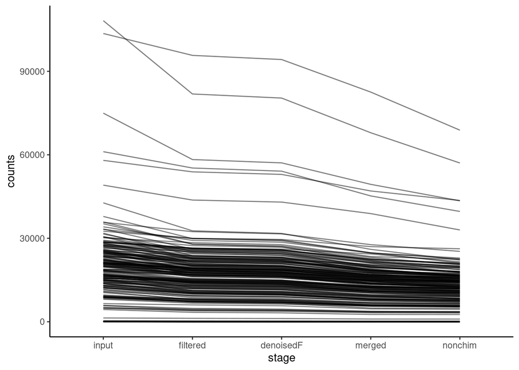

```r
track.df %>%
  select(-denoisedR) %>%
  pivot_longer(
  cols = c(input:nonchim),
  names_to = "stage",
  values_to = "counts"
)  %>%  mutate(stage=factor(stage, levels = c('input','filtered','denoisedF','merged','tabled','nonchim'))) -> track
# track$Label <- str_replace(track$Label, "X", "")
track %>% left_join(FullMeta.df, by = "Label")-> track.graph

track.graph$counts <- as.double(track.graph$counts)

track.graph %>%
  dplyr::filter(Sample_type == "Fecal") %>%
    ggplot(mapping=aes(x=stage, y=counts, by=Label, group = Label)) +
    geom_line(alpha=0.5) +
        theme_classic()
```

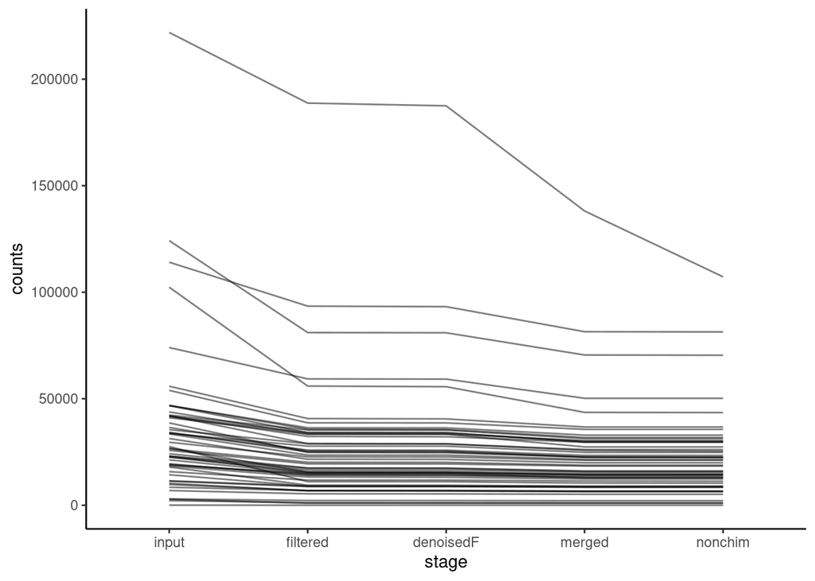

```r
track.graph %>%
  dplyr::filter(Sample_type == "Lung Tissue") %>%
    ggplot(mapping=aes(x=stage, y=counts, by=Label, group = Label)) +
    geom_line(alpha=0.5) +
        theme_classic()
```

The large number of reads belong to the positive control. It doesn’t look like we’re losing a ridiculous number of reads from the samples. The relatively low number of reads in some fecal samples is concerning.

## Assign taxonomy

For plotting purposes, having ASV numbers (ex. ASV1-ASV999) is easier, but it’s also useful to have the whole DNA sequences as the RefSeq object.

```r
taxa <- assignTaxonomy(seqtab.nochim, silva_v138.ref, multithread=TRUE)
# taxa <- addSpecies(taxa, silva_v138.species.ref) # identify species when possible
taxa.print <- taxa # Removing sequence rownames for display only
rownames(taxa.print) <- NULL
head(taxa.print)
```

```
##      Kingdom    Phylum             Class                 Order
## [1,] "Bacteria" "Actinobacteriota" "Actinobacteria"      "Corynebacteriales"
## [2,] "Bacteria" "Firmicutes"       "Bacilli"             "Lactobacillales"
## [3,] "Bacteria" "Firmicutes"       "Bacilli"             "Erysipelotrichales"
## [4,] "Bacteria" "Actinobacteriota" "Actinobacteria"      "Bifidobacteriales"
## [5,] "Bacteria" "Bacteroidota"     "Bacteroidia"         "Bacteroidales"
## [6,] "Bacteria" "Proteobacteria"   "Gammaproteobacteria" "Enterobacterales"
##      Family                Genus
## [1,] "Nocardiaceae"        "Rhodococcus"
## [2,] "Lactobacillaceae"    "Lactobacillus"
## [3,] "Erysipelotrichaceae" "Faecalibaculum"
## [4,] "Bifidobacteriaceae"  "Bifidobacterium"
## [5,] "Bacteroidaceae"      "Bacteroides"
## [6,] "Enterobacteriaceae"  "Escherichia-Shigella"
```

```r
FullMeta.df %>% column_to_rownames("Label") -> FullMeta.df # Change Label into rownames for passing off to phyloseq
FullMeta.df
```

```
##                        Cage-Mouse Genotype    Sex          Diet
## JI-661          1477831/1420961-2       WT Female High_Fat_Diet
## JI-662                  1420955-1       WT   Male High_Fat_Diet
## JI-665          1477806/1420956-3       WT Female High_Fat_Diet
## JI-669          1477824/1420956-4       WT Female High_Fat_Diet
## JI-671          1477826/1420952-2       KO Female High_Fat_Diet
## JI-674          1477828/1420952-1       KO Female High_Fat_Diet
## JI-675          1477827/1420952-3       KO Female High_Fat_Diet
## JI-681          1477818/1420960-2       WT Female High_Fat_Diet
## JI-682                  1420960-3       WT Female High_Fat_Diet
## JI-686          1477811/1420964-5       KO Female High_Fat_Diet
## JI-687          1477817/1467744-1       KO Female High_Fat_Diet
## JI-689          1477812/1420964-3       KO Female High_Fat_Diet
## JI-690                  1420962-2       WT   Male High_Fat_Diet
## JI-692          1477823/1468825-2       KO   Male High_Fat_Diet
```

[output cut: 1250 more lines]

```r
rownames(seqtab.nochim)
```

```
##   [1] "1"               "10"              "11"              "12"
##   [5] "13"              "14"              "15"              "16"
##   [9] "17"              "18"              "19"              "2"
##  [13] "20"              "201"             "202"             "203"
##  [17] "204"             "205"             "206"             "207"
##  [21] "208"             "209"             "21"              "210"
##  [25] "211"             "212"             "213"             "214"
##  [29] "215"             "216"             "217"             "218"
##  [33] "219"             "22"              "220"             "221"
##  [37] "222"             "223"             "224"             "225"
##  [41] "226"             "227"             "228"             "229"
##  [45] "23"              "230"             "231"             "232"
##  [49] "233"             "234"             "235"             "236"
##  [53] "237"             "238"             "239"             "24"
##  [57] "240"             "241"             "242"             "244"
```

[output cut: 56 more lines]

```r
all(rownames(seqtab.nochim) %in% rownames(FullMeta.df))
```

```
## [1] FALSE
```

## Save and export as phyloseq object

```r
otus = otu_table(seqtab.nochim, taxa_are_rows=FALSE)
sd = sample_data(FullMeta.df)
ps <- phyloseq(otus,
               sd,
               tax_table(taxa))
```

```r
dna <- Biostrings::DNAStringSet(taxa_names(ps))
names(dna) <- taxa_names(ps)
ps <- merge_phyloseq(ps, dna)
taxa_names(ps) <- paste0("ASV", seq(ntaxa(ps))) # Give taxa ASV names for easier graphing
ps
```

```
## phyloseq-class experiment-level object
## otu_table()   OTU Table:         [ 3178 taxa and 252 samples ]
## sample_data() Sample Data:       [ 252 samples by 22 sample variables ]
## tax_table()   Taxonomy Table:    [ 3178 taxa by 6 taxonomic ranks ]
## refseq()      DNAStringSet:      [ 3178 reference sequences ]
```

```r
ps@sam_data %>% head()
```

```
##           Cage.Mouse Genotype    Sex          Diet Intrasal_Treatment Surgery
## 1  1477830/1420961-3       WT Female High_Fat_Diet                HDM    Sham
## 10         1420950-2       WT Female High_Fat_Diet                HDM    None
## 11         1420965-1       KO   Male   Normal_Chow                HDM    None
## 12 1477826/1420952-2       KO Female High_Fat_Diet                HDM     VSG
## 13 1477812/1420964-3       KO Female High_Fat_Diet                PBS    Sham
## 14 1477828/1420952-1       KO Female High_Fat_Diet                PBS    Sham
##    Intrasal_Dose Cohort    Cage Week Lung_index  Kit  Mouse DNA_ng_ul_raw
## 1      50ug/40ul      1 1477830   13         NA PS_1 JI-670          55.5
## 10     50ug/40ul      1 1420950   10         NA PS_1 JI-654          79.7
## 11     50ug/40ul      1 1420965   10         NA PS_1 JI-659         116.0
## 12     50ug/40ul      1 1477826   13         NA PS_1 JI-671          22.8
## 13          40ul      1 1477812   13         NA PS_1 JI-689          31.0
## 14          40ul      1 1477828   13         NA PS_1 JI-674          31.0
##    Sequencing_Run        Type Sample_type Sample_Label Cage_Notation
## 1               2 True Sample       Fecal    JI-670-13          <NA>
## 10              2 True Sample       Fecal    JI-654-10          <NA>
## 11              2 True Sample       Fecal    JI-659-10          <NA>
## 12              2 True Sample       Fecal    JI-671-13          <NA>
## 13              2 True Sample       Fecal    JI-689-13          <NA>
## 14              2 True Sample       Fecal    JI-674-13          <NA>
##    Feces_weight Orig_label Notes
## 1          57.0       <NA>  <NA>
## 10         28.5       <NA>  <NA>
## 11         64.5       <NA>  <NA>
## 12         19.0       <NA>  <NA>
## 13         41.0       <NA>  <NA>
## 14         31.5       <NA>  <NA>
```

```r
ps@tax_table %>% head()
```

```
## Taxonomy Table:     [6 taxa by 6 taxonomic ranks]:
##      Kingdom    Phylum             Class                 Order
## ASV1 "Bacteria" "Actinobacteriota" "Actinobacteria"      "Corynebacteriales"
## ASV2 "Bacteria" "Firmicutes"       "Bacilli"             "Lactobacillales"
## ASV3 "Bacteria" "Firmicutes"       "Bacilli"             "Erysipelotrichales"
## ASV4 "Bacteria" "Actinobacteriota" "Actinobacteria"      "Bifidobacteriales"
## ASV5 "Bacteria" "Bacteroidota"     "Bacteroidia"         "Bacteroidales"
## ASV6 "Bacteria" "Proteobacteria"   "Gammaproteobacteria" "Enterobacterales"
##      Family                Genus
## ASV1 "Nocardiaceae"        "Rhodococcus"
## ASV2 "Lactobacillaceae"    "Lactobacillus"
## ASV3 "Erysipelotrichaceae" "Faecalibaculum"
## ASV4 "Bifidobacteriaceae"  "Bifidobacterium"
## ASV5 "Bacteroidaceae"      "Bacteroides"
## ASV6 "Enterobacteriaceae"  "Escherichia-Shigella"
```

```r
ps.rds = file.path(git.dir, paste0("GLP_KO_Microbiome_2023.rds"))
write_rds(ps, ps.rds)
loaded.ps = read_rds(ps.rds)
print(loaded.ps)
```

```
## phyloseq-class experiment-level object
## otu_table()   OTU Table:         [ 3178 taxa and 252 samples ]
## sample_data() Sample Data:       [ 252 samples by 22 sample variables ]
## tax_table()   Taxonomy Table:    [ 3178 taxa by 6 taxonomic ranks ]
## refseq()      DNAStringSet:      [ 3178 reference sequences ]
```

The phyloseq object was written and saved correctly.